# Compensatory Renal Hypertrophy : RNA-seq Analysis

Vincent Wong

13 July, 2021

# Setup

First we load all the required `R` packages

```r
library(tidyverse)
library(magrittr)
library(cowplot)
library(edgeR)
library(RUVSeq)
library(AnnotationHub)
library(ensembldb)
library(scales)
library(kableExtra)
library(pander)
library(ggrepel)
library(pheatmap)
library(RColorBrewer)
library(goseq)
library(msigdbr)
library(AnnotationDbi)
library(clusterProfiler)
library(org.Mm.eg.db)
```

## Annotations

```r
ah <- AnnotationHub() %>%
    subset(species == "Mus musculus") %>%
    subset(dataprovider == "Ensembl") %>%
    subset(genome == "GRCm39") %>% # GRCm39 is relative new release 104 is not out yet
    subset(rdataclass == "EnsDb")
ensDb <- ah[["AH89457"]]
```

```r
grTrans <- transcripts(ensDb)
trLengths <- exonsBy(ensDb, "tx") %>%
  width() %>%
  vapply(sum, integer(1))
mcols(grTrans)$length <- trLengths[names(grTrans)]
```

Similarly to the Quality Assessment steps, `GRanges` objects were formed at the gene and transcript levels, to enable estimation of GC content and length for each transcript and gene. GC content and transcript length are available for each transcript, and for gene-level estimates, GC content was taken as the sum of all GC bases divided by the sum of all transcript lengths, effectively averaging across all transcripts. Gene length was defined as the median transcript length.

```r
gcGene <- grTrans %>%
  mcols() %>%
  as.data.frame() %>%
  dplyr::select(gene_id, tx_id, gc_content, length, tx_name) %>%
  as_tibble() %>%
  group_by(gene_id) %>%
  summarise(
    gc_content = sum(gc_content*length) / sum(length),
    length = ceiling(median(length)),)

grGenes <- genes(ensDb)
mcols(grGenes) %<>%
  as.data.frame() %>%
  left_join(gcGene) %>%
  as.data.frame() %>%
  DataFrame()
```

Sample metadata was also loaded

```r
setwd("C:/Users/cronos/Box Sync/Desktop/Renal Hypertrophy/CRH_RNAseq")

samples <- read_csv("samples.csv") %>%
  distinct(sampleName, .keep_all = TRUE) %>%
  dplyr::select(sample = sampleName,time= timepoint, everything()) %>%
  mutate(
    treatment = factor(treatment, levels = c("Sham", "Unx")),
    time = factor(time, levels=c("24hr","48hr","72hr")),
    group = factor(group,
                       levels=c("Sham.24hr", "Sham.48hr", "Sham.72hr",
                                "Unx.24hr", "Unx.48hr", "Unx.72hr")))
groupCols <- samples$group %>%
  levels() %>%
  length() %>%
  brewer.pal("Dark2") %>%
  setNames(levels(samples$group))

timeCols <- samples$time %>%
  levels() %>%
  length() %>%
  brewer.pal("Set2") %>%
  setNames(levels(samples$time))

treatCols <- samples$treatment %>%
  levels() %>%
  length() %>%
  brewer.pal("Set1") %>%
  setNames(levels(samples$treatment)) %>%
  .[-3]

samples %>%
  kable %>%
  kable_styling() %>%
  scroll_box(height="700px")
```

| sample | time | group | treatment | mouseID | label | batch | gender |
| --- | --- | --- | --- | --- | --- | --- | --- |
| RNASeq-29 | 24hr | Unx.24hr | Unx | 29 | 29-Unx-24hr | 1 | male |
| RNASeq-30 | 24hr | Unx.24hr | Unx | 30 | 30-Unx-24hr | 1 | male |
| RNASeq-31 | 24hr | Unx.24hr | Unx | 31 | 31-Unx-24hr | 1 | male |
| RNASeq-32 | 24hr | Unx.24hr | Unx | 32 | 32-Unx-24hr | 1 | male |
| RNASeq-33 | 24hr | Unx.24hr | Unx | 33 | 33-Unx-24hr | 1 | male |
| RNASeq-34 | 24hr | Unx.24hr | Unx | 34 | 34-Unx-24hr | 1 | male |
| RNASeq-35 | 24hr | Sham.24hr | Sham | 35 | 35-Sham-24hr | 1 | male |
| RNASeq-36 | 24hr | Sham.24hr | Sham | 36 | 36-Sham-24hr | 1 | male |
| RNASeq-37 | 24hr | Sham.24hr | Sham | 37 | 37-Sham-24hr | 1 | male |
| RNASeq-38 | 24hr | Sham.24hr | Sham | 38 | 38-Sham-24hr | 1 | male |
| RNASeq-39 | 24hr | Sham.24hr | Sham | 39 | 39-Sham-24hr | 1 | male |
| RNASeq-40 | 24hr | Sham.24hr | Sham | 40 | 40-Sham-24hr | 1 | male |
| RNASeq-1 | 48hr | Unx.48hr | Unx | 5 | 5-UNX-48hr | 2 | male |
| RNASeq-2 | 48hr | Unx.48hr | Unx | 6 | 6-UNX-48hr | 2 | male |
| RNASeq-3 | 48hr | Unx.48hr | Unx | 7 | 7-UNX-48hr | 2 | male |
| RNASeq-4 | 48hr | Unx.48hr | Unx | 8 | 8-UNX-48hr | 2 | male |
| RNASeq-5 | 48hr | Unx.48hr | Unx | 11 | 11-UNX-48hr | 2 | male |
| RNASeq-6 | 48hr | Unx.48hr | Unx | 15 | 15-UNX-48hr | 2 | male |
| RNASeq-7 | 48hr | Sham.48hr | Sham | 12 | 12-Sham-48hr | 2 | male |
| RNASeq-8 | 48hr | Sham.48hr | Sham | 13 | 13-Sham-48hr | 2 | male |
| RNASeq-9 | 48hr | Sham.48hr | Sham | 14 | 14-Sham-48hr | 2 | male |
| RNASeq-10 | 48hr | Sham.48hr | Sham | 16 | 16-Sham-48hr | 2 | male |
| RNASeq-11 | 48hr | Sham.48hr | Sham | 63 | 63-Sham-48hr | 2 | male |
| RNASeq-12 | 48hr | Sham.48hr | Sham | 64 | 64-Sham-48hr | 2 | male |
| RNASeq-13 | 72hr | Unx.72hr | Unx | 17 | 17-UNX-72hr | 2 | male |
| RNASeq-14 | 72hr | Unx.72hr | Unx | 18 | 18-UNX-72hr | 2 | male |
| RNASeq-15 | 72hr | Unx.72hr | Unx | 19 | 19-UNX-72hr | 2 | male |
| RNASeq-16 | 72hr | Unx.72hr | Unx | 20 | 20-UNX-72hr | 2 | male |
| RNASeq-17 | 72hr | Unx.72hr | Unx | 21 | 21-UNX-72hr | 2 | male |
| RNASeq-18 | 72hr | Unx.72hr | Unx | 22 | 22-UNX-72hr | 2 | male |
| RNASeq-19 | 72hr | Sham.72hr | Sham | 23 | 23-Sham-72hr | 2 | male |
| RNASeq-20 | 72hr | Sham.72hr | Sham | 24 | 24-Sham-72hr | 2 | male |
| RNASeq-21 | 72hr | Sham.72hr | Sham | 25 | 25-Sham-72hr | 2 | male |
| RNASeq-22 | 72hr | Sham.72hr | Sham | 26 | 26-Sham-72hr | 2 | male |
| RNASeq-23 | 72hr | Sham.72hr | Sham | 27 | 27-Sham-72hr | 2 | male |
| RNASeq-24 | 72hr | Sham.72hr | Sham | 28 | 28-Sham-72hr | 2 | male |

## Count Data

Load the transcript-level counts

```r
transCounts <- list.files("C:/Users/cronos/Box Sync/Desktop/Renal Hypertrophy/CRH_RNAseq/3_salmon_110621",
                          full.names = TRUE) %>%
  catchSalmon()
colnames(transCounts$counts) %<>%
    basename()
libSizes <- colSums(transCounts$counts)
```

```r
minCPM <- 1
minSamples <- 6

dgeList <- transCounts$counts %>%
    as.data.frame() %>%
    rownames_to_column("tx_id_version") %>%
    gather(key = "sample", value = "Count", -tx_id_version) %>%
    dplyr::filter(Count > 0) %>%
    left_join(grTrans[,c("tx_id_version", "gene_id")] %>%
                mcols() %>%
                as.data.frame()) %>%
    group_by(gene_id, sample) %>%
    summarise(Count = sum(Count)) %>%
  dplyr::filter(!is.na(gene_id)) %>%
    spread(sample, Count, fill = 0) %>%
    as.data.frame() %>%
    column_to_rownames("gene_id")%>%
  .[rowSums(cpm(.) >= minCPM) >= minSamples,] %>%
  DGEList(
    samples = tibble(sample = colnames(.)) %>%
      left_join(samples),
    genes = grGenes[rownames(.)] %>%
      as.data.frame() %>%
      dplyr::select(
        chromosome = seqnames, start, end,
        gene_id, gene_name, gene_biotype, description,
        entrezid, gc_content, length)) %>%
  .[!grepl("rRNA", .$genes$gene_biotype),] %>%
  .[!grepl("lncRNA", .$genes$gene_biotype),] %>%
  .[!grepl("pseudogene", .$genes$gene_biotype),] %>%
  calcNormFactors()
```

Gene-level count data as output by `salmon`, was loaded and formed into a `DGEList` object. During this process, genes were removed if:

These filtering steps returned Gene-level counts for 13,158 genes, with total library sizes between *14,853,597* and *24,086,868* reads assigned to genes. It was noted that these library sizes were about 1.5-fold larger than the transcript-level counts used for the QA steps.

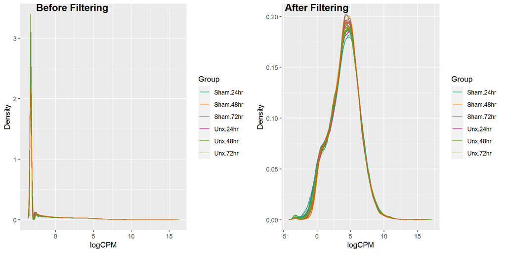

*Expression density plots for all samples after filtering, showing logCPM values.*

```r
## Compare the density distributions before and after filtering
BeforeFilt <- transCounts$counts %>%
cpm(log = TRUE) %>%
  as.data.frame() %>%
  pivot_longer(
    cols = everything(),
    names_to = "sample",
    values_to = "logCPM") %>%
  split(f = .$sample) %>%
  lapply(function(x){
    d <- density(x$logCPM)
    tibble(sample = unique(x$sample),
           x = d$x,y = d$y)}) %>%
  bind_rows() %>%
  left_join(samples) %>%
  ggplot(aes(x, y, colour = group, group = sample)) +
  geom_line() +
  scale_colour_manual(values = groupCols) +
  labs(x = "logCPM", y = "Density", colour = "Group")

AfterFilt<-dgeList %>%
cpm(log = TRUE) %>%
  as.data.frame() %>%
  pivot_longer(
    cols = everything(),
    names_to = "sample",
    values_to = "logCPM") %>%
  split(f = .$sample) %>%
  lapply(function(x){
    d <- density(x$logCPM)
    tibble(sample = unique(x$sample),
           x = d$x,y = d$y)}) %>%
  bind_rows() %>%
  left_join(samples) %>%
  ggplot(aes(x, y, colour = group, group = sample)) +
  geom_line() +
  scale_colour_manual(values = groupCols) +
  labs(x = "logCPM", y = "Density", colour = "Group")


plot_grid(BeforeFilt, AfterFilt, labels = c("Before Filtering","After Filtering"))
```

Initial library sizes were between *14,868,665* and *24,108,914* This dataset retained 13,158 genes for DGE analysis.

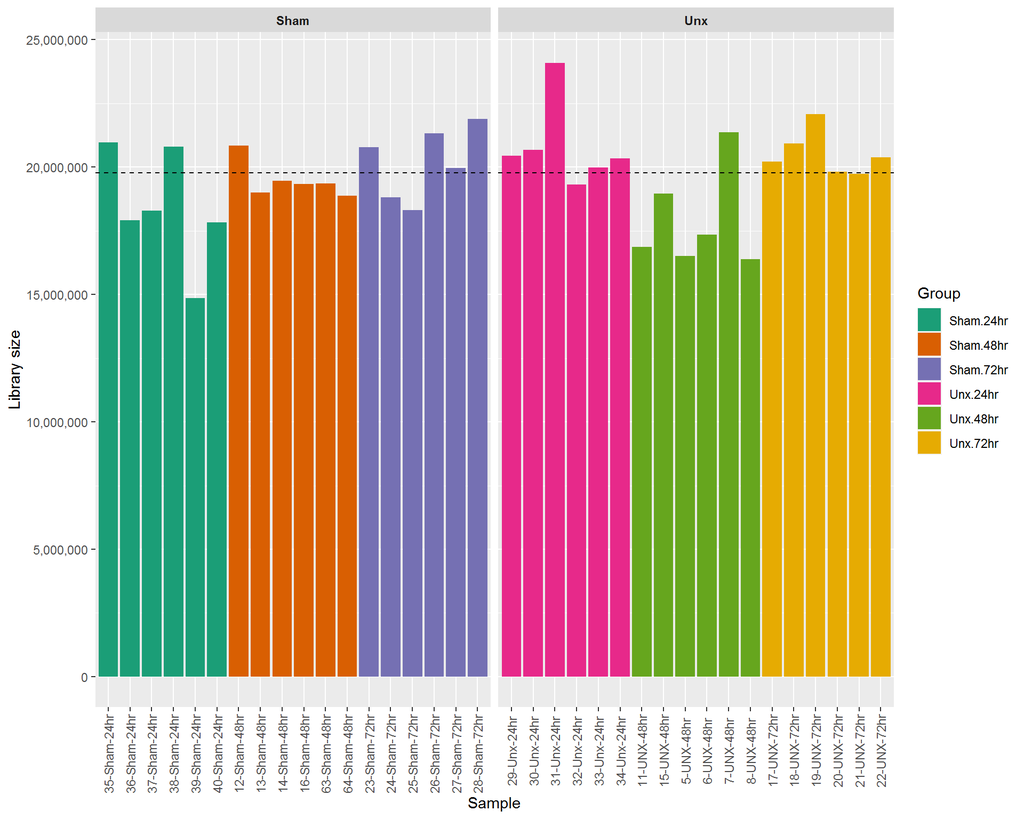

*Library Sizes after removal of undetectable genes and summarising to gene-level counts. Median library size is shown as the dashed line.*

### Additional Functions

```r
# contLabeller <- as_labeller(
#   c(KOVsWT = "-/- Vs +/+",
#     KO = "-/-",
#     WT = "+/+"))

contLabeller <- as_labeller(
  c(KO = "Sham Vs Unx"))

geneLabeller <- structure(grGenes$gene_name, names = grGenes$gene_id) %>%
  as_labeller()
```

Labeller functions for genotypes, contrasts and gene names were additionally defined for simpler plotting using `ggplot2`.

# Analysis

## Initial MDS

MDS: Project a multi-dimensional space preserving the inter-point distances

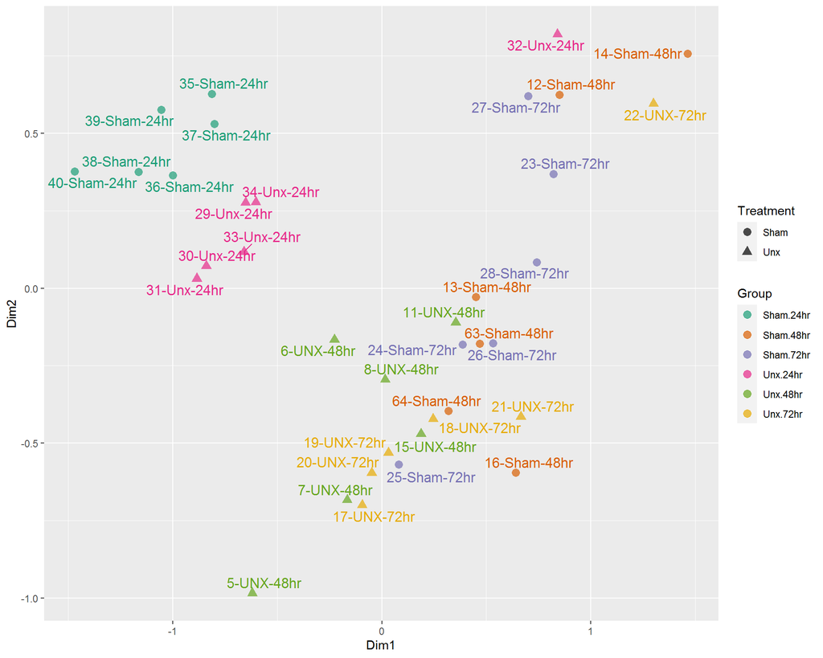

```r
dgeList %>%
    plotMDS(plot = FALSE, labels=colnames(dgeList)) %>%
    .[c("x", "y")] %>%
    as.data.frame() %>%
    set_rownames(colnames(dgeList)) %>%
  rownames_to_column("sample") %>%
    left_join(dgeList$samples) %>%
    ggplot(aes(x, y, colour = group)) +
    geom_point(aes(shape=as.factor(treatment)),alpha = 0.7, size = 3) +
    geom_text_repel(aes(label = label), size=4.4, show.legend = FALSE) +
      scale_colour_manual(values = groupCols)+
    labs(x = "Dim1", y = "Dim2",
         colour = "Group", shape = "Treatment")
```

## Initial PCA

PCA: Project a multi-dimensional space onto the directions of maximum variability

```r
pca <- dgeList %>%
  cpm(log = TRUE) %>%
  t() %>%
  prcomp()
pcaVars <- percent_format(0.1)(summary(pca)$importance["Proportion of Variance",])
```

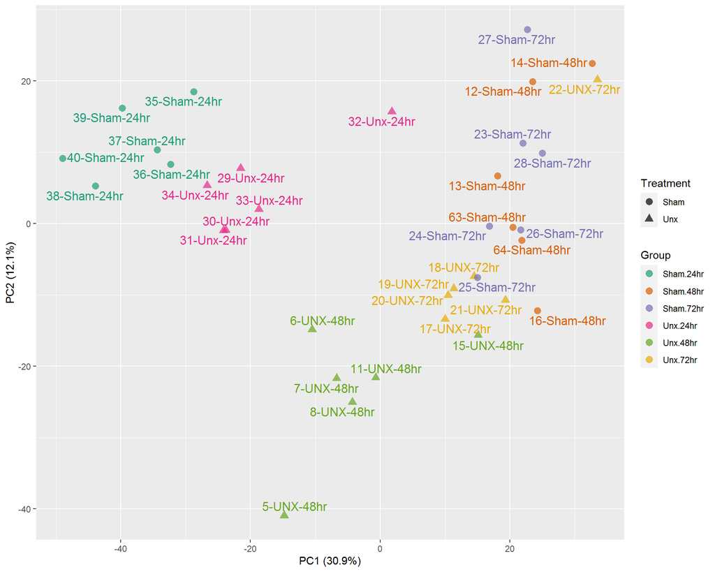

*PCA 1 & 2 of gene-level counts.*

```r
pca$x %>%
  as.data.frame() %>%
  rownames_to_column("sample") %>%
  as_tibble() %>%
  dplyr::select(sample, PC1, PC2) %>%
  left_join(dgeList$samples,"sample") %>%
  ggplot(aes(x=PC1, y=PC2, colour = group)) +
  geom_point(aes(shape=as.factor(treatment)),alpha = 0.7, size = 3) +
  geom_text_repel(aes(label = label), size=4.4, show.legend = FALSE) +
  # stat_ellipse(geom = "polygon", alpha = 0.1, show.legend = FALSE, aes(fill=group)) +
  #scale_shape_manual(values=c(15,11,19,17))+ #change shape
  scale_colour_manual(
    values = groupCols) +
  labs(
    x = paste0("PC1 (", pcaVars[["PC1"]], ")"),
    y = paste0("PC2 (", pcaVars[["PC2"]], ")"),
    colour = "Group",
    shape = "Treatment")
```

```r
options(ggrepel.max.overlaps = Inf)

pca12 <-pca$x %>%
  as.data.frame() %>%
  rownames_to_column("sample") %>%
  as_tibble() %>%
  dplyr::select(sample, PC1, PC2) %>%
  left_join(dgeList$samples,"sample") %>%
  ggplot(aes(x=PC1, y=PC2, colour = group)) +
  geom_point(aes(shape=as.factor(treatment)),alpha = 0.7, size = 3) +
  geom_text_repel(aes(label = label), size=3.5, show.legend = FALSE) +
  # stat_ellipse(geom = "polygon", alpha = 0.1, show.legend = FALSE, aes(fill=group)) +
  #scale_shape_manual(values=c(15,11,19,17))+ #change shape
  scale_colour_manual(
    values = groupCols) +
  labs(
    x = paste0("PC1 (", pcaVars[["PC1"]], ")"),
    y = paste0("PC2 (", pcaVars[["PC2"]], ")"),
    colour = "Group",
    shape = "Treatment") + theme(legend.position = c(1.2,0.5))
pca23 <-pca$x %>%
  as.data.frame() %>%
  rownames_to_column("sample") %>%
  as_tibble() %>%
  dplyr::select(sample, PC2, PC3) %>%
  left_join(dgeList$samples,"sample") %>%
  ggplot(aes(x=PC2, y=PC3, colour = group)) +
  geom_point(aes(shape=as.factor(treatment)),alpha = 0.7, size = 3) +
  geom_text_repel(aes(label = label), size=3.5, show.legend = FALSE) +
  # stat_ellipse(geom = "polygon", alpha = 0.1, show.legend = FALSE, aes(fill=group)) +
  #scale_shape_manual(values=c(15,11,19,17))+ #change shape
  scale_colour_manual(
    values = groupCols) +
  labs(
    x = paste0("PC2 (", pcaVars[["PC2"]], ")"),
    y = paste0("PC3 (", pcaVars[["PC3"]], ")"),
    colour = "Group",
    shape = "Treatment") + theme(legend.position = "none")
pca34 <-pca$x %>%
  as.data.frame() %>%
  rownames_to_column("sample") %>%
  as_tibble() %>%
  dplyr::select(sample, PC3, PC4) %>%
  left_join(dgeList$samples,"sample") %>%
  ggplot(aes(x=PC3, y=PC4, colour = group)) +
  geom_point(aes(shape=as.factor(treatment)),alpha = 0.7, size = 3) +
  geom_text_repel(aes(label = label), size=3.5, show.legend = FALSE) +
  # stat_ellipse(geom = "polygon", alpha = 0.1, show.legend = FALSE, aes(fill=group)) +
  #scale_shape_manual(values=c(15,11,19,17))+ #change shape
  scale_colour_manual(
    values = groupCols) +
  labs(
    x = paste0("PC3 (", pcaVars[["PC3"]], ")"),
    y = paste0("PC4 (", pcaVars[["PC4"]], ")"),
    colour = "Group",
    shape = "Treatment") +  theme(legend.position = "none")
```

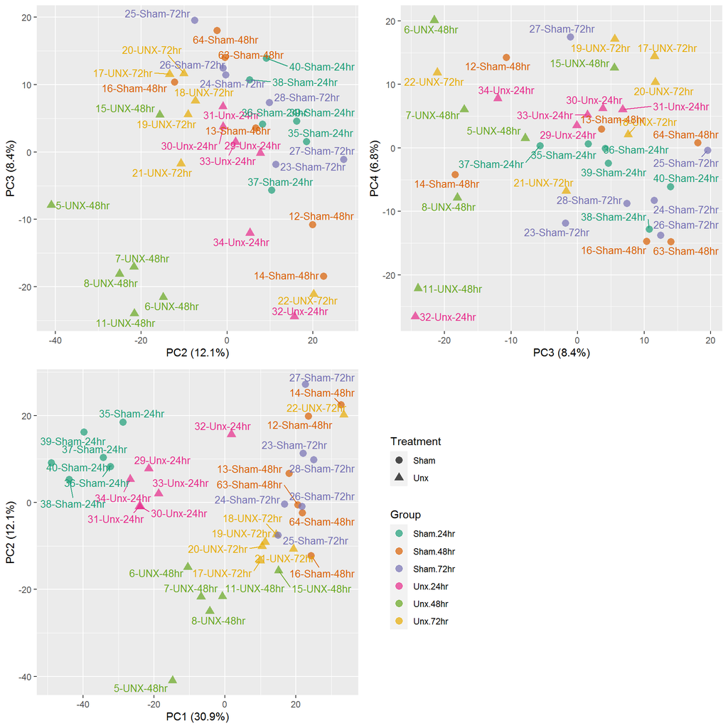

```r
library(grid)
vp1 <- viewport(x = 0.25, y = 0.25, width = 0.5, height = 0.5)
vp2 <- viewport(x = 0.25, y = 0.75, width = 0.5, height = 0.5)
vp3 <- viewport(x = 0.75, y = 0.75, width = 0.5, height = 0.5)
# Plot PCA plots in grid
if (interactive()) grid::grid.newpage()
print(pca12, vp = vp1)
print(pca23, vp = vp2)
print(pca34, vp = vp3)
```

A Principal Component Analysis (PCA) was performed using logCPM values from each sample. Samples appears to cluster together based on time point but with exception of several 48hrs samples.

## Sample Correlation Plot

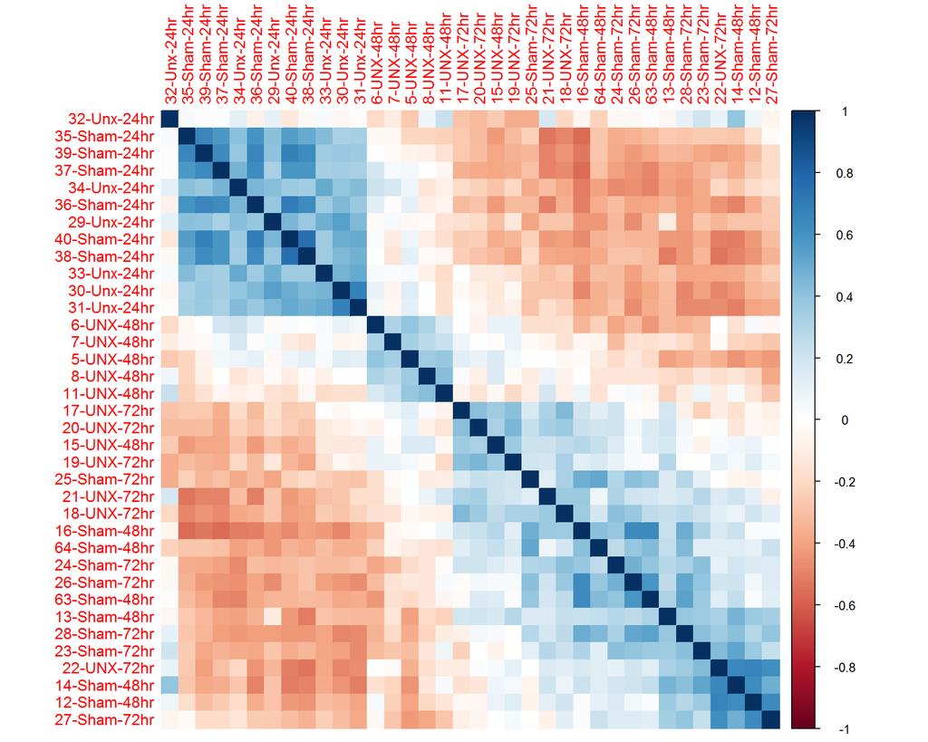

```r
library(corrplot)

pca$x %>% set_rownames(dgeList$samples$label) %>%
  t() %>%
  as.data.frame() %>%
  cor() %>%
  # .[1:20,1:20] %>%
    corrplot(method = "color", order="AOE")
```

## Differential Gene Expression

### Creating a design matrix and contrasts

```r
design <- model.matrix(~0+group, data=dgeList$samples)%>%
  set_colnames(str_remove(colnames(.), "group"))
design %>%
  kable %>%
  kable_styling() %>%
  scroll_box(height="300px")
```

|  | Sham.24hr | Sham.48hr | Sham.72hr | Unx.24hr | Unx.48hr | Unx.72hr |
| --- | --- | --- | --- | --- | --- | --- |
| RNASeq-1 | 0 | 0 | 0 | 0 | 1 | 0 |
| RNASeq-10 | 0 | 1 | 0 | 0 | 0 | 0 |
| RNASeq-11 | 0 | 1 | 0 | 0 | 0 | 0 |
| RNASeq-12 | 0 | 1 | 0 | 0 | 0 | 0 |
| RNASeq-13 | 0 | 0 | 0 | 0 | 0 | 1 |
| RNASeq-14 | 0 | 0 | 0 | 0 | 0 | 1 |
| RNASeq-15 | 0 | 0 | 0 | 0 | 0 | 1 |
| RNASeq-16 | 0 | 0 | 0 | 0 | 0 | 1 |
| RNASeq-17 | 0 | 0 | 0 | 0 | 0 | 1 |
| RNASeq-18 | 0 | 0 | 0 | 0 | 0 | 1 |
| RNASeq-19 | 0 | 0 | 1 | 0 | 0 | 0 |
| RNASeq-2 | 0 | 0 | 0 | 0 | 1 | 0 |
| RNASeq-20 | 0 | 0 | 1 | 0 | 0 | 0 |
| RNASeq-21 | 0 | 0 | 1 | 0 | 0 | 0 |
| RNASeq-22 | 0 | 0 | 1 | 0 | 0 | 0 |
| RNASeq-23 | 0 | 0 | 1 | 0 | 0 | 0 |
| RNASeq-24 | 0 | 0 | 1 | 0 | 0 | 0 |
| RNASeq-29 | 0 | 0 | 0 | 1 | 0 | 0 |
| RNASeq-3 | 0 | 0 | 0 | 0 | 1 | 0 |
| RNASeq-30 | 0 | 0 | 0 | 1 | 0 | 0 |
| RNASeq-31 | 0 | 0 | 0 | 1 | 0 | 0 |
| RNASeq-32 | 0 | 0 | 0 | 1 | 0 | 0 |
| RNASeq-33 | 0 | 0 | 0 | 1 | 0 | 0 |
| RNASeq-34 | 0 | 0 | 0 | 1 | 0 | 0 |
| RNASeq-35 | 1 | 0 | 0 | 0 | 0 | 0 |
| RNASeq-36 | 1 | 0 | 0 | 0 | 0 | 0 |
| RNASeq-37 | 1 | 0 | 0 | 0 | 0 | 0 |
| RNASeq-38 | 1 | 0 | 0 | 0 | 0 | 0 |
| RNASeq-39 | 1 | 0 | 0 | 0 | 0 | 0 |
| RNASeq-4 | 0 | 0 | 0 | 0 | 1 | 0 |
| RNASeq-40 | 1 | 0 | 0 | 0 | 0 | 0 |
| RNASeq-5 | 0 | 0 | 0 | 0 | 1 | 0 |
| RNASeq-6 | 0 | 0 | 0 | 0 | 1 | 0 |
| RNASeq-7 | 0 | 1 | 0 | 0 | 0 | 0 |
| RNASeq-8 | 0 | 1 | 0 | 0 | 0 | 0 |
| RNASeq-9 | 0 | 1 | 0 | 0 | 0 | 0 |

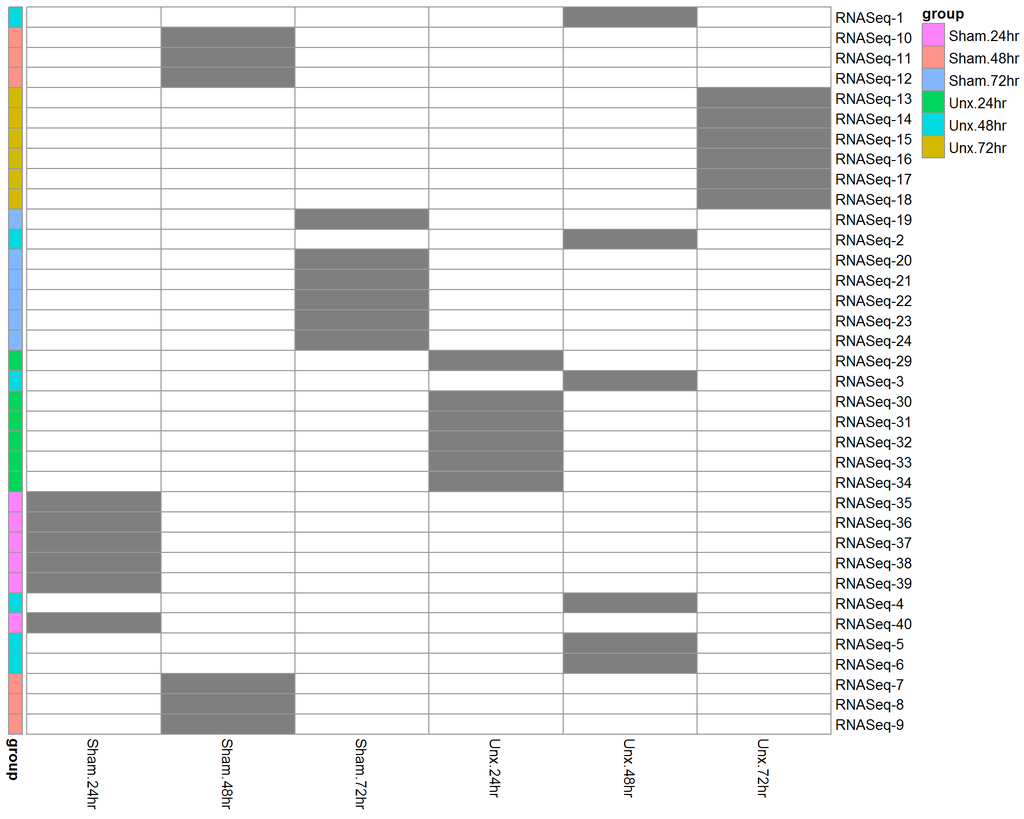

```r
pheatmap(
  design,
  cluster_cols = FALSE,
  cluster_rows = FALSE,
  color = c("white", "grey50"),
  annotation_row = dgeList$samples["group"],
  annotation_colors = list(condition = groupCols),
  legend = FALSE
)
```

```r
contr.matrix <- makeContrasts(
   Sham24vsUnx24 = Unx.24hr-Sham.24hr,
   Sham48vsUnx48 = Unx.48hr-Sham.48hr,
   Sham72vsUnx72 = Unx.72hr-Sham.72hr,
   ShamvsUnx = (Unx.24hr+Unx.72hr+Unx.48hr)-(Sham.24hr+Sham.48hr+Sham.72hr),
   Unx24vsUnx48 = Unx.48hr-Unx.24hr,
   Unx24vsUnx72 = Unx.72hr-Unx.24hr,
   Unx48vsUnx72 = Unx.72hr-Unx.48hr,
   Sham24vsSham48 = Sham.48hr-Sham.24hr,
   Sham24vsSham72 = Sham.72hr-Sham.24hr,
   Sham48vsSham72 = Sham.72hr-Sham.48hr,
   t24vst48 = (Sham.48hr+Unx.48hr)-(Unx.24hr+Sham.24hr),
   t24vst72 = (Unx.72hr+Sham.72hr)-(Unx.24hr+Sham.24hr),
   t48vst72 = (Unx.72hr+Sham.72hr)-(Unx.48hr+Sham.48hr),
   ShamvsUnx24 = (Unx.24hr)-(Sham.24hr+Sham.72hr+Sham.48hr),
   ShamvsUnx48 = (Unx.48hr)-(Sham.24hr+Sham.72hr+Sham.48hr),
   ShamvsUnx72 = (Unx.72hr)-(Sham.24hr+Sham.72hr+Sham.48hr),
   levels = colnames(design))
contr.matrix
```

```
##            Contrasts
## Levels      Sham24vsUnx24 Sham48vsUnx48 Sham72vsUnx72 ShamvsUnx Unx24vsUnx48
##   Sham.24hr            -1             0             0        -1            0
##   Sham.48hr             0            -1             0        -1            0
##   Sham.72hr             0             0            -1        -1            0
##   Unx.24hr              1             0             0         1           -1
##   Unx.48hr              0             1             0         1            1
##   Unx.72hr              0             0             1         1            0
##            Contrasts
## Levels      Unx24vsUnx72 Unx48vsUnx72 Sham24vsSham48 Sham24vsSham72
##   Sham.24hr            0            0             -1             -1
##   Sham.48hr            0            0              1              0
##   Sham.72hr            0            0              0              1
##   Unx.24hr            -1            0              0              0
##   Unx.48hr             0           -1              0              0
##   Unx.72hr             1            1              0              0
##            Contrasts
## Levels      Sham48vsSham72 t24vst48 t24vst72 t48vst72 ShamvsUnx24 ShamvsUnx48
##   Sham.24hr              0       -1       -1        0          -1          -1
##   Sham.48hr             -1        1        0       -1          -1          -1
##   Sham.72hr              1        0        1        1          -1          -1
##   Unx.24hr               0       -1       -1        0           1           0
##   Unx.48hr               0        1        0       -1           0           1
##   Unx.72hr               0        0        1        1           0           0
##            Contrasts
## Levels      ShamvsUnx72
##   Sham.24hr          -1
##   Sham.48hr          -1
##   Sham.72hr          -1
##   Unx.24hr            0
##   Unx.48hr            0
##   Unx.72hr            1
```

### Estimation of sample weights

The approach taken for DGE analysis was to use voom-precision weights in order to allow for modelling using Normally distributed data. Sample-level weights were estimated as part of this process, with all samples normally being considered as belonging to the same treatment group, to allow more conservative estimates.

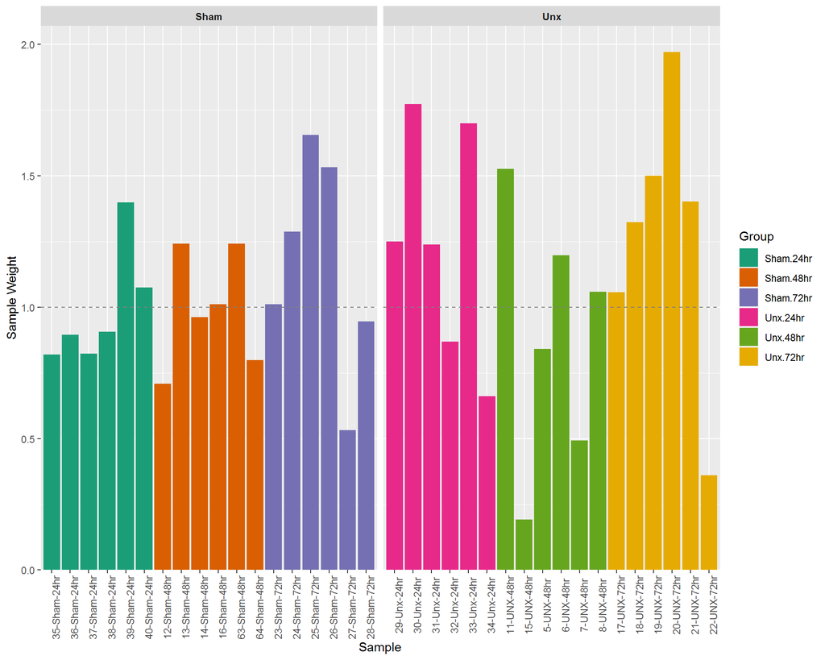

*Sample weights after voom transformation. The idealised equal weighting of $w = 1$ is shown as the dashed line.*

```r
v <- voomWithQualityWeights(dgeList, design, plot=FALSE)
```

Means (x-axis) and variances (y-axis) of each gene are plotted to show the dependence between the two before voom is applied to the data (left panel) and how the trend is removed after voom precision weights are applied to the data (right panel)

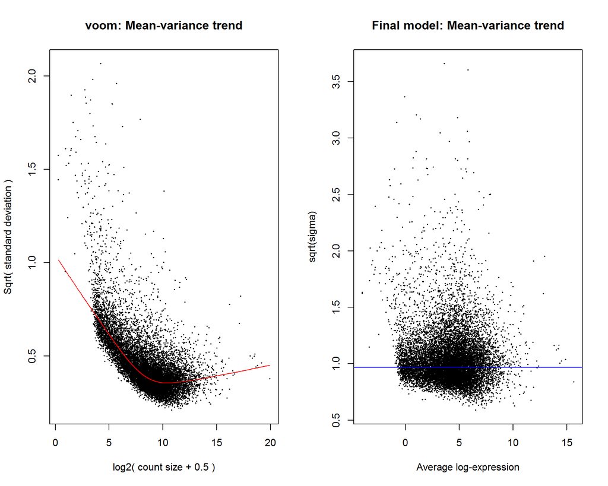

```r
par(mfrow=c(1,2))
v2 <- voom(dgeList, design, plot=TRUE)
v2fit <-lmFit(v2, design)
e2fit <-eBayes(v2fit)
plotSA(e2fit, main="Final model: Mean-variance trend")
```

### Strict Comparison between groups

```r
tau <- log2(1.1)
```

For the comparison between groups, a null hypothesis was tested using a range of values, instead of the point value zero, i.e.

$$H_0: -\tau < \Delta \mu < \tau \\
Vs. \\
H_A: | \Delta \mu | > \tau$$

The default value used in the function `treat()` is $\tau = \log_2 1.2$ and for this analysis, $\tau = \log_2 1.1$ was chosen as a suitable value.

```r
alpha <- 0.05

tfit <- lmFit(v,design) %>%
  contrasts.fit(contr.matrix) %>%
  treat(lfc = tau)
```

```r
summary(decideTests(tfit))
```

```
##        Sham24vsUnx24 Sham48vsUnx48 Sham72vsUnx72 ShamvsUnx Unx24vsUnx48
## Down             697          1767            47      1706         1224
## NotSig         11733          9569         13004      9527        10514
## Up               728          1822           107      1925         1420
##        Unx24vsUnx72 Unx48vsUnx72 Sham24vsSham48 Sham24vsSham72 Sham48vsSham72
## Down           1378         1443           2566           2526              0
## NotSig        10205        10296           7634           7699          13158
## Up             1575         1419           2958           2933              0
##        t24vst48 t24vst72 t48vst72 ShamvsUnx24 ShamvsUnx48 ShamvsUnx72
## Down       2834     3288      985       12321       12276       12252
## NotSig     7254     5961    11257         693         680         687
## Up         3070     3909      916         144         202         219
```

```r
topTables <- colnames(contr.matrix) %>%
  sapply(function(x){
  topTreat(tfit, coef = x, n = Inf) %>%
      as_tibble() %>%
      rownames_to_column("No.") %>%
      arrange(P.Value) %>%
      mutate(DE= adj.P.Val < alpha,
             Status = case_when(
      DE ==TRUE & logFC < 0 ~ "Down",
      DE == TRUE & logFC > 0 ~ "Up"),
      Status = ifelse(is.na(Status), "NotSig", Status))}, simplify = FALSE)
```

### Top 50 DE list

```r
topTables[[1]] %>%
      head(n=50) %>%
      dplyr::select(-chromosome, -start, -end, -description, -gc_content, -length) %>%
    kable %>%
  kable_styling() %>%
  scroll_box(height="700px")
```

| No. | gene_id | gene_name | gene_biotype | entrezid | logFC | AveExpr | t | P.Value | adj.P.Val | DE | Status |
| --- | --- | --- | --- | --- | --- | --- | --- | --- | --- | --- | --- |
| 1 | ENSMUSG00000001289 | Pfdn5 | protein_coding | 56612 | -0.9410393 | 6.693681 | -9.884152 | 0 | 1.0e-07 | TRUE | Down |
| 2 | ENSMUSG00000001175 | Calm1 | protein_coding | 12313 | 0.5446541 | 7.363734 | 9.484599 | 0 | 1.0e-07 | TRUE | Up |
| 3 | ENSMUSG00000026675 | Hsd17b7 | protein_coding | 15490 | 0.8522966 | 4.734742 | 9.198894 | 0 | 2.0e-07 | TRUE | Up |
| 4 | ENSMUSG00000071655 | Ubxn1 | protein_coding | 225896 | -0.7628731 | 6.633195 | -8.883924 | 0 | 3.0e-07 | TRUE | Down |
| 5 | ENSMUSG00000014867 | Surf4 | protein_coding | 20932 | 0.5371561 | 7.205147 | 8.786626 | 0 | 3.0e-07 | TRUE | Up |
| 6 | ENSMUSG00000063524 | Eno1 | protein_coding | 13806 | 0.6245490 | 9.550581 | 8.662244 | 0 | 3.0e-07 | TRUE | Up |
| 7 | ENSMUSG00000046727 | Cystm1 | protein_coding | 66060 | 0.7623282 | 6.843881 | 8.574875 | 0 | 3.0e-07 | TRUE | Up |
| 8 | ENSMUSG00000003849 | Nqo1 | protein_coding | 18104 | 0.9279507 | 5.529699 | 8.568841 | 0 | 3.0e-07 | TRUE | Up |
| 9 | ENSMUSG00000028648 | Ndufs5 | protein_coding | 595136 | -0.8051100 | 5.914247 | -8.568287 | 0 | 3.0e-07 | TRUE | Down |
| 10 | ENSMUSG00000047215 | Rpl9 | protein_coding | 20005 | 0.8401728 | 7.066810 | 8.488847 | 0 | 4.0e-07 | TRUE | Up |
| 11 | ENSMUSG00000038717 | Atp5l | protein_coding | 27425 | 0.8299874 | 7.469212 | 8.371689 | 0 | 4.0e-07 | TRUE | Up |
| 12 | ENSMUSG00000042675 | Ypel3 | protein_coding | 66090 | -0.8466048 | 4.908092 | -8.368824 | 0 | 4.0e-07 | TRUE | Down |
| 13 | ENSMUSG00000068290 | Ddrgk1 | protein_coding | 77006 | -0.7295893 | 7.027800 | -8.211058 | 0 | 6.0e-07 | TRUE | Down |
| 14 | ENSMUSG00000027245 | Hypk | protein_coding | 67693 | -3.1282986 | 3.431011 | -8.200687 | 0 | 7.0e-07 | TRUE | Down |
| 15 | ENSMUSG00000025353 | Ormdl2 | protein_coding | 66844 | 0.7473642 | 4.399934 | 8.014595 | 0 | 9.0e-07 | TRUE | Up |
| 16 | ENSMUSG00000006057 | Atp5g1 | protein_coding | 11951 | 0.6819701 | 7.531307 | 8.003762 | 0 | 9.0e-07 | TRUE | Up |
| 17 | ENSMUSG00000032381 | Ciao2a | protein_coding | 68250 | 0.7163870 | 5.275265 | 7.930918 | 0 | 1.0e-06 | TRUE | Up |
| 18 | ENSMUSG00000031352 | Hccs | protein_coding | 15159 | 0.6199703 | 3.854629 | 7.819921 | 0 | 1.3e-06 | TRUE | Up |
| 19 | ENSMUSG00000021606 | Ndufs6 | protein_coding | 407785 | -0.7160318 | 6.509004 | -7.814335 | 0 | 1.3e-06 | TRUE | Down |
| 20 | ENSMUSG00000043252 | Tmem64 | protein_coding | 100201 | 0.7375232 | 7.288754 | 7.724320 | 0 | 1.6e-06 | TRUE | Up |
| 21 | ENSMUSG00000062456 | Rpl9-ps6 | protein_coding | NA | -6.2891652 | -1.869927 | -7.808018 | 0 | 1.6e-06 | TRUE | Down |
| 22 | ENSMUSG00000045031 | Cetn4 | protein_coding | 207175 | -0.7444634 | 2.909221 | -7.604361 | 0 | 2.0e-06 | TRUE | Down |
| 23 | ENSMUSG00000020019 | Ntn4 | protein_coding | 57764 | -0.7553400 | 6.264121 | -7.513585 | 0 | 2.5e-06 | TRUE | Down |
| 24 | ENSMUSG00000022151 | Ttc33 | protein_coding | 67515 | -0.6974386 | 4.415667 | -7.449787 | 0 | 2.7e-06 | TRUE | Down |
| 25 | ENSMUSG00000020801 | Med31 | protein_coding | 67279 | -1.0208464 | 2.318965 | -7.448549 | 0 | 2.7e-06 | TRUE | Down |
| 26 | ENSMUSG00000020460 | Rps27a | protein_coding | 78294 | 0.8307558 | 6.636853 | 7.446567 | 0 | 2.7e-06 | TRUE | Up |
| 27 | ENSMUSG00000026426 | Arl8a | protein_coding | 68724 | -0.6549661 | 5.832004 | -7.430498 | 0 | 2.8e-06 | TRUE | Down |
| 28 | ENSMUSG00000000088 | Cox5a | protein_coding | 12858 | 0.7092217 | 7.188630 | 7.405570 | 0 | 2.9e-06 | TRUE | Up |
| 29 | ENSMUSG00000028755 | Cda | protein_coding | 72269 | 0.7770898 | 6.794627 | 7.371406 | 0 | 3.0e-06 | TRUE | Up |
| 30 | ENSMUSG00000113902 | Ndufb1 | protein_coding | 102631912 | 1.1872543 | 5.073784 | 7.362713 | 0 | 3.0e-06 | TRUE | Up |
| 31 | ENSMUSG00000030161 | Gabarapl1 | protein_coding | 57436 | -0.7550750 | 9.102906 | -7.344697 | 0 | 3.1e-06 | TRUE | Down |
| 32 | ENSMUSG00000031604 | Msmo1 | protein_coding | 66234 | 1.0187208 | 5.278628 | 7.272057 | 0 | 3.7e-06 | TRUE | Up |
| 33 | ENSMUSG00000047844 | Bex4 | protein_coding | 406217 | -0.9700844 | 3.124363 | -7.233785 | 0 | 4.0e-06 | TRUE | Down |
| 34 | ENSMUSG00000074749 | Kiz | protein_coding | 228730 | -0.5650695 | 4.697253 | -7.126583 | 0 | 5.3e-06 | TRUE | Down |
| 35 | ENSMUSG00000024997 | Prdx3 | protein_coding | 11757 | 0.5761872 | 6.977261 | 7.082497 | 0 | 5.9e-06 | TRUE | Up |
| 36 | ENSMUSG00000063694 | Cycs | protein_coding | 13063 | 0.6272395 | 7.470542 | 7.070004 | 0 | 5.9e-06 | TRUE | Up |
| 37 | ENSMUSG00000031021 | Tmem9b | protein_coding | 56786 | 0.5364381 | 5.399693 | 7.044561 | 0 | 6.2e-06 | TRUE | Up |
| 38 | ENSMUSG00000042229 | Rabif | protein_coding | 98710 | 0.5335997 | 4.202888 | 7.031399 | 0 | 6.2e-06 | TRUE | Up |
| 39 | ENSMUSG00000045427 | Hnrnph2 | protein_coding | 56258 | -0.4567647 | 6.127772 | -7.026777 | 0 | 6.2e-06 | TRUE | Down |
| 40 | ENSMUSG00000023055 | Calcoco1 | protein_coding | 67488 | -0.6603568 | 5.867076 | -7.004493 | 0 | 6.5e-06 | TRUE | Down |
| 41 | ENSMUSG00000063172 | Hspb11 | protein_coding | 72938 | -1.1011916 | 2.350130 | -6.977152 | 0 | 6.9e-06 | TRUE | Down |
| 42 | ENSMUSG00000053317 | Sec61b | protein_coding | 66212 | 0.8705467 | 4.213955 | 6.940112 | 0 | 7.5e-06 | TRUE | Up |
| 43 | ENSMUSG00000072941 | Sod3 | protein_coding | 20657 | -0.7642737 | 9.039279 | -6.897413 | 0 | 8.3e-06 | TRUE | Down |
| 44 | ENSMUSG00000000168 | Dlat | protein_coding | 235339 | 0.4719549 | 6.883703 | 6.865453 | 0 | 8.9e-06 | TRUE | Up |
| 45 | ENSMUSG00000090137 | Uba52 | protein_coding | 22186 | -0.7323862 | 6.021776 | -6.857538 | 0 | 8.9e-06 | TRUE | Down |
| 46 | ENSMUSG00000024253 | Dync2li1 | protein_coding | 213575 | -0.5464153 | 4.691796 | -6.849040 | 0 | 8.9e-06 | TRUE | Down |
| 47 | ENSMUSG00000091337 | Eid1 | protein_coding | 58521 | -0.5120861 | 5.185976 | -6.836071 | 0 | 9.1e-06 | TRUE | Down |
| 48 | ENSMUSG00000028955 | Vamp3 | protein_coding | 22319 | 0.5625725 | 5.057253 | 6.820820 | 0 | 9.1e-06 | TRUE | Up |
| 49 | ENSMUSG00000050856 | Atp5k | protein_coding | 11958 | 0.6949515 | 6.565153 | 6.820407 | 0 | 9.1e-06 | TRUE | Up |
| 50 | ENSMUSG00000005233 | Spc25 | protein_coding | 66442 | 0.8724110 | 4.285638 | 6.792446 | 0 | 9.7e-06 | TRUE | Up |

```r
topTables[[2]] %>%
      head(n=50) %>%
      dplyr::select(-chromosome, -start, -end, -description, -gc_content, -length) %>%
    kable %>%
  kable_styling() %>%
  scroll_box(height="700px")
```

| No. | gene_id | gene_name | gene_biotype | entrezid | logFC | AveExpr | t | P.Value | adj.P.Val | DE | Status |
| --- | --- | --- | --- | --- | --- | --- | --- | --- | --- | --- | --- |
| 1 | ENSMUSG00000047459 | Dynlrb1 | protein_coding | 67068 | 1.3360085 | 5.657617 | 16.73062 | 0 | 0 | TRUE | Up |
| 2 | ENSMUSG00000045160 | Bola3 | protein_coding | 78653 | 1.3617417 | 5.500474 | 16.27145 | 0 | 0 | TRUE | Up |
| 3 | ENSMUSG00000064341 | mt-Nd1 | protein_coding | 17716 | 1.5873071 | 14.226512 | 16.12004 | 0 | 0 | TRUE | Up |
| 4 | ENSMUSG00000020022 | Ndufa12 | protein_coding | 66414 | 1.2747998 | 6.774818 | 16.04288 | 0 | 0 | TRUE | Up |
| 5 | ENSMUSG00000025362 | Rps26 | protein_coding | 27370 | 1.2486774 | 6.650314 | 14.50080 | 0 | 0 | TRUE | Up |
| 6 | ENSMUSG00000064345 | mt-Nd2 | protein_coding | 17717 | 1.3903295 | 14.044941 | 14.25897 | 0 | 0 | TRUE | Up |
| 7 | ENSMUSG00000059518 | Znhit1 | protein_coding | 70103 | 1.2120353 | 4.393884 | 13.83518 | 0 | 0 | TRUE | Up |
| 8 | ENSMUSG00000059412 | Fxyd2 | protein_coding | 11936 | 1.1070559 | 10.401297 | 13.58880 | 0 | 0 | TRUE | Up |
| 9 | ENSMUSG00000023904 | Hcfc1r1 | protein_coding | 353502 | 1.3432714 | 5.751869 | 12.99144 | 0 | 0 | TRUE | Up |
| 10 | ENSMUSG00000064363 | mt-Nd4 | protein_coding | 17719 | 1.1078264 | 14.373795 | 12.90247 | 0 | 0 | TRUE | Up |
| 11 | ENSMUSG00000063694 | Cycs | protein_coding | 13063 | 1.1024060 | 7.470542 | 12.76509 | 0 | 0 | TRUE | Up |
| 12 | ENSMUSG00000025374 | Nabp2 | protein_coding | 69917 | 1.2381611 | 5.364541 | 12.47564 | 0 | 0 | TRUE | Up |
| 13 | ENSMUSG00000044080 | S100a1 | protein_coding | 20193 | 1.2535393 | 7.310819 | 12.28764 | 0 | 0 | TRUE | Up |
| 14 | ENSMUSG00000028861 | Mrps15 | protein_coding | 66407 | 0.9115054 | 4.570143 | 12.22339 | 0 | 0 | TRUE | Up |
| 15 | ENSMUSG00000004937 | Sgta | protein_coding | 52551 | 0.8350709 | 6.262371 | 12.12632 | 0 | 0 | TRUE | Up |
| 16 | ENSMUSG00000038965 | Ube2l3 | protein_coding | 22195 | 0.7038272 | 6.643834 | 12.07632 | 0 | 0 | TRUE | Up |
| 17 | ENSMUSG00000064370 | mt-Cytb | protein_coding | 17711 | 1.1440771 | 14.896139 | 12.05823 | 0 | 0 | TRUE | Up |
| 18 | ENSMUSG00000025868 | Higd2a | protein_coding | 67044 | 0.9897194 | 6.561027 | 11.96866 | 0 | 0 | TRUE | Up |
| 19 | ENSMUSG00000062981 | Mrpl42 | protein_coding | 67270 | 0.9186920 | 6.494066 | 11.57433 | 0 | 0 | TRUE | Up |
| 20 | ENSMUSG00000031708 | Tecr | protein_coding | 106529 | 0.9756545 | 7.448571 | 11.56207 | 0 | 0 | TRUE | Up |
| 21 | ENSMUSG00000028943 | Espn | protein_coding | 56226 | 1.1326735 | 4.794570 | 11.30939 | 0 | 0 | TRUE | Up |
| 22 | ENSMUSG00000020483 | Dynll2 | protein_coding | 68097 | -0.8980702 | 7.322769 | -11.28852 | 0 | 0 | TRUE | Down |
| 23 | ENSMUSG00000044408 | Sptssa | protein_coding | 104725 | -0.9948841 | 4.825015 | -11.20138 | 0 | 0 | TRUE | Down |
| 24 | ENSMUSG00000015478 | Rnf5 | protein_coding | 54197 | 0.7769997 | 6.343286 | 11.14740 | 0 | 0 | TRUE | Up |
| 25 | ENSMUSG00000054452 | Tle5 | protein_coding | 14797 | 0.8660826 | 8.676611 | 11.12697 | 0 | 0 | TRUE | Up |
| 26 | ENSMUSG00000039221 | Rpl22l1 | protein_coding | 68028 | -1.9937328 | 3.069787 | -11.03721 | 0 | 0 | TRUE | Down |
| 27 | ENSMUSG00000057666 | Gapdh | protein_coding | 14433 | 0.9866563 | 11.278722 | 11.02377 | 0 | 0 | TRUE | Up |
| 28 | ENSMUSG00000021486 | Prelid1 | protein_coding | 66494 | 0.8193839 | 7.687039 | 10.99203 | 0 | 0 | TRUE | Up |
| 29 | ENSMUSG00000050705 | 2310061I04Rik | protein_coding | 69662 | 0.8167754 | 5.484589 | 10.93477 | 0 | 0 | TRUE | Up |
| 30 | ENSMUSG00000005575 | Ube2m | protein_coding | 22192 | 0.8337362 | 6.096510 | 10.93376 | 0 | 0 | TRUE | Up |
| 31 | ENSMUSG00000064367 | mt-Nd5 | protein_coding | 17721 | 1.2548455 | 14.273696 | 10.89567 | 0 | 0 | TRUE | Up |
| 32 | ENSMUSG00000008682 | Rpl10 | protein_coding | 110954 | -2.1450720 | 5.616399 | -10.89034 | 0 | 0 | TRUE | Down |
| 33 | ENSMUSG00000033475 | Tomm6 | protein_coding | 66119 | 1.2242999 | 5.686321 | 10.86627 | 0 | 0 | TRUE | Up |
| 34 | ENSMUSG00000030432 | Rpl28 | protein_coding | 19943 | 1.1345776 | 6.746299 | 10.85745 | 0 | 0 | TRUE | Up |
| 35 | ENSMUSG00000049422 | Chchd10 | protein_coding | 103172 | 1.0600585 | 8.086538 | 10.83539 | 0 | 0 | TRUE | Up |
| 36 | ENSMUSG00000041697 | Cox6a1 | protein_coding | 12861 | 0.9649977 | 8.442132 | 10.72736 | 0 | 0 | TRUE | Up |
| 37 | ENSMUSG00000030120 | Mlf2 | protein_coding | 30853 | 0.7120313 | 7.421593 | 10.69828 | 0 | 0 | TRUE | Up |
| 38 | ENSMUSG00000019804 | Snx3 | protein_coding | 54198 | 0.6488386 | 6.717206 | 10.67478 | 0 | 0 | TRUE | Up |
| 39 | ENSMUSG00000034341 | Wbp2 | protein_coding | 22378 | 0.9865040 | 7.820290 | 10.60656 | 0 | 0 | TRUE | Up |
| 40 | ENSMUSG00000024387 | Csnk2b | protein_coding | 13001 | 0.7980736 | 6.347427 | 10.56295 | 0 | 0 | TRUE | Up |
| 41 | ENSMUSG00000048758 | Rpl29 | protein_coding | 19944 | 0.8821939 | 7.514500 | 10.50767 | 0 | 0 | TRUE | Up |
| 42 | ENSMUSG00000064356 | mt-Atp8 | protein_coding | 17706 | 1.2535078 | 11.851680 | 10.48178 | 0 | 0 | TRUE | Up |
| 43 | ENSMUSG00000014959 | Gorasp2 | protein_coding | 70231 | 0.7289614 | 6.391348 | 10.34561 | 0 | 0 | TRUE | Up |
| 44 | ENSMUSG00000064351 | mt-Co1 | protein_coding | 17708 | 0.7986408 | 15.660364 | 10.31987 | 0 | 0 | TRUE | Up |
| 45 | ENSMUSG00000028293 | Slc35a1 | protein_coding | 24060 | -0.8676119 | 4.622037 | -10.29752 | 0 | 0 | TRUE | Down |
| 46 | ENSMUSG00000028049 | Scamp3 | protein_coding | 24045 | 0.8708383 | 5.628885 | 10.25615 | 0 | 0 | TRUE | Up |
| 47 | ENSMUSG00000039771 | Polr2j | protein_coding | 20022 | 1.0165142 | 4.490083 | 10.19183 | 0 | 0 | TRUE | Up |
| 48 | ENSMUSG00000068328 | Aup1 | protein_coding | 11993 | 0.7944196 | 7.006664 | 10.14305 | 0 | 0 | TRUE | Up |
| 49 | ENSMUSG00000061474 | Mrps36 | protein_coding | 66128 | 0.7181415 | 5.053714 | 10.00856 | 0 | 0 | TRUE | Up |
| 50 | ENSMUSG00000023845 | Lnpep | protein_coding | 240028 | -0.8151389 | 6.410946 | -9.99652 | 0 | 0 | TRUE | Down |

```r
topTables[[3]] %>%
      head(n=50) %>%
      dplyr::select(-chromosome, -start, -end, -description, -gc_content, -length) %>%
    kable %>%
  kable_styling() %>%
  scroll_box(height="700px")
```

| No. | gene_id | gene_name | gene_biotype | entrezid | logFC | AveExpr | t | P.Value | adj.P.Val | DE | Status |
| --- | --- | --- | --- | --- | --- | --- | --- | --- | --- | --- | --- |
| 1 | ENSMUSG00000061808 | Ttr | protein_coding | 22139 | 1.4157706 | 6.4852315 | 6.679995 | 1.00e-07 | 0.0006909 | TRUE | Up |
| 2 | ENSMUSG00000037725 | Ckap2 | protein_coding | 80986 | 1.4890747 | 0.5672363 | 6.405941 | 1.00e-07 | 0.0007891 | TRUE | Up |
| 3 | ENSMUSG00000026819 | Slc25a25 | protein_coding | 227731 | 1.3604786 | 6.0077197 | 6.123445 | 3.00e-07 | 0.0009586 | TRUE | Up |
| 4 | ENSMUSG00000036777 | Anln | protein_coding | 68743 | 1.1746276 | 1.6424558 | 6.021327 | 4.00e-07 | 0.0009586 | TRUE | Up |
| 5 | ENSMUSG00000010064 | Slc38a3 | protein_coding | 76257 | 0.8031004 | 5.9875234 | 6.016708 | 4.00e-07 | 0.0009586 | TRUE | Up |
| 6 | ENSMUSG00000059824 | Dbp | protein_coding | 13170 | -2.1047708 | 5.2266276 | -5.995235 | 4.00e-07 | 0.0009586 | TRUE | Down |
| 7 | ENSMUSG00000003779 | Kif20a | protein_coding | 19348 | 1.2194704 | 2.1385687 | 5.900301 | 5.00e-07 | 0.0010240 | TRUE | Up |
| 8 | ENSMUSG00000027699 | Ect2 | protein_coding | 13605 | 0.8523509 | 2.9715641 | 5.757857 | 8.00e-07 | 0.0012062 | TRUE | Up |
| 9 | ENSMUSG00000022012 | Enox1 | protein_coding | 239188 | 1.4639779 | 0.8134087 | 5.762567 | 8.00e-07 | 0.0012062 | TRUE | Up |
| 10 | ENSMUSG00000079494 | Nat8f5 | protein_coding | 69049 | 2.0080308 | 4.0234239 | 5.719491 | 1.00e-06 | 0.0012062 | TRUE | Up |
| 11 | ENSMUSG00000027513 | Pck1 | protein_coding | 18534 | 1.0629567 | 10.9134903 | 5.695027 | 1.00e-06 | 0.0012062 | TRUE | Up |
| 12 | ENSMUSG00000028957 | Per3 | protein_coding | 18628 | -1.0243536 | 3.9941483 | -5.654453 | 1.10e-06 | 0.0012488 | TRUE | Down |
| 13 | ENSMUSG00000025574 | Tk1 | protein_coding | 21877 | 1.1842351 | 2.7124594 | 5.596918 | 1.40e-06 | 0.0013063 | TRUE | Up |
| 14 | ENSMUSG00000001403 | Ube2c | protein_coding | 68612 | 1.4781257 | 0.7499755 | 5.597164 | 1.40e-06 | 0.0013063 | TRUE | Up |
| 15 | ENSMUSG00000029910 | Mad2l1 | protein_coding | 56150 | 0.7765405 | 2.6088518 | 5.526942 | 1.70e-06 | 0.0013126 | TRUE | Up |
| 16 | ENSMUSG00000029925 | Tbxas1 | protein_coding | 21391 | -0.7760161 | 3.4253610 | -5.504514 | 1.80e-06 | 0.0013126 | TRUE | Down |
| 17 | ENSMUSG00000032902 | Slc16a1 | protein_coding | 20501 | 1.0279760 | 5.2032494 | 5.497660 | 1.80e-06 | 0.0013126 | TRUE | Up |
| 18 | ENSMUSG00000006398 | Cdc20 | protein_coding | 107995 | 1.5045147 | 1.6308743 | 5.499642 | 1.90e-06 | 0.0013126 | TRUE | Up |
| 19 | ENSMUSG00000041431 | Ccnb1 | protein_coding | 268697 | 1.3338599 | 0.8728830 | 5.489603 | 1.90e-06 | 0.0013126 | TRUE | Up |
| 20 | ENSMUSG00000036752 | Tubb4b | protein_coding | 227613 | 0.5220272 | 7.5832730 | 5.467424 | 2.00e-06 | 0.0013126 | TRUE | Up |
| 21 | ENSMUSG00000021775 | Nr1d2 | protein_coding | 353187 | -0.8626765 | 6.4139318 | -5.439480 | 2.20e-06 | 0.0013632 | TRUE | Down |
| 22 | ENSMUSG00000032218 | Ccnb2 | protein_coding | 12442 | 1.3776266 | 1.0910730 | 5.431217 | 2.30e-06 | 0.0013667 | TRUE | Up |
| 23 | ENSMUSG00000026605 | Cenpf | protein_coding | 108000 | 1.0252877 | 1.6969169 | 5.395055 | 2.50e-06 | 0.0014301 | TRUE | Up |
| 24 | ENSMUSG00000027715 | Ccna2 | protein_coding | 12428 | 1.2118308 | 2.3784237 | 5.330875 | 3.10e-06 | 0.0016802 | TRUE | Up |
| 25 | ENSMUSG00000019942 | Cdk1 | protein_coding | 12534 | 1.2450395 | 1.6492816 | 5.302866 | 3.30e-06 | 0.0017598 | TRUE | Up |
| 26 | ENSMUSG00000038943 | Prc1 | protein_coding | 233406 | 1.2166939 | 1.9498238 | 5.261385 | 3.80e-06 | 0.0019113 | TRUE | Up |
| 27 | ENSMUSG00000026202 | Tuba4a | protein_coding | 22145 | 0.4713478 | 7.2361683 | 5.243879 | 3.90e-06 | 0.0019113 | TRUE | Up |
| 28 | ENSMUSG00000033952 | Aspm | protein_coding | 12316 | 0.9975612 | 0.9136764 | 5.231379 | 4.10e-06 | 0.0019264 | TRUE | Up |
| 29 | ENSMUSG00000020914 | Top2a | protein_coding | 21973 | 1.0807012 | 3.0854698 | 5.170298 | 4.90e-06 | 0.0022458 | TRUE | Up |
| 30 | ENSMUSG00000048327 | Ckap2l | protein_coding | 70466 | 1.2735750 | 1.3903955 | 5.134379 | 5.60e-06 | 0.0024501 | TRUE | Up |
| 31 | ENSMUSG00000032449 | Slc25a36 | protein_coding | 192287 | -0.6234566 | 6.7009943 | -5.103832 | 6.00e-06 | 0.0025408 | TRUE | Down |
| 32 | ENSMUSG00000022033 | Pbk | protein_coding | 52033 | 1.1277047 | 1.3784781 | 5.060674 | 6.90e-06 | 0.0028431 | TRUE | Up |
| 33 | ENSMUSG00000031004 | Mki67 | protein_coding | 17345 | 1.1527142 | 4.0342285 | 5.026471 | 7.70e-06 | 0.0030622 | TRUE | Up |
| 34 | ENSMUSG00000034614 | Pik3ip1 | protein_coding | 216505 | -0.8603259 | 2.2581533 | -4.989997 | 8.50e-06 | 0.0032743 | TRUE | Down |
| 35 | ENSMUSG00000020330 | Hmmr | protein_coding | 15366 | 1.2957427 | 1.7831738 | 4.986822 | 8.80e-06 | 0.0032902 | TRUE | Up |
| 36 | ENSMUSG00000030677 | Kif22 | protein_coding | 110033 | 1.2050744 | 0.7758387 | 4.966573 | 9.20e-06 | 0.0033767 | TRUE | Up |
| 37 | ENSMUSG00000027469 | Tpx2 | protein_coding | 72119 | 1.0950423 | 1.7715412 | 4.889648 | 1.16e-05 | 0.0041132 | TRUE | Up |
| 38 | ENSMUSG00000055116 | Arntl | protein_coding | 11865 | 1.5688472 | 2.8767077 | 4.860872 | 1.32e-05 | 0.0044701 | TRUE | Up |
| 39 | ENSMUSG00000040093 | Bmf | protein_coding | 171543 | -0.7684854 | 2.9835591 | -4.840187 | 1.32e-05 | 0.0044701 | TRUE | Down |
| 40 | ENSMUSG00000033031 | Cip2a | protein_coding | 224171 | 0.9204435 | 1.4254524 | 4.744458 | 1.77e-05 | 0.0058333 | TRUE | Up |
| 41 | ENSMUSG00000001517 | Foxm1 | protein_coding | 14235 | 1.0287459 | 1.8506039 | 4.690331 | 2.10e-05 | 0.0067309 | TRUE | Up |
| 42 | ENSMUSG00000005364 | Il5ra | protein_coding | 16192 | -1.3650041 | 1.2633528 | -4.677606 | 2.24e-05 | 0.0069423 | TRUE | Down |
| 43 | ENSMUSG00000023505 | Cdca3 | protein_coding | 14793 | 1.0917744 | 2.1578656 | 4.665541 | 2.27e-05 | 0.0069423 | TRUE | Up |
| 44 | ENSMUSG00000017716 | Birc5 | protein_coding | 11799 | 1.2648848 | 1.3590140 | 4.643545 | 2.46e-05 | 0.0073330 | TRUE | Up |
| 45 | ENSMUSG00000023015 | Racgap1 | protein_coding | 26934 | 0.9347407 | 1.9825084 | 4.628874 | 2.51e-05 | 0.0073330 | TRUE | Up |
| 46 | ENSMUSG00000041605 | Inava | protein_coding | 67313 | 0.9217233 | 3.4602825 | 4.602728 | 2.71e-05 | 0.0077513 | TRUE | Up |
| 47 | ENSMUSG00000028873 | Cdca8 | protein_coding | 52276 | 0.9912034 | 1.0297415 | 4.593213 | 2.80e-05 | 0.0078342 | TRUE | Up |
| 48 | ENSMUSG00000027463 | Slc52a3 | protein_coding | 69698 | 0.4847784 | 5.1957448 | 4.564842 | 3.01e-05 | 0.0082505 | TRUE | Up |
| 49 | ENSMUSG00000005233 | Spc25 | protein_coding | 66442 | 0.5623079 | 4.2856381 | 4.557971 | 3.07e-05 | 0.0082505 | TRUE | Up |
| 50 | ENSMUSG00000027323 | Rad51 | protein_coding | 19361 | 1.1380393 | 0.5076336 | 4.551920 | 3.20e-05 | 0.0084212 | TRUE | Up |

```r
dt<-decideTests(tfit)
de.common <- which(dt[,1]!=0 & dt[,2]!=0 & dt[,3]!=0)
length(de.common)
```

```
## [1] 21
```

```r
head(tfit$genes$gene_id[de.common], n=10)
```

```
##  [1] "ENSMUSG00000006517" "ENSMUSG00000010064" "ENSMUSG00000021822"
##  [4] "ENSMUSG00000022012" "ENSMUSG00000022215" "ENSMUSG00000023908"
##  [7] "ENSMUSG00000024640" "ENSMUSG00000026202" "ENSMUSG00000026683"
## [10] "ENSMUSG00000026819"
```

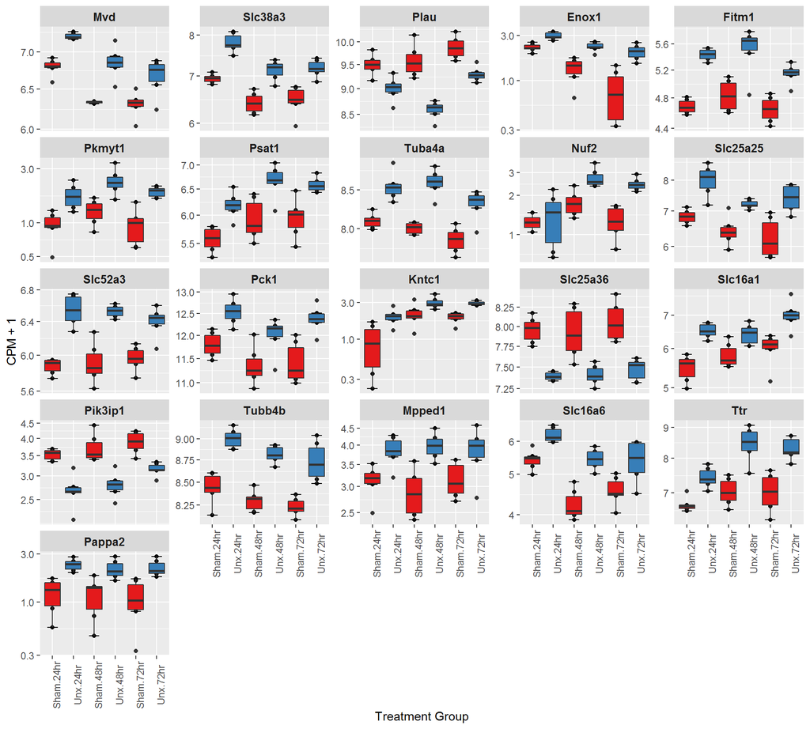

```r
cpm(dgeList, log=TRUE, prior.count = 3)[tfit$genes$gene_id[de.common],] %>%
  as.data.frame() %>%
  rownames_to_column("gene_id") %>%
    as_tibble() %>%
    gather(key = "sample", value = "CPM", -gene_id) %>%
    mutate(CPM = CPM + 1) %>%
    left_join(dgeList$samples) %>%
  mutate(treatment = fct_relevel(treatment, "Sham","Unx")) %>%
  mutate(group = fct_relevel(group, "Sham.24hr","Unx.24hr","Sham.48hr","Unx.48hr","Sham.72hr","Unx.72hr")) %>%
    ggplot(aes(group, CPM, fill = treatment)) +
  geom_point() +
    # geom_text_repel(aes(label = time)) +
  stat_boxplot(geom='errorbar', linetype=1, width=0.5)+
    geom_boxplot() +
    facet_wrap(
        ~gene_id,
        scales = "free_y",
        labeller = as_labeller(
            structure(dgeList$genes$gene_name, names = dgeList$genes$gene_id)
        )) + scale_fill_manual(values = treatCols) +
    scale_y_log10()  +
    labs(x = "Treatment Group",
         y = "CPM + 1") +
    theme(legend.position = "none",axis.text.x = element_text(angle = 90),
          strip.text = element_text(size= 10, face="bold"))
```

```r
#Annotation colour for volcano plot
deCols <- c(
  'Up' = rgb(1, 0, 0, 1),
  'Down' = rgb(0, 0, 1, 1),
  'NotSig' = rgb(0.5, 0.5, 0.5, 0.7),
  `FALSE` = rgb(0.5, 0.5, 0.5, 0.7),
  `TRUE` = rgb(1, 0, 0, 0.7))
```

## Annotate top 30 genes - Volcano plot

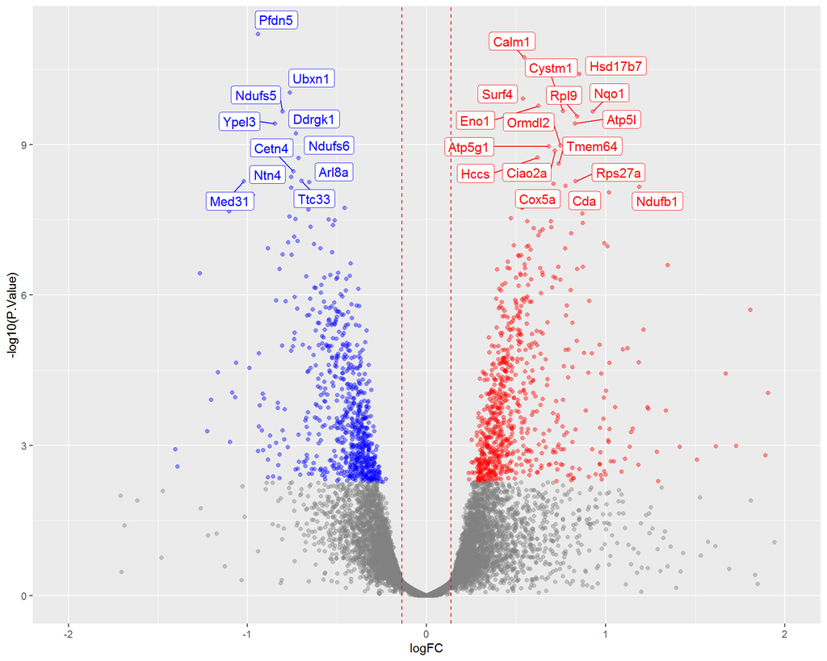

*Volcano plot labelling select points considered as DE.*

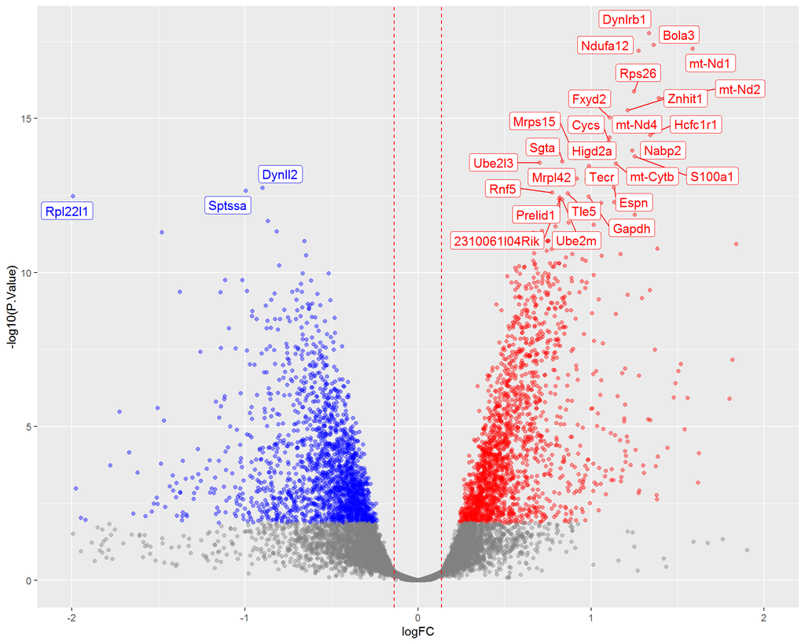

*Volcano plot labelling select points considered as DE.*

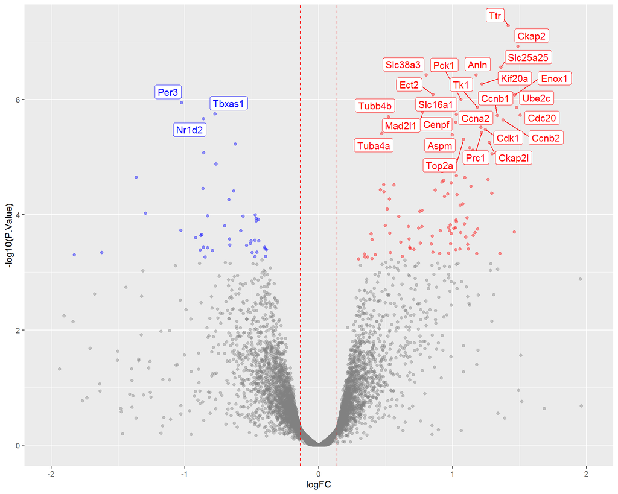

*Volcano plot labelling select points considered as DE.*

## Annotate top 30 stable sham genes DE - Volcano plot

```r
topTables_stable <- readRDS("C:/Users/cronos/Box Sync/Desktop/Renal Hypertrophy/CRH_RNAseq/topTables_stable.rds")
```

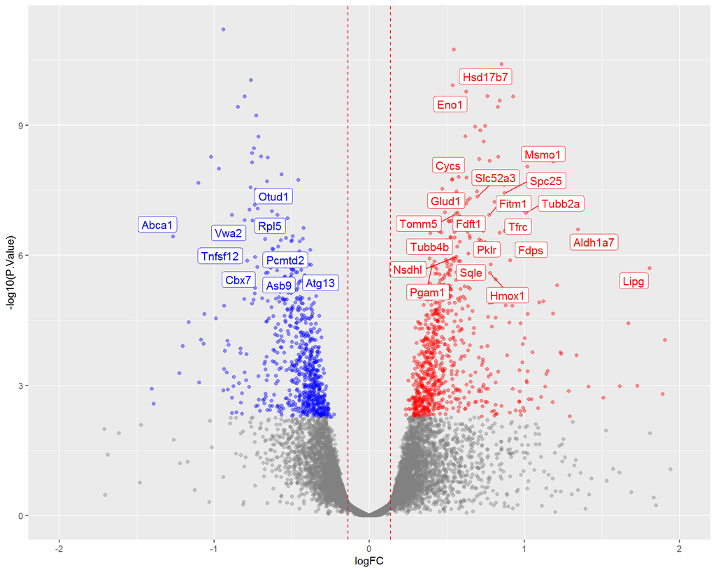

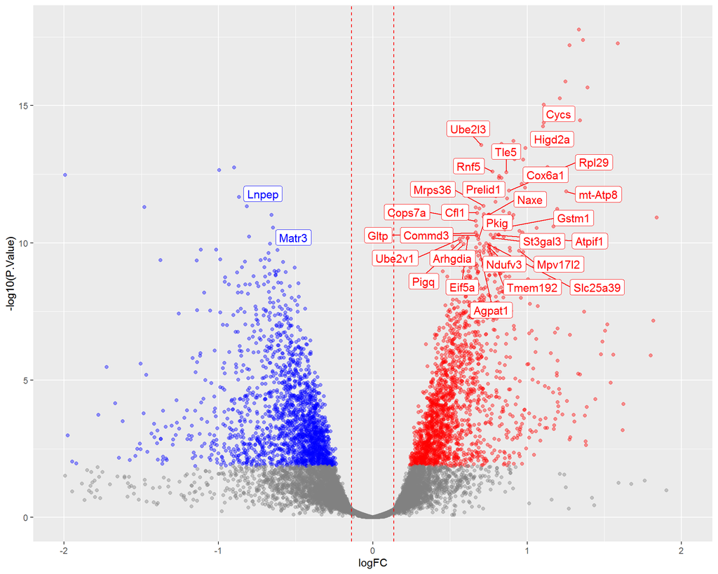

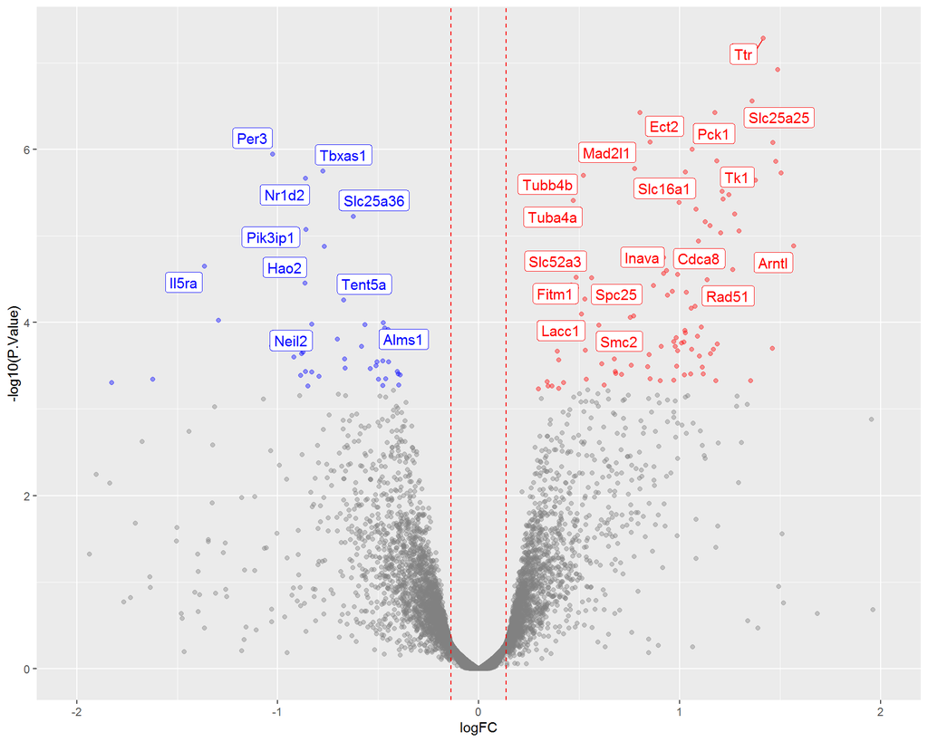

```r
lfc=log2(1.1)
names(topTables[1:3]) %>%
  sapply(function(x){
    topTables[[x]] %>%
      bind_rows() %>%
      ggplot(aes(logFC, -log10(P.Value), colour = Status)) +
      geom_point(alpha = 0.4) +
      geom_label_repel(
        aes(label = gene_name), size = 4,
        max.overlaps = getOption("ggrepel.max.overlaps", default = 30),
        data = topTables_stable[[x]] %>% dplyr::filter(Stable==TRUE) %>% .[c(1:30),])+
      geom_vline(
        xintercept = c(-1, 1)*lfc,
        linetype = 2,
        colour = "red") +
      scale_colour_manual(values = deCols) +
      scale_x_continuous(breaks = seq(-4, 4, by = 2))+
      xlim(-2,2)+
  theme(legend.position = "none")}, simplify = FALSE)
```

# Enrichment Analysis

```r
orgDb <- org.Mm.eg.db

topTables <- readRDS("C:/Users/cronos/Box Sync/Desktop/Renal Hypertrophy/CRH_RNAseq/topTables_stable_TF.rds")
```

## Gene Ontology (GO) Enrichment Analysis

```r
sigIDs <- names(topTables) %>%
  sapply(function(x){topTables[[x]] %>%
  dplyr::filter(adj.P.Val < 0.05) %>%
    extract2("entrezid") %>%
    unlist() %>%
  na.omit() %>%
    unique()
        }, simplify = FALSE)

uv <- unlist(topTables$Sham48vsUnx48$entrezid) %>%
  na.omit() %>%
  unique()
```

```r
eGO <- names(sigIDs) %>%
        sapply(function(x){
            enrichGO(
                gene = as.character(sigIDs[[x]]),
                universe = as.character(uv),
                # ont = "ALL",
                pAdjustMethod = "fdr",
                pvalueCutoff = 0.05 ,
                OrgDb = orgDb,
                readable = TRUE) %>%
            simplify() # This step helps to remove redundant GO terms using semantic similarity
        }, simplify = FALSE)
```

```r
eGO[["Sham24vsUnx24"]]@result %>% dplyr::select(-ID) %>%
  kable %>%
  kable_styling() %>%
  scroll_box(height="700px")
```

|  | Description | GeneRatio | BgRatio | pvalue | p.adjust | qvalue | geneID | Count |
| --- | --- | --- | --- | --- | --- | --- | --- | --- |
| GO:0003735 | structural constituent of ribosome | 43/1353 | 148/12409 | 0.00e+00 | 0.0000008 | 0.0000008 | Rpl9/Rps27a/Mrps11/Rpl37a/Rpl5/Mrpl36/Rps14/Rps3a1/Ndufa7/Rp…… | 43 |
| GO:0009055 | electron transfer activity | 23/1353 | 81/12409 | 1.12e-05 | 0.0047975 | 0.0047322 | Cox5a/Ndufa4/Cox7a2l/Ndufv2/Ndufc2/Ndufs7/Ndufa2/Ndufa7/Ndufa13/Ndufb8/Sh3bgrl3/Etfa/Cox7b/Glrx5/Ndufs4/Ndufs8/CYTB/Cyc1/Cox7a2/Acadsb/Uqcrfs1/ND5/Cox7a1 | 23 |
| GO:0015078 | proton transmembrane transporter activity | 24/1353 | 93/12409 | 4.16e-05 | 0.0118940 | 0.0117321 | Atp5l/Atp5g1/Cox5a/Atp5k/Ndufa4/Cox7a2l/Atp6v0e/Atp5e/Atp5j/Atp5g3/Cox7b/Atp6v1d/Atp5j2/Atp6v1e1/ATP8/Cox7a2/Atp6v1h/Clcn5/Slc45a3/Slc9a2/Atp6v0d2/Cox7a1/Atp5h/Atp5o | 24 |
| GO:0003954 | NADH dehydrogenase activity | 11/1353 | 28/12409 | 9.18e-05 | 0.0131238 | 0.0129451 | Ndufb1/Ndufv2/Ndufc2/Ndufs7/Ndufa2/Ndufa7/Ndufa13/Ndufb8/Ndufs4/Ndufs8/ND5 | 11 |
| GO:0003955 | NAD(P)H dehydrogenase (quinone) activity | 11/1353 | 28/12409 | 9.18e-05 | 0.0131238 | 0.0129451 | Nqo1/Ndufv2/Ndufc2/Ndufs7/Ndufa2/Ndufa7/Ndufa13/Ndufb8/Ndufs4/Ndufs8/ND5 | 11 |

```r
eGO[["Sham48vsUnx48"]]@result %>% dplyr::select(-ID) %>%
  kable %>%
  kable_styling() %>%
  scroll_box(height="700px")
```

|  | Description | GeneRatio | BgRatio | pvalue | p.adjust | qvalue | geneID | Count |
| --- | --- | --- | --- | --- | --- | --- | --- | --- |
| GO:0003735 | structural constituent of ribosome | 73/3408 | 148/12409 | 0 | 1.1e-05 | 1.1e-05 | Rps26/Mrps15/Rpl22l1/Rpl10/Rpl28/Rpl29/Mrpl46/Mrpl34/Rpl35/M…… | 73 |

```r
eGO[["Sham72vsUnx72"]]@result %>% dplyr::select(-ID) %>%
  kable %>%
  kable_styling() %>%
  scroll_box(height="700px")
```

|  | Description | GeneRatio | BgRatio | pvalue | p.adjust | qvalue | geneID | Count |
| --- | --- | --- | --- | --- | --- | --- | --- | --- |
| GO:0008017 | microtubule binding | 18/153 | 220/12409 | 0.0000000 | 0.0000001 | 0.0000001 | Kif20a/Prc1/Kif22/Tpx2/Birc5/Racgap1/Kifc1/Nusap1/Alms1/Neil2/Plk1/Kif4/Kif23/Cenpe/Kif2c/Kif11/Knstrn/Fam83d | 18 |
| GO:0003777 | microtubule motor activity | 8/153 | 51/12409 | 0.0000002 | 0.0000200 | 0.0000180 | Kif20a/Kif22/Kifc1/Kif4/Kif23/Cenpe/Kif2c/Kif11 | 8 |
| GO:0005200 | structural constituent of cytoskeleton | 5/153 | 44/12409 | 0.0001967 | 0.0130598 | 0.0117596 | Tubb4b/Tuba4a/Tuba1b/Tuba1c/Tln2 | 5 |
| GO:0070888 | E-box binding | 4/153 | 31/12409 | 0.0005395 | 0.0298519 | 0.0268799 | Arntl/Bhlhe41/Nr1d1/Clock | 4 |

## Gene Ontology (GO) Enrichment Analysis for Upregulated Genes

```r
sigIDsUP <- names(topTables) %>%
  sapply(function(x){topTables[[x]] %>%
  dplyr::filter(adj.P.Val < 0.05 & Status=="Up") %>%
    extract2("entrezid") %>%
    unlist() %>%
  na.omit() %>%
    unique()
        }, simplify = FALSE)
```

```r
eGO_UP <- names(sigIDsUP) %>%
        sapply(function(x){
            enrichGO(
                gene = as.character(sigIDsUP[[x]]),
                # universe = as.character(uv),
                # ont = "ALL",
                pAdjustMethod = "fdr",
                pvalueCutoff = 0.05 ,
                OrgDb = orgDb,
                readable = TRUE) %>%
            simplify() # This step helps to remove redundant GO terms using semantic similarity
        }, simplify = FALSE)
```

```r
eGO_UP[["Sham24vsUnx24"]]@result %>% dplyr::select(-ID) %>%
  kable %>%
  kable_styling() %>%
  scroll_box(height="300px")
```

|  | Description | GeneRatio | BgRatio | pvalue | p.adjust | qvalue | geneID | Count |
| --- | --- | --- | --- | --- | --- | --- | --- | --- |
| GO:0003735 | structural constituent of ribosome | 35/694 | 158/22682 | 0.0000000 | 0.0000000 | 0.0000000 | Rpl9/Rps27a/Mrps11/Rpl37a/Mrpl36/Rps14/Ndufa7/Rpl15/Rpl39/Rp…… | 35 |
| GO:0009055 | electron transfer activity | 17/694 | 88/22682 | 0.0000000 | 0.0000004 | 0.0000003 | Cox5a/Ndufa4/Ndufv2/Ndufc2/Ndufs7/Ndufa2/Ndufa7/Ndufa13/Ndufb8/Etfa/Cox7b/Glrx5/Ndufs4/Ndufs8/Cyc1/Cox7a2/Uqcrfs1 | 17 |
| GO:0015078 | proton transmembrane transporter activity | 19/694 | 113/22682 | 0.0000000 | 0.0000004 | 0.0000003 | Atp5l/Atp5g1/Cox5a/Atp5k/Ndufa4/Atp6v0e/Atp5e/Atp5j/Atp5g3/Cox7b/Atp5j2/Atp6v1e1/ATP8/Cox7a2/Atp6v1h/Clcn5/Slc45a3/Slc9a2/Atp5o | 19 |
| GO:0003954 | NADH dehydrogenase activity | 10/694 | 28/22682 | 0.0000000 | 0.0000008 | 0.0000007 | Ndufb1/Ndufv2/Ndufc2/Ndufs7/Ndufa2/Ndufa7/Ndufa13/Ndufb8/Ndufs4/Ndufs8 | 10 |
| GO:0003955 | NAD(P)H dehydrogenase (quinone) activity | 10/694 | 28/22682 | 0.0000000 | 0.0000008 | 0.0000007 | Nqo1/Ndufv2/Ndufc2/Ndufs7/Ndufa2/Ndufa7/Ndufa13/Ndufb8/Ndufs4/Ndufs8 | 10 |
| GO:0016836 | hydro-lyase activity | 11/694 | 57/22682 | 0.0000010 | 0.0000763 | 0.0000641 | Eno1/Hacd3/Hmbs/Car2/Eci1/Echs1/Hacd1/Hadha/Pcbd1/Eno1b/Car15 | 11 |
| GO:0016667 | oxidoreductase activity, acting on a sulfur group of donors | 10/694 | 56/22682 | 0.0000067 | 0.0003794 | 0.0003188 | Txn1/Tmx2/Txndc17/Srxn1/Dnajc10/Glrx5/Txnl1/Msrb1/Chchd4/Ero1a | 10 |
| GO:0016616 | oxidoreductase activity, acting on the CH-OH group of donors, NAD or NADP as acceptor | 16/694 | 142/22682 | 0.0000075 | 0.0003944 | 0.0003313 | Hsd17b7/Ldha/Nsdhl/Idh1/Dhrs7b/Akr1e1/Hsd17b12/Rdh10/Hadh/Idh3a/Cbr3/Impdh2/Mdh1/Cryl1/Hadha/Grhpr | 16 |
| GO:0043021 | ribonucleoprotein complex binding | 16/694 | 150/22682 | 0.0000152 | 0.0007093 | 0.0005959 | Sec61b/Snrpe/Rpl35a/Eif2s1/Nme1/Derl1/Snrpg/Rplp1/Eif1/Naa15/Timm50/Ltn1/Eif6/Hspa5/Pttg1/Bop1 | 16 |
| GO:0001882 | nucleoside binding | 28/694 | 376/22682 | 0.0000155 | 0.0007093 | 0.0005959 | Cda/Glud1/Tubb2a/Ran/Arl1/Tubb4b/Pnp/Rap1a/Tuba4a/Gna13/Mtg1/Nme1/Tubb5/Arf2/Tubb2b/Pck1/Gnai1/Rab21/Srp54b/Kras/Rab31/Rab29/Drg2/Gpn1/Hsp90aa1/Arl10/Gnl3/Cdc42 | 28 |
| GO:0004298 | threonine-type endopeptidase activity | 6/694 | 21/22682 | 0.0000294 | 0.0010778 | 0.0009054 | Psmb5/Psma3/Psmb4/Psma1/Psmb2/Psma2 | 6 |
| GO:0005525 | GTP binding | 26/694 | 356/22682 | 0.0000429 | 0.0014971 | 0.0012577 | Glud1/Tubb2a/Ran/Arl1/Tubb4b/Rap1a/Tuba4a/Gna13/Mtg1/Nme1/Tubb5/Arf2/Tubb2b/Pck1/Gnai1/Rab21/Srp54b/Kras/Rab31/Rab29/Drg2/Gpn1/Hsp90aa1/Arl10/Gnl3/Cdc42 | 26 |
| GO:0051287 | NAD binding | 9/694 | 61/22682 | 0.0000933 | 0.0027360 | 0.0022985 | Glud1/Idh1/Hadh/Aldh1a1/Idh3a/Mdh1/Cryl1/Hadha/Grhpr | 9 |
| GO:0019001 | guanyl nucleotide binding | 26/694 | 380/22682 | 0.0001250 | 0.0032732 | 0.0027498 | Glud1/Tubb2a/Ran/Arl1/Tubb4b/Rap1a/Tuba4a/Gna13/Mtg1/Nme1/Tubb5/Arf2/Tubb2b/Pck1/Gnai1/Rab21/Srp54b/Kras/Rab31/Rab29/Drg2/Gpn1/Hsp90aa1/Arl10/Gnl3/Cdc42 | 26 |
| GO:0032561 | guanyl ribonucleotide binding | 26/694 | 380/22682 | 0.0001250 | 0.0032732 | 0.0027498 | Glud1/Tubb2a/Ran/Arl1/Tubb4b/Rap1a/Tuba4a/Gna13/Mtg1/Nme1/Tubb5/Arf2/Tubb2b/Pck1/Gnai1/Rab21/Srp54b/Kras/Rab31/Rab29/Drg2/Gpn1/Hsp90aa1/Arl10/Gnl3/Cdc42 | 26 |
| GO:0070181 | small ribosomal subunit rRNA binding | 4/694 | 10/22682 | 0.0001575 | 0.0039519 | 0.0033200 | Mrps11/Rps14/Mrps18a/Mrps18c | 4 |
| GO:0031072 | heat shock protein binding | 14/694 | 146/22682 | 0.0001617 | 0.0039519 | 0.0033200 | Eno1/Tfrc/Cltc/Dnajc10/Mvd/Ptges3/Ptges3l/Dnajb1/Faf1/Dnajb9/Hspa5/Kpnb1/Pttg1/Eno1b | 14 |
| GO:0016746 | transferase activity, transferring acyl groups | 20/694 | 262/22682 | 0.0001776 | 0.0041988 | 0.0035274 | Dlat/Cpt2/Naa50/Cs/Hmgcs1/Zdhhc23/Abhd5/Elovl1/Hat1/Prdx6/Sat1/Naa15/Cers2/Naa20/Naa25/Gnpat/Ate1/Elovl2/Zdhhc12/Hadha | 20 |
| GO:0051087 | chaperone binding | 11/694 | 101/22682 | 0.0002658 | 0.0057309 | 0.0048145 | Tfrc/Dnajc10/Atp1a1/Ptges3/Ptges3l/Timm9/Dnajb1/Dnajb9/Erp29/Amfr/Slc25a17 | 11 |
| GO:0004596 | peptide alpha-N-acetyltransferase activity | 4/694 | 12/22682 | 0.0003535 | 0.0074029 | 0.0062191 | Naa50/Naa15/Naa20/Naa25 | 4 |
| GO:0003924 | GTPase activity | 21/694 | 298/22682 | 0.0003675 | 0.0074836 | 0.0062869 | Tubb2a/Ran/Arl1/Tubb4b/Rap1a/Tuba4a/Gna13/Mtg1/Tubb5/Gnb2/Gng10/Tubb2b/Gnai1/Rab21/Srp54b/Kras/Rab31/Rab29/Drg2/Gpn1/Cdc42 | 21 |
| GO:0008509 | anion transmembrane transporter activity | 27/694 | 443/22682 | 0.0005879 | 0.0116458 | 0.0097836 | Slc52a3/Slc25a20/Slc25a11/Slc38a3/Slc25a25/Slc35a4/Slc26a6/F…… | 27 |
| GO:0005200 | structural constituent of cytoskeleton | 8/694 | 64/22682 | 0.0007205 | 0.0132896 | 0.0111646 | Tubb2a/Actr2/Tubb4b/Tuba4a/Actb/Tubb5/Tubb2b/Actg1 | 8 |
| GO:0051536 | iron-sulfur cluster binding | 8/694 | 66/22682 | 0.0008863 | 0.0154674 | 0.0129941 | Ndufv2/Ndufs7/Cisd3/Ciapin1/Glrx5/Ndufs8/Nubp1/Uqcrfs1 | 8 |
| GO:0051540 | metal cluster binding | 8/694 | 66/22682 | 0.0008863 | 0.0154674 | 0.0129941 | Ndufv2/Ndufs7/Cisd3/Ciapin1/Glrx5/Ndufs8/Nubp1/Uqcrfs1 | 8 |
| GO:0031625 | ubiquitin protein ligase binding | 20/694 | 306/22682 | 0.0012718 | 0.0211868 | 0.0177990 | Rps27a/Vcp/Psma3/Ubc/Ube2a/Sumo2/Tubb5/Map1lc3a/Derl1/Slc25a5/Prdx6/Ptk2/Faf1/Hspbp1/Brca1/Hspa5/Actg1/Hsp90aa1/Vcl/Rb1 | 20 |
| GO:0005048 | signal sequence binding | 6/694 | 44/22682 | 0.0021054 | 0.0342950 | 0.0288110 | Kpna1/Nupl1/Kdelr2/Tomm40l/Srp54b/Kpnb1 | 6 |
| GO:0004550 | nucleoside diphosphate kinase activity | 4/694 | 19/22682 | 0.0023340 | 0.0363997 | 0.0305792 | Nme1/Cmpk2/Pck1/Nme6 | 4 |
| GO:0070182 | DNA polymerase binding | 4/694 | 19/22682 | 0.0023340 | 0.0363997 | 0.0305792 | Ptges3/Rad51/Pcna/Hsp90aa1 | 4 |
| GO:0140104 | molecular carrier activity | 7/694 | 62/22682 | 0.0027834 | 0.0416370 | 0.0349790 | Mmgt1/Ndufab1/Kpna1/Xpo4/Kpnb1/Atox1/Emc3 | 7 |
| GO:1990381 | ubiquitin-specific protease binding | 4/694 | 20/22682 | 0.0028475 | 0.0417449 | 0.0350697 | Vcp/Cltc/Derl1/Amfr | 4 |
| GO:0003993 | acid phosphatase activity | 3/694 | 10/22682 | 0.0029137 | 0.0418773 | 0.0351809 | Acp2/Acp1/Acp5 | 3 |
| GO:0051020 | GTPase binding | 19/694 | 307/22682 | 0.0030618 | 0.0431595 | 0.0362580 | Eno1/Cib1/Rap1a/Flna/Pak2/Gnb2/Mff/Brk1/Iqgap3/Ipo13/Cdc42se2/Rab29/Hsp90aa1/Usp33/Vcl/Kpnb1/Map2k1/Eno1b/Exoc5 | 19 |
| GO:0000287 | magnesium ion binding | 14/694 | 198/22682 | 0.0032240 | 0.0445882 | 0.0374583 | Ran/Idi1/Pklr/Idh1/Hmgcl/Nme1/Foxk2/Impa1/Pck1/Mvk/Gnai1/Idh3a/Farsb/Nudt5 | 14 |
| GO:0019829 | ATPase-coupled cation transmembrane transporter activity | 6/694 | 48/22682 | 0.0033020 | 0.0448209 | 0.0376538 | Atp5l/Atp6v0e/Atp5e/Atp6v1e1/Atp1a1/Atp6v1h | 6 |
| GO:0016831 | carboxy-lyase activity | 5/694 | 34/22682 | 0.0035250 | 0.0469786 | 0.0394665 | Got1/Mvd/Pck1/Ppcdc/Sgpl1 | 5 |
| GO:0016874 | ligase activity | 12/694 | 160/22682 | 0.0038506 | 0.0484254 | 0.0406819 | Atp5l/Atp5e/Yars2/Ppcs/Atp5j/Qrsl1/Atp5j2/Ctps/Farsb/Cars2/Atp5o/Sae1 | 12 |
| GO:0016209 | antioxidant activity | 8/694 | 83/22682 | 0.0038724 | 0.0484254 | 0.0406819 | Nqo1/Prdx3/Txndc17/Prdx1/Srxn1/Gstp1/Prdx6/Prdx4 | 8 |
| GO:0004129 | cytochrome-c oxidase activity | 4/694 | 22/22682 | 0.0040960 | 0.0484254 | 0.0406819 | Cox5a/Ndufa4/Cox7b/Cox7a2 | 4 |
| GO:0015002 | heme-copper terminal oxidase activity | 4/694 | 22/22682 | 0.0040960 | 0.0484254 | 0.0406819 | Cox5a/Ndufa4/Cox7b/Cox7a2 | 4 |
| GO:0016676 | oxidoreductase activity, acting on a heme group of donors, oxygen as acceptor | 4/694 | 22/22682 | 0.0040960 | 0.0484254 | 0.0406819 | Cox5a/Ndufa4/Cox7b/Cox7a2 | 4 |

```r
eGO_UP[["Sham48vsUnx48"]]@result %>% dplyr::select(-ID) %>%
  kable %>%
  kable_styling() %>%
  scroll_box(height="300px")
```

|  | Description | GeneRatio | BgRatio | pvalue | p.adjust | qvalue | geneID | Count |
| --- | --- | --- | --- | --- | --- | --- | --- | --- |
| GO:0003735 | structural constituent of ribosome | 39/1734 | 158/22682 | 0.0000000 | 0.0000000 | 0.0000000 | Rps26/Mrps15/Rpl28/Rpl29/Mrpl46/Mrpl34/Rpl35/Mrps2/Rpl18a/Mr…… | 39 |
| GO:0003713 | transcription coactivator activity | 47/1734 | 245/22682 | 0.0000000 | 0.0000019 | 0.0000016 | Ube2l3/Wbp2/Drap1/Gps2/Tsg101/Edf1/Ascc1/Hmga1/Bcl3/Taf9/Zmi…… | 47 |
| GO:0140297 | DNA-binding transcription factor binding | 63/1734 | 410/22682 | 0.0000001 | 0.0000202 | 0.0000168 | Tle5/Wbp2/Usf2/Srf/Ywhah/Hmga1/Taf9/Actn4/Gas2l1/Nr1h2/Med25…… | 63 |
| GO:0009055 | electron transfer activity | 23/1734 | 88/22682 | 0.0000001 | 0.0000243 | 0.0000203 | Ndufa12/ND2/ND4/CYTB/ND5/Cox6a1/COX1/Por/Cox8a/Ndufa10/Cox10/Sh3bgrl3/Ptges2/Uqcr11/Cyb5a/COX3/Cox6a2/COX2/Glrx/Uqcrq/Gsr/Ndufs8/Cyba | 23 |
| GO:0031072 | heat shock protein binding | 28/1734 | 146/22682 | 0.0000051 | 0.0006397 | 0.0005342 | Bak1/Arhgdia/Fkbp1a/Irak1/Ppp5c/Bag2/Mvd/Hsf1/Ulk1/Ogdh/Dnajb12/Stip1/Dnajc8/Apoa2/Bag6/Nup62/Mapt/Stub1/Pttg1/Cyp2e1/Npas2/Camkmt/Tsacc/Mettl22/Arntl/Bag3/Zfp36/Ahsa1 | 28 |
| GO:0051427 | hormone receptor binding | 31/1734 | 182/22682 | 0.0000204 | 0.0019381 | 0.0016186 | Wbp2/Ywhah/Hmga1/Actn4/Gas2l1/Nr1h2/Med25/Taf10/Med24/Jund/Hsd17b10/Park7/Calr/Tada3/Nr1h3/Ncoa6/Tgfb1i1/Zbtb7a/Smarca4/Jup/Ddx54/Vdr/Med4/Gnas/Med16/Ncor1/Ncor2/Ipo13/Tacc2/Trim24/Arid1a | 31 |
| GO:0016829 | lyase activity | 32/1734 | 191/22682 | 0.0000213 | 0.0019381 | 0.0016186 | Naxd/Shmt2/Aco2/Mgst3/Dglucy/Clybl/Hmga1/Srr/Echdc3/Car15/Mvd/Ptges2/Polb/Pm20d1/Ggact/L3hypdh/Park7/Echdc2/Cenpv/Pisd/Odc1/Hmbs/Hoga1/Pck1/Car2/Scly/Urah/Car4/Neil3/Kyat1/Gmds/Car12 | 32 |
| GO:0061631 | ubiquitin conjugating enzyme activity | 12/1734 | 39/22682 | 0.0000214 | 0.0019381 | 0.0016186 | Ube2l3/Cdc34/Ube2v1/Ube2r2/Ube2c/Ube2k/Ube2j2/Ube2s/Ube2d3/Ube2d1/Ube2q1/Ube2e2 | 12 |
| GO:0008017 | microtubule binding | 40/1734 | 266/22682 | 0.0000299 | 0.0024811 | 0.0020720 | Gapdh/Gabarap/Dnm2/Ezr/Pex14/Gas2l1/Ppp5c/Arl3/Trpv4/Tpx2/Pl…… | 40 |
| GO:0043021 | ribonucleoprotein complex binding | 26/1734 | 150/22682 | 0.0000678 | 0.0042682 | 0.0035645 | Csnk2b/Rpl35/Eif5a/Eefsec/Snrpd3/Ppp1ca/Snrpc/Prmt5/Ybx2/Rpsa/Pqbp1/Gadd45gip1/Ybx3/Bag6/Mtif3/Srp54a/Abce1/Pttg1/Eif3k/Pym1/Timm50/Taco1/Srpr/Letm1/Dhx29/Eef2 | 26 |
| GO:0001098 | basal transcription machinery binding | 14/1734 | 57/22682 | 0.0000743 | 0.0042682 | 0.0035645 | Drap1/Edf1/Elof1/Gtf2f1/Wac/Scaf4/Rtraf/Brd4/Trp53/Fbl/Paf1/Scaf1/Tbp/Ercc1 | 14 |
| GO:0001099 | basal RNA polymerase II transcription machinery binding | 14/1734 | 57/22682 | 0.0000743 | 0.0042682 | 0.0035645 | Drap1/Edf1/Elof1/Gtf2f1/Wac/Scaf4/Rtraf/Brd4/Trp53/Fbl/Paf1/Scaf1/Tbp/Ercc1 | 14 |
| GO:0002039 | p53 binding | 16/1734 | 72/22682 | 0.0000860 | 0.0042682 | 0.0035645 | Ybx1/Psme3/Taf9/Kmt5a/Prmt5/Trp53/Usp10/Zfp385a/Mapkapk5/Stk11/Smarca4/Brd7/Noc2l/Bcl2l12/Eef2/Trim24 | 16 |
| GO:0045182 | translation regulator activity | 23/1734 | 127/22682 | 0.0000876 | 0.0042682 | 0.0035645 | Shmt2/Eif5a/Eefsec/Eif3h/Ybx2/Eif2b2/Samd4b/Eif3l/Aars/Gfm1/Mtif3/Eif3k/Rara/Eif4g3/Mif4gd/Eif4e2/Eif2ak1/Mrpl58/Eif4g1/Gspt1/Denr/Dhx29/Eef2 | 23 |
| GO:0050699 | WW domain binding | 10/1734 | 32/22682 | 0.0000898 | 0.0042682 | 0.0035645 | Shisa5/Dnm2/Traf4/Wbp11/Tceal8/Wbp1/Pmepa1/Scnn1a/Trex1/Scnn1b | 10 |
| GO:0090079 | translation regulator activity, nucleic acid binding | 19/1734 | 95/22682 | 0.0000899 | 0.0042682 | 0.0035645 | Shmt2/Eif5a/Eefsec/Eif3h/Eif2b2/Eif3l/Gfm1/Mtif3/Eif3k/Rara/Eif4g3/Mif4gd/Eif4e2/Mrpl58/Eif4g1/Gspt1/Denr/Dhx29/Eef2 | 19 |
| GO:0051117 | ATPase binding | 19/1734 | 98/22682 | 0.0001388 | 0.0062236 | 0.0051976 | S100a1/Atpif1/Arpc2/Ubxn1/Nsfl1c/Ezr/Taf9/Nr1h2/Rac1/Fbl/Psen1/Rab4a/Clpp/Syvn1/Vcpkmt/Ralb/Nkain1/Pih1d1/Atp6v0a1 | 19 |
| GO:0043130 | ubiquitin binding | 16/1734 | 75/22682 | 0.0001436 | 0.0062236 | 0.0051976 | Aup1/Ubxn1/Nsfl1c/Sharpin/Sirt2/Otub1/Tsg101/Adrm1/Vps28/Trp53inp2/Rad23b/Rae1/Rad23a/Ubap1/Nup62/Ascc2 | 16 |
| GO:0051015 | actin filament binding | 32/1734 | 212/22682 | 0.0001663 | 0.0067443 | 0.0056324 | Espn/Cfl1/Arpc2/Dmtn/Ezr/Actn4/Gas2l1/Triobp/Trpv4/Ush1c/Coro1b/Capzb/Coro1c/Arpc3/Camsap3/Tpm3/Cotl1/Dbn1/Ppp1r9b/Arpc5/Vill/Shtn1/Coro7/Eps8l2/Myo19/Twf1/Map1s/Coro6/Lasp1/Coro2b/Myh14/Eef2 | 32 |
| GO:0042826 | histone deacetylase binding | 22/1734 | 125/22682 | 0.0001900 | 0.0071222 | 0.0059480 | Znhit1/Thap7/Zbtb7b/Sirt2/Srf/Ywhae/Kat2a/Rac1/Hoxa10/Rela/Sp2/Trp53/Camta2/Mta1/Wdtc1/Runx3/Rara/Brms1/Kpna2/Cdc20/Ncor1/Ncor2 | 22 |
| GO:0016675 | oxidoreductase activity, acting on a heme group of donors | 8/1734 | 23/22682 | 0.0001984 | 0.0071222 | 0.0059480 | Cox6a1/COX1/Por/Cox8a/Cox10/COX3/Cox6a2/COX2 | 8 |
| GO:0019003 | GDP binding | 16/1734 | 78/22682 | 0.0002323 | 0.0079850 | 0.0066686 | Rab7/Arf1/Rab8a/Rab5c/Arl3/Hras/Arl8b/Rhoa/Srp54a/Rab4a/Arl2/Pck1/Rab35/Rab11b/Ralb/Rab3b | 16 |
| GO:0016853 | isomerase activity | 25/1734 | 153/22682 | 0.0002424 | 0.0080563 | 0.0067281 | Naxe/Fkbp2/Fkbp1a/Gpi1/Srr/Pgam2/Ebp/Hsd3b3/Pgm2/Ptges2/Mif/Rpusd3/Degs1/Fuom/Creld1/Erp44/Ppia/Eci3/Ppil2/Rpusd1/Top1mt/Gnpda1/Gstz1/Ppif/Pgam1 | 25 |
| GO:0001091 | RNA polymerase II general transcription initiation factor binding | 7/1734 | 20/22682 | 0.0004803 | 0.0143482 | 0.0119827 | Drap1/Edf1/Gtf2f1/Trp53/Fbl/Tbp/Ercc1 | 7 |
| GO:0032550 | purine ribonucleoside binding | 46/1734 | 363/22682 | 0.0005037 | 0.0143482 | 0.0119827 | Rab7/Eefsec/Dnm2/Rab1b/Tubg1/Arf1/Rab8a/Arl8a/Tuba4a/Rab5c/R…… | 46 |
| GO:0008047 | enzyme activator activity | 56/1734 | 470/22682 | 0.0006291 | 0.0151876 | 0.0126837 | Ppp2r5d/Ranbp1/Arhgdia/Dad1/Dnajc19/Psme3/Adrm1/Arf1/Gm2a/Ar…… | 56 |
| GO:0046332 | SMAD binding | 16/1734 | 85/22682 | 0.0006398 | 0.0151876 | 0.0126837 | Fkbp1a/Creb3l1/Tob1/Zmiz1/Pmepa1/Dab2/Ski/Stub1/Men1/Runx3/Zc3h3/Tgfb1i1/Zbtb7a/Drosha/Hipk2/Tgfbrap1 | 16 |
| GO:0031593 | polyubiquitin modification-dependent protein binding | 12/1734 | 55/22682 | 0.0007651 | 0.0175753 | 0.0146777 | Ubxn1/Sharpin/Ubl7/Tab2/Rad23b/Babam2/Rad23a/Ubqln1/Bag6/Ubqln4/Tnip1/Mindy1 | 12 |
| GO:0140299 | small molecule sensor activity | 5/1734 | 11/22682 | 0.0008109 | 0.0175753 | 0.0146777 | Trpv4/Egln2/Tmem63b/Efhd1/Park7 | 5 |
| GO:0015078 | proton transmembrane transporter activity | 19/1734 | 113/22682 | 0.0009028 | 0.0180367 | 0.0150631 | Cox6a1/ATP8/COX1/Atp5d/ATP6/Cox8a/Atp6v0c/Cox10/Slc46a1/COX3/Cox6a2/Atp6v1g2/COX2/Atp6v1d/Atp6v0b/Letm1/Atp5g1/Atp5c1/Atp6v0a1 | 19 |
| GO:0004129 | cytochrome-c oxidase activity | 7/1734 | 22/22682 | 0.0009226 | 0.0180367 | 0.0150631 | Cox6a1/COX1/Cox8a/Cox10/COX3/Cox6a2/COX2 | 7 |
| GO:0015002 | heme-copper terminal oxidase activity | 7/1734 | 22/22682 | 0.0009226 | 0.0180367 | 0.0150631 | Cox6a1/COX1/Cox8a/Cox10/COX3/Cox6a2/COX2 | 7 |
| GO:0008022 | protein C-terminus binding | 32/1734 | 234/22682 | 0.0009712 | 0.0186200 | 0.0155503 | Pdzd11/Dynlt1b/Tesk1/Ezr/Atxn2/Phb2/Hras/Ap2a1/Pex10/Pqbp1/Dgkz/Scaf4/Stip1/Pxk/Trp53/Pabpc1/Banf1/Mad2l1/Dab2/Mapre3/Ppp1r9b/Vamp2/Mif4gd/Mki67/Dynlt1a/Pias4/Srebf2/Ercc1/Dapk3/Cib1/Cdc20/Mdc1 | 32 |
| GO:0060590 | ATPase regulator activity | 10/1734 | 42/22682 | 0.0010136 | 0.0190664 | 0.0159231 | Atpif1/Pfn1/Dnajc19/Bag2/Dnajc15/Rab4a/Bag3/Ncaph/Ahsa1/Katnb1 | 10 |
| GO:0016651 | oxidoreductase activity, acting on NAD(P)H | 15/1734 | 81/22682 | 0.0011114 | 0.0205204 | 0.0171374 | ND1/Ndufa12/ND2/ND4/ND5/Cyb5r3/Por/Ndufa10/Txndc17/Dcxr/Gmpr/Gsr/Ndufs8/Cyba/Dhrs4 | 15 |
| GO:0120014 | phospholipid transfer activity | 7/1734 | 23/22682 | 0.0012395 | 0.0224287 | 0.0187310 | Prelid1/Gltp/Pitpna/C2cd2l/Cptp/Prelid3b/Pitpnb | 7 |
| GO:0003924 | GTPase activity | 38/1734 | 298/22682 | 0.0013181 | 0.0224287 | 0.0187310 | Rab7/Eefsec/Dnm2/Rab1b/Tubg1/Rab8a/Tuba4a/Rab5c/Rhog/Gnai2/R…… | 38 |
| GO:0019001 | guanyl nucleotide binding | 46/1734 | 380/22682 | 0.0013273 | 0.0224287 | 0.0187310 | Rab7/Eefsec/Dnm2/Rab1b/Tubg1/Arf1/Rab8a/Arl8a/Tuba4a/Rab5c/R…… | 46 |
| GO:0032561 | guanyl ribonucleotide binding | 46/1734 | 380/22682 | 0.0013273 | 0.0224287 | 0.0187310 | Rab7/Eefsec/Dnm2/Rab1b/Tubg1/Arf1/Rab8a/Arl8a/Tuba4a/Rab5c/R…… | 46 |
| GO:0033764 | steroid dehydrogenase activity, acting on the CH-OH group of donors, NAD or NADP as acceptor | 9/1734 | 37/22682 | 0.0015264 | 0.0253636 | 0.0211821 | Nsdhl/Hsd3b3/Hsd17b11/Sdr42e1/Hsd17b10/Dhrs11/Hsd17b2/Hsd3b4/Hsd11b2 | 9 |
| GO:0016251 | RNA polymerase II general transcription initiation factor activity | 8/1734 | 31/22682 | 0.0018415 | 0.0296123 | 0.0247303 | Drap1/Taf9/Taf10/Taf12/Gtf2f1/Taf6/Taf9b/Tbp | 8 |
| GO:0017124 | SH3 domain binding | 20/1734 | 129/22682 | 0.0018741 | 0.0296582 | 0.0247686 | Espn/Dnm2/Inpp5j/Bcar1/Adam15/Arhgap1/Zfp384/Gpx1/Dennd1a/Mapt/Ptpn6/Usp8/Pttg1/Sh3bp1/Ilk/Arhgap17/Was/Cyba/Reps1/Abi3 | 20 |
| GO:0051287 | NAD binding | 12/1734 | 61/22682 | 0.0019852 | 0.0309250 | 0.0258266 | Gapdh/Cyb5r3/Sirt2/Idh3g/Nudt6/Adh1/Hsd17b10/Gpd1/Ahcy/Ldhb/Sirt6/Hsd11b2 | 12 |
| GO:0051020 | GTPase binding | 38/1734 | 307/22682 | 0.0022505 | 0.0325249 | 0.0271628 | Rab7/Ybx1/Arhgdia/Pfn1/Lamtor1/Clta/Map3k11/Arhgap1/Git1/Rac…… | 38 |
| GO:0071617 | lysophospholipid acyltransferase activity | 6/1734 | 19/22682 | 0.0022510 | 0.0325249 | 0.0271628 | Agpat1/Lpcat3/Lclat1/Mboat7/Agpat3/Sh3glb1 | 6 |
| GO:0140098 | catalytic activity, acting on RNA | 40/1734 | 333/22682 | 0.0030216 | 0.0413464 | 0.0345299 | Polr2j/Rnasek/Gatc/Lactb2/Polr2i/Polr2e/Rnaset2b/Polr3c/Ddx4…… | 40 |
| GO:0005200 | structural constituent of cytoskeleton | 12/1734 | 64/22682 | 0.0030274 | 0.0413464 | 0.0345299 | Arpc2/Tubg1/Tuba4a/Tuba1b/Tuba1c/Actb/Tubb4b/Arpc3/Tubb2a/Arpc5/Tubb6/Tubb5 | 12 |
| GO:0003729 | mRNA binding | 41/1734 | 344/22682 | 0.0031123 | 0.0419316 | 0.0350186 | Rps26/Shmt2/Rpl35/Ybx1/Dazap1/Eefsec/Rnps1/Rbpms2/Rps2/Rbm38…… | 41 |
| GO:0031406 | carboxylic acid binding | 27/1734 | 203/22682 | 0.0034365 | 0.0456829 | 0.0381515 | Shmt2/Arhgdia/Pitpna/Srr/Gstp1/Slc46a1/Ogfod3/Egln2/Ddah1/Aars/Got2/Ppard/Gnmt/Rara/Gchfr/Hmbs/Afm/Pck1/Acox3/Pgd/Vdr/Cyp26b1/Scly/Sh3glb1/Aars2/Siglece/Alb | 27 |

```r
eGO_UP[["Sham72vsUnx72"]]@result %>% dplyr::select(-ID) %>%
  kable %>%
  kable_styling() %>%
  scroll_box(height="300px")
```

|  | Description | GeneRatio | BgRatio | pvalue | p.adjust | qvalue | geneID | Count |
| --- | --- | --- | --- | --- | --- | --- | --- | --- |
| GO:0008017 | microtubule binding | 16/106 | 266/22682 | 0.0000000 | 0.0000000 | 0.0000000 | Kif20a/Prc1/Kif22/Tpx2/Birc5/Racgap1/Kifc1/Nusap1/Plk1/Kif4/Kif23/Cenpe/Kif2c/Kif11/Knstrn/Fam83d | 16 |
| GO:0003777 | microtubule motor activity | 8/106 | 70/22682 | 0.0000000 | 0.0000001 | 0.0000001 | Kif20a/Kif22/Kifc1/Kif4/Kif23/Cenpe/Kif2c/Kif11 | 8 |
| GO:0016538 | cyclin-dependent protein serine/threonine kinase regulator activity | 4/106 | 47/22682 | 0.0000689 | 0.0029147 | 0.0023192 | Ccnb1/Ccnb2/Ccna2/Cdkn1a | 4 |
| GO:0005200 | structural constituent of cytoskeleton | 4/106 | 64/22682 | 0.0002308 | 0.0083737 | 0.0066628 | Tubb4b/Tuba4a/Tuba1b/Tuba1c | 4 |
| GO:0008047 | enzyme activator activity | 9/106 | 470/22682 | 0.0003628 | 0.0115181 | 0.0091649 | Ect2/Ccnb1/Tpx2/Racgap1/Ppard/Arhgap11a/Ncaph/Iqgap3/Cdkn1a | 9 |
| GO:0030332 | cyclin binding | 3/106 | 33/22682 | 0.0004888 | 0.0137936 | 0.0109754 | Cdk1/Cdkn1a/Ndc80 | 3 |
| GO:0000217 | DNA secondary structure binding | 3/106 | 36/22682 | 0.0006331 | 0.0158556 | 0.0126162 | Neil3/Rad51c/Clspn | 3 |
| GO:0008022 | protein C-terminus binding | 6/106 | 234/22682 | 0.0008172 | 0.0172983 | 0.0137641 | Mad2l1/Cdc20/Cenpf/Top2a/Mki67/Rad51 | 6 |
| GO:0035173 | histone kinase activity | 2/106 | 16/22682 | 0.0024875 | 0.0421214 | 0.0335155 | Cdk1/Aurka | 2 |
| GO:0070182 | DNA polymerase binding | 2/106 | 19/22682 | 0.0035124 | 0.0469556 | 0.0373621 | Rad51/Fanci | 2 |

## Gene Ontology (GO) Enrichment Analysis for Downregulated Genes

```r
sigIDsDN <- names(topTables) %>%
  sapply(function(x){topTables[[x]] %>%
  dplyr::filter(adj.P.Val < 0.05 & Status=="Down") %>%
    extract2("entrezid") %>%
    unlist() %>%
  na.omit() %>%
    unique()
        }, simplify = FALSE)
```

```r
eGO_DN <- names(sigIDsDN) %>%
        sapply(function(x){
            enrichGO(
                gene = as.character(sigIDsDN[[x]]),
                # universe = as.character(uv),
                # ont = "ALL",
                pAdjustMethod = "fdr",
                pvalueCutoff = 0.05 ,
                OrgDb = orgDb,
                readable = TRUE) %>%
            simplify() # This step helps to remove redundant GO terms using semantic similarity
        }, simplify = FALSE)
```

```r
eGO_DN[["Sham24vsUnx24"]]@result %>% dplyr::select(-ID) %>%
  kable %>%
  kable_styling() %>%
  scroll_box(height="300px")
```

|  | Description | GeneRatio | BgRatio | pvalue | p.adjust | qvalue | geneID | Count |
| --- | --- | --- | --- | --- | --- | --- | --- | --- |
| GO:0140297 | DNA-binding transcription factor binding | 34/659 | 410/22682 | 0.0000000 | 0.0000346 | 0.0000310 | Ddrgk1/Gabarapl1/Spop/Lyar/Crtc2/Rela/Gabpa/Brd8/Xpc/Sin3a/Bhlhe41/Rere/Wbp2/Mta3/Nfatc1/Usf2/Tcerg1/Tcf3/Atn1/Spen/Rad23b/Hdac5/Ncoa7/Rbpj/Bcas3/Smarce1/Taf11/Setd6/Sall1/Ncor2/Fus/Akap8/Arid1a/Ttc8 | 34 |
| GO:0003712 | transcription coregulator activity | 34/659 | 466/22682 | 0.0000010 | 0.0003472 | 0.0003106 | Med31/Calcoco1/Eid1/Sfr1/Gps2/Brd8/Xpc/Sin3a/Cir1/Bhlhe41/Rere/Wbp2/Mta3/Cys1/Tcerg1/Bcl9/Kat6b/Atn1/Spen/Bclaf1/Hdac5/Sox12/Ncoa7/Phf12/Taf11/Mecp2/Ccnd1/Med8/Med15/Ncor2/Ncoa6/Fus/Zmiz1/Ddx1 | 34 |
| GO:0042826 | histone deacetylase binding | 15/659 | 125/22682 | 0.0000036 | 0.0008492 | 0.0007595 | Bex4/Rela/Cir1/Bhlhe41/Ywhae/Mta3/Hnrnpd/Rara/Hdac5/Hoxa10/Mecp2/Ccnd1/Tfap4/Ncor2/Akap8 | 15 |
| GO:0000993 | RNA polymerase II complex binding | 8/659 | 37/22682 | 0.0000089 | 0.0015868 | 0.0014193 | Wac/Rtf1/Uvssa/Rtraf/Paf1/Supt4a/Scaf4/Brd4 | 8 |
| GO:0003697 | single-stranded DNA binding | 13/659 | 115/22682 | 0.0000302 | 0.0030674 | 0.0027436 | Nabp2/Rtf1/Xpc/Msh3/Terf2/Ighmbp2/Fubp3/Spen/Ssbp1/Ssbp2/Hnrnpdl/Rad50/Lonp1 | 13 |
| GO:0140098 | catalytic activity, acting on RNA | 23/659 | 333/22682 | 0.0001248 | 0.0088884 | 0.0079501 | Cnot2/Drosha/Polr2a/Sars/Khnyn/Dtd1/Trmt1/Polr3gl/Ighmbp2/Elac1/Rexo2/Smg6/Fars2/Ddx42/Polr2e/Rnaseh1/Tut4/Nsun3/Ddx19a/Mettl14/Ddx59/Ddx1/Polr2m | 23 |
| GO:0016853 | isomerase activity | 14/659 | 153/22682 | 0.0001555 | 0.0100678 | 0.0090050 | Ppig/Pdilt/Fkbp2/Tbxas1/Katnal1/Pgm2/Pin4/Txndc5/Renbp/Top1mt/Ppic/Mmut/Itpk1/Mcee | 14 |
| GO:0001098 | basal transcription machinery binding | 8/659 | 57/22682 | 0.0002290 | 0.0118164 | 0.0105691 | Wac/Rtf1/Uvssa/Rtraf/Paf1/Supt4a/Scaf4/Brd4 | 8 |
| GO:0001099 | basal RNA polymerase II transcription machinery binding | 8/659 | 57/22682 | 0.0002290 | 0.0118164 | 0.0105691 | Wac/Rtf1/Uvssa/Rtraf/Paf1/Supt4a/Scaf4/Brd4 | 8 |
| GO:0003729 | mRNA binding | 22/659 | 344/22682 | 0.0005030 | 0.0238780 | 0.0213574 | Rpl5/Srsf5/Rps3a1/Rbms1/Dcp1b/Denr/Nsrp1/Khnyn/Ptbp2/Pabpc1/Rbfox1/Ybx2/Sf3b6/Hnrnpd/Fubp3/Rara/Supt5/Hnrnpr/Mecp2/Syncrip/Mettl14/Fus | 22 |
| GO:0008143 | poly(A) binding | 5/659 | 28/22682 | 0.0011507 | 0.0481926 | 0.0431054 | Rbms1/Pabpc1/Hnrnpdl/Syncrip/Ddx1 | 5 |

```r
eGO_DN[["Sham48vsUnx48"]]@result %>% dplyr::select(-ID) %>%
  kable %>%
  kable_styling() %>%
  scroll_box(height="300px")
```

|  | Description | GeneRatio | BgRatio | pvalue | p.adjust | qvalue | geneID | Count |
| --- | --- | --- | --- | --- | --- | --- | --- | --- |
| GO:0003735 | structural constituent of ribosome | 34/1675 | 158/22682 | 0.0000000 | 0.0000120 | 0.0000104 | Rpl22l1/Rpl10/Rpl39/Rps6/Rpl24/Rps27a/Rpl5/Rpl22/Mrps14/Rps2…… | 34 |
| GO:0019787 | ubiquitin-like protein transferase activity | 64/1675 | 434/22682 | 0.0000001 | 0.0000421 | 0.0000363 | Marchf6/Mib1/Trim23/Rnf103/Rmnd5a/Ltn1/Klhl21/Amfr/Xiap/Rc3h…… | 64 |
| GO:0004843 | thiol-dependent ubiquitin-specific protease activity | 22/1675 | 99/22682 | 0.0000025 | 0.0005122 | 0.0004420 | Mindy2/Usp34/Cops5/Cyld/Otud4/Usp9x/Mindy4/Desi2/Mysm1/Atxn3/Usp48/Usp31/Usp16/Usp40/Usp28/Usp33/Usp49/Usp35/Usp14/Otud1/Otud7b/Vcpip1 | 22 |
| GO:0101005 | ubiquitinyl hydrolase activity | 22/1675 | 101/22682 | 0.0000036 | 0.0005850 | 0.0005048 | Mindy2/Usp34/Cops5/Cyld/Otud4/Usp9x/Mindy4/Desi2/Mysm1/Atxn3/Usp48/Usp31/Usp16/Usp40/Usp28/Usp33/Usp49/Usp35/Usp14/Otud1/Otud7b/Vcpip1 | 22 |
| GO:0001217 | DNA-binding transcription repressor activity | 48/1675 | 330/22682 | 0.0000050 | 0.0006049 | 0.0005220 | AU041133/Zbtb37/Purb/Zfp597/Zfp715/Zfp952/Smad5/Zfp965/Zfp62…… | 48 |
| GO:0001227 | DNA-binding transcription repressor activity, RNA polymerase II-specific | 48/1675 | 330/22682 | 0.0000050 | 0.0006049 | 0.0005220 | AU041133/Zbtb37/Purb/Zfp597/Zfp715/Zfp952/Smad5/Zfp965/Zfp62…… | 48 |
| GO:0045182 | translation regulator activity | 25/1675 | 127/22682 | 0.0000055 | 0.0006049 | 0.0005220 | Rpl10/Eef1b2/Paip2b/Cnbp/Ireb2/Rpl22/Eif3m/Purb/Eif1/Cpeb3/Eif4a2/Rps27l/Eif1a/Cpeb2/Fmr1/Rps9/Tsfm/Igf2bp1/Eif3e/Eif4a1/Rps14/Cpeb4/Eef2k/Cirbp/Hbs1l | 25 |
| GO:0003729 | mRNA binding | 49/1675 | 344/22682 | 0.0000072 | 0.0006464 | 0.0005578 | Rps6/Sf3b1/Tsn/Cnbp/Ireb2/Hnrnpa0/Dhx36/Rpl5/Hnrnpa2b1/Ddx6/…… | 49 |
| GO:0008242 | omega peptidase activity | 22/1675 | 107/22682 | 0.0000096 | 0.0007872 | 0.0006793 | Mindy2/Usp34/Cops5/Cyld/Otud4/Usp9x/Mindy4/Desi2/Mysm1/Atxn3/Usp48/Usp31/Usp16/Usp40/Usp28/Usp33/Usp49/Usp35/Usp14/Otud1/Otud7b/Vcpip1 | 22 |
| GO:0019838 | growth factor binding | 25/1675 | 147/22682 | 0.0000734 | 0.0055781 | 0.0048138 | Sdcbp/Itgav/Lrp2/Nrp1/Pdgfra/Col1a2/Rps19/Api5/Acvr2a/Col3a1/Lifr/Crim1/Ccn2/Tgfbr1/Il1r1/Insr/Esm1/Tek/Tgfbr3/Nradd/Erbb4/Rpl37/Thbs1/Twsg1/Agrn | 25 |
| GO:0035004 | phosphatidylinositol 3-kinase activity | 6/1675 | 12/22682 | 0.0001007 | 0.0071039 | 0.0061306 | Pik3c2a/Pik3r6/Pik3ca/Atm/Pik3c2g/Pik3r1 | 6 |
| GO:0072349 | modified amino acid transmembrane transporter activity | 7/1675 | 19/22682 | 0.0002698 | 0.0156803 | 0.0135319 | Slc22a4/Slc22a5/Slc25a32/Slc16a12/Abcc1/Abcc5/Slc5a6 | 7 |
| GO:0016887 | ATPase activity | 54/1675 | 456/22682 | 0.0004007 | 0.0208770 | 0.0180166 | Atp5e/Dhx36/Setx/Abca13/Dync2h1/Ddx6/Rbbp4/Atp2c1/Abca5/Atp1…… | 54 |
| GO:0016303 | 1-phosphatidylinositol-3-kinase activity | 5/1675 | 10/22682 | 0.0004015 | 0.0208770 | 0.0180166 | Pik3c2a/Pik3ca/Atm/Pik3c2g/Pik3r1 | 5 |
| GO:0035613 | RNA stem-loop binding | 6/1675 | 15/22682 | 0.0004493 | 0.0212436 | 0.0183330 | Rc3h1/Cpeb3/Rc3h2/Fmr1/Ddx3x/Csde1 | 6 |
| GO:0008234 | cysteine-type peptidase activity | 24/1675 | 160/22682 | 0.0006964 | 0.0304506 | 0.0262785 | Mindy2/Usp34/Cops5/Cyld/Otud4/Usp9x/Mindy4/Atxn3/Usp48/Usp16/Casp12/Usp40/Ctla2a/Usp28/Usp33/Usp49/Senp5/Usp35/Atg4c/Casp2/Usp14/Otud1/Otud7b/Vcpip1 | 24 |
| GO:0003954 | NADH dehydrogenase activity | 8/1675 | 28/22682 | 0.0007089 | 0.0304506 | 0.0262785 | Ndufb1/Ndufa2/Ndufs4/Ndufa9/Ndufs3/Ndufs1/ND4L/ND3 | 8 |
| GO:0016746 | transferase activity, transferring acyl groups | 34/1675 | 262/22682 | 0.0009571 | 0.0378118 | 0.0326311 | Sptssa/Zdhhc17/Ate1/Elovl7/Naa50/Sat1/Lpcat1/Sptlc1/Acaa1a/P…… | 34 |
| GO:0060589 | nucleoside-triphosphatase regulator activity | 53/1675 | 463/22682 | 0.0009927 | 0.0378118 | 0.0326311 | Eef1b2/Dennd11/Arhgap12/Dennd1b/Fam13b/Rcc1l/Rabep1/Dnajc10/…… | 53 |
| GO:0022804 | active transmembrane transporter activity | 38/1675 | 305/22682 | 0.0010831 | 0.0378118 | 0.0326311 | Slc35a1/Slc6a18/Abca13/Abca5/Slc23a2/Slc26a4/Slc8b1/Slc5a3/S…… | 38 |
| GO:0030695 | GTPase regulator activity | 49/1675 | 422/22682 | 0.0011132 | 0.0378118 | 0.0326311 | Eef1b2/Dennd11/Arhgap12/Dennd1b/Fam13b/Rcc1l/Rabep1/Psd3/Tbc…… | 49 |
| GO:0046943 | carboxylic acid transmembrane transporter activity | 23/1675 | 156/22682 | 0.0011303 | 0.0378118 | 0.0326311 | Slc6a18/Slc23a2/Slc26a4/Slc22a4/Slc25a32/Slc38a2/Slc16a12/Slco1a6/Slc26a2/Slc10a5/Sfxn2/Slc7a2/Slc36a4/Slc16a7/Abcc1/Mpc2/Slc27a2/Slc15a4/Slc25a30/Slc26a7/Slc25a14/Slc5a6/Slc25a15 | 23 |
| GO:1901682 | sulfur compound transmembrane transporter activity | 10/1675 | 44/22682 | 0.0011424 | 0.0378118 | 0.0326311 | Slc26a4/Slc26a2/Abcc1/Abcc5/Slc19a2/Slc25a30/Slc26a7/Slc25a14/Abcc6/Slc5a6 | 10 |
| GO:0003712 | transcription coregulator activity | 53/1675 | 466/22682 | 0.0011481 | 0.0378118 | 0.0326311 | Kdm5a/Naca/C1d/Kdm7a/Mier1/Eny2/Rap2c/Med22/Cnot6/Rsf1/Rbm39…… | 53 |
| GO:0005342 | organic acid transmembrane transporter activity | 23/1675 | 157/22682 | 0.0012338 | 0.0380925 | 0.0328733 | Slc6a18/Slc23a2/Slc26a4/Slc22a4/Slc25a32/Slc38a2/Slc16a12/Slco1a6/Slc26a2/Slc10a5/Sfxn2/Slc7a2/Slc36a4/Slc16a7/Abcc1/Mpc2/Slc27a2/Slc15a4/Slc25a30/Slc26a7/Slc25a14/Slc5a6/Slc25a15 | 23 |
| GO:0005085 | guanyl-nucleotide exchange factor activity | 27/1675 | 197/22682 | 0.0013695 | 0.0399699 | 0.0344935 | Eef1b2/Dennd11/Dennd1b/Rcc1l/Psd3/Rab3gap1/Dock7/Arfgef1/Fnip1/Rapgef6/Prex2/Mycbp2/Rap1a/Egf/Rab3gap2/Vav3/Rapgef5/Madd/Vav2/Arhgef12/Ccdc88a/Fgd3/Dennd2c/Psd4/Fgd4/Fgd6/Rasgrp1 | 27 |
| GO:0019199 | transmembrane receptor protein kinase activity | 14/1675 | 77/22682 | 0.0013887 | 0.0399699 | 0.0344935 | Ddr2/Nrp1/Pdgfra/Acvr2a/Kit/Tie1/Tgfbr1/Nrp2/Insr/Epha4/Tek/Tgfbr3/Epha3/Erbb4 | 14 |
| GO:0042393 | histone binding | 34/1675 | 268/22682 | 0.0014159 | 0.0399699 | 0.0344935 | Kdm5a/Suz12/Kdm7a/Phip/Mtf2/Spin1/Rsf1/Tnks/Set/Cbx5/Gk/Fmr1/Rnf20/Atrx/Mysm1/Tbl1xr1/Ipo7/Kdm5b/Usp16/Nap1l4/Baz1b/Ing5/Mcm3ap/Hat1/Ing1/Usp49/Nasp/Hjurp/Mbtd1/Taf1/Cd1d1/Hinfp/Phf6/Coprs | 34 |
| GO:0090079 | translation regulator activity, nucleic acid binding | 16/1675 | 95/22682 | 0.0015300 | 0.0419901 | 0.0362369 | Eef1b2/Paip2b/Eif3m/Purb/Eif1/Cpeb3/Eif4a2/Rps27l/Eif1a/Cpeb2/Tsfm/Eif3e/Eif4a1/Cpeb4/Eef2k/Hbs1l | 16 |
| GO:0140098 | catalytic activity, acting on RNA | 40/1675 | 333/22682 | 0.0016316 | 0.0424212 | 0.0366090 | Dcp2/Tsn/Dhx36/Bmt2/Xrn1/Polr3k/Khnyn/Cnot6/Polr2h/Ddx19b/Rn…… | 40 |
| GO:0016780 | phosphotransferase activity, for other substituted phosphate groups | 6/1675 | 19/22682 | 0.0018846 | 0.0465504 | 0.0401724 | Pign/Selenoi/Cept1/Pigg/Ptdss1/Pigf | 6 |

```r
eGO_DN[["Sham72vsUnx72"]]@result %>% dplyr::select(-ID) %>%
  kable %>%
  kable_styling() %>%
  scroll_box(height="300px")
```

|  | Description | GeneRatio | BgRatio | pvalue | p.adjust | qvalue | geneID | Count |
| --- | --- | --- | --- | --- | --- | --- | --- | --- |
| GO:0020037 | heme binding | 4/47 | 161/22682 | 0.0003439 | 0.0365504 | 0.0262424 | Tbxas1/Cyp24a1/Nr1d1/Cyp26b1 | 4 |
| GO:0046906 | tetrapyrrole binding | 4/47 | 170/22682 | 0.0004225 | 0.0365504 | 0.0262424 | Tbxas1/Cyp24a1/Nr1d1/Cyp26b1 | 4 |
| GO:0005328 | neurotransmitter:sodium symporter activity | 2/47 | 19/22682 | 0.0007027 | 0.0405202 | 0.0290927 | Slc6a4/Slc6a19 | 2 |
| GO:0090482 | vitamin transmembrane transporter activity | 2/47 | 23/22682 | 0.0010341 | 0.0447263 | 0.0321126 | Stra6/Gc | 2 |

## KEGG pathway Enrichment Analysis

```r
kk <- names(sigIDs) %>%
        sapply(function(x){
            enrichKEGG(
                gene = as.character(sigIDs[[x]]),
                universe = as.character(uv),
                keyType="kegg",
                organism = 'mmu',
                pAdjustMethod = "fdr",
                pvalueCutoff = 0.05) %>%
            setReadable(orgDb, 'ENTREZID')}, simplify = FALSE)
```

```r
kk[["Sham24vsUnx24"]]@result %>% dplyr::select(-ID) %>%
  kable %>%
  kable_styling() %>%
  scroll_box(height="300px")
```

|  | Description | GeneRatio | BgRatio | pvalue | p.adjust | qvalue | geneID | Count |
| --- | --- | --- | --- | --- | --- | --- | --- | --- |
| mmu00190 | Oxidative phosphorylation | 48/668 | 129/5576 | 0.0000000 | 0.0000000 | 0.0000000 | Ndufs5/Atp5l/Atp5g1/Ndufs6/Cox5a/Cycs/Atp5k/Ndufc1/Ndufa4/Co…… | 48 |
| mmu05016 | Huntington disease | 72/668 | 266/5576 | 0.0000000 | 0.0000000 | 0.0000000 | Ndufs5/Atp5g1/Ndufs6/Cox5a/Cycs/Ift57/Ndufc1/Sem1/Tubb2a/Ndu…… | 72 |
| mmu05012 | Parkinson disease | 63/668 | 224/5576 | 0.0000000 | 0.0000000 | 0.0000000 | Calm1/Ndufs5/Atp5g1/Ndufs6/Rps27a/Cox5a/Cycs/Uba52/Ndufc1/Se…… | 63 |
| mmu05014 | Amyotrophic lateral sclerosis | 79/668 | 313/5576 | 0.0000000 | 0.0000000 | 0.0000000 | Ndufs5/Atp5g1/Ndufs6/Cox5a/Cycs/Ndufc1/Sem1/Tubb2a/Ndufa4/Co…… | 79 |
| mmu04714 | Thermogenesis | 58/668 | 211/5576 | 0.0000000 | 0.0000000 | 0.0000000 | Ndufs5/Atp5l/Atp5g1/Ndufs6/Cox5a/Atp5k/Slc25a20/Ndufc1/Ndufa…… | 58 |
| mmu05020 | Prion disease | 59/668 | 231/5576 | 0.0000000 | 0.0000003 | 0.0000002 | Ndufs5/Atp5g1/Ndufs6/Cox5a/Cycs/Ndufc1/Sem1/Tubb2a/Ndufa4/Co…… | 59 |
| mmu05022 | Pathways of neurodegeneration - multiple diseases | 85/668 | 387/5576 | 0.0000000 | 0.0000003 | 0.0000002 | Calm1/Ndufs5/Atp5g1/Ndufs6/Rps27a/Cox5a/Cycs/Uba52/Ift57/Ndu…… | 85 |
| mmu03010 | Ribosome | 38/668 | 131/5576 | 0.0000001 | 0.0000034 | 0.0000032 | Rpl9/Rps27a/Uba52/Mrps11/Rpl37a/Rpl5/Mrpl36/Rps14/Rps3a1/Rpl…… | 38 |
| mmu05010 | Alzheimer disease | 69/668 | 311/5576 | 0.0000001 | 0.0000042 | 0.0000040 | Calm1/Ndufs5/Atp5g1/Ndufs6/Cox5a/Cycs/Ndufc1/Sem1/Tubb2a/Ndu…… | 69 |
| mmu05415 | Diabetic cardiomyopathy | 46/668 | 189/5576 | 0.0000012 | 0.0000366 | 0.0000349 | Ndufs5/Atp5g1/Ndufs6/Cox5a/Ndufc1/Ndufa4/Cox7a2l/Ndufv2/Sdhd…… | 46 |
| mmu04932 | Non-alcoholic fatty liver disease | 36/668 | 145/5576 | 0.0000111 | 0.0003047 | 0.0002910 | Ndufs5/Ndufs6/Cox5a/Cycs/Ndufc1/Ndufa4/Cox7a2l/Ndufv2/Sdhd/N…… | 36 |
| mmu00100 | Steroid biosynthesis | 9/668 | 18/5576 | 0.0000859 | 0.0021615 | 0.0020643 | Hsd17b7/Msmo1/Fdft1/Nsdhl/Sqle/Lss/Cyp2r1/Tm7sf2/Dhcr7 | 9 |
| mmu04964 | Proximal tubule bicarbonate reclamation | 7/668 | 18/5576 | 0.0033190 | 0.0771020 | 0.0736352 | Glud1/Slc38a3/Car2/Atp1a1/Gls/Pck1/Mdh1 | 7 |
| mmu04260 | Cardiac muscle contraction | 14/668 | 56/5576 | 0.0051606 | 0.1113226 | 0.1063171 | Cox5a/Cox7a2l/Cox7b/Tpm4/Atp1a1/CYTB/Cyc1/Cox7a2/Uqcr10/Uqcrb/Uqcrfs1/Cox7a1/Cacnb2/Cox6b1 | 14 |
| mmu04141 | Protein processing in endoplasmic reticulum | 30/668 | 158/5576 | 0.0064234 | 0.1287228 | 0.1229350 | Ubxn1/Sec61b/Vcp/Os9/Ube2d1/Dnajc10/Mogs/Stt3b/Eif2s1/Ganab/Derl1/Ssr2/Sec23b/Ube2d3/Rad23b/Txndc5/Dnajb1/Dnajc1/Eif2ak1/Hspbp1/Sel1l/Dnajc5/Erp29/Hspa5/Erlec1/Bak1/Hsp90aa1/Amfr/Sec24b/Ero1a | 30 |
| mmu00062 | Fatty acid elongation | 8/668 | 25/5576 | 0.0068198 | 0.1287228 | 0.1229350 | Hacd3/Hsd17b12/Hadh/Echs1/Hacd1/Elovl1/Elovl2/Hadha | 8 |
| mmu04137 | Mitophagy - animal | 15/668 | 66/5576 | 0.0098317 | 0.1746576 | 0.1668044 | Rps27a/Gabarapl1/Uba52/Pgam5/Rela/Ubc/Usp8/Map1lc3a/Ulk1/Map1lc3b/Kras/Tfeb/Tbc1d15/Tbk1/Tbc1d17 | 15 |
| mmu00900 | Terpenoid backbone biosynthesis | 7/668 | 22/5576 | 0.0115987 | 0.1859566 | 0.1775953 | Idi1/Fdps/Hmgcs1/Mvd/Mvk/Icmt/Zmpste24 | 7 |
| mmu04723 | Retrograde endocannabinoid signaling | 21/668 | 105/5576 | 0.0116993 | 0.1859566 | 0.1775953 | Ndufs5/Ndufs6/Ndufc1/Ndufa4/Ndufv2/Ndufc2/Ndufs7/Ndufa2/Ndufa7/Ndufa13/Ndufb8/Ndufa11/Ndufab1/Ndufa1/Ndufs4/Ndufs8/Gnb2/Gng10/Gnai1/Ndufa3/ND5 | 21 |
| mmu00650 | Butanoate metabolism | 7/668 | 23/5576 | 0.0149926 | 0.2187545 | 0.2089185 | Hmgcl/Hmgcs1/Oxct1/Hadh/Echs1/Acsm1/Hadha | 7 |
| mmu01200 | Carbon metabolism | 20/668 | 101/5576 | 0.0152114 | 0.2187545 | 0.2089185 | Eno1/Dlat/Glud1/Sdhd/Pklr/Got1/Gcsh/Pgam1/Idh1/Pccb/Cs/Esd/Echs1/Idh3a/Psat1/Mdh1/Mmut/Mcee/Tkfc/Eno1b | 20 |
| mmu05132 | Salmonella infection | 37/668 | 219/5576 | 0.0178161 | 0.2445659 | 0.2335694 | Arl8a/Cycs/Dync2li1/Tubb2a/Txn1/Actr2/Tubb4b/Rela/Map2k2/Kpn…… | 37 |
| mmu05100 | Bacterial invasion of epithelial cells | 14/668 | 67/5576 | 0.0252036 | 0.3309341 | 0.3160541 | Actr2/Cltc/Gab1/Clta/Actb/Arpc5l/Septin1/Wasl/Ptk2/Shc1/Bcar1/Actg1/Vcl/Cdc42 | 14 |
| mmu00280 | Valine, leucine and isoleucine degradation | 11/668 | 49/5576 | 0.0274328 | 0.3451960 | 0.3296748 | Hmgcl/Pccb/Hmgcs1/Oxct1/Hadh/Echs1/Mccc2/Acadsb/Mmut/Hadha/Mcee | 11 |
| mmu01210 | 2-Oxocarboxylic acid metabolism | 5/668 | 16/5576 | 0.0343792 | 0.4153010 | 0.3966276 | Got1/Idh1/Cs/Idh3a/Aadat | 5 |
| mmu03430 | Mismatch repair | 6/668 | 22/5576 | 0.0400729 | 0.4654619 | 0.4445332 | Msh3/Pold3/Mlh1/Ssbp1/Pcna/Rpa1 | 6 |
| mmu00630 | Glyoxylate and dicarboxylate metabolism | 7/668 | 28/5576 | 0.0427468 | 0.4781311 | 0.4566327 | Gcsh/Pccb/Cs/Mdh1/Mmut/Mcee/Grhpr | 7 |
| mmu00270 | Cysteine and methionine metabolism | 9/668 | 41/5576 | 0.0498446 | 0.5116033 | 0.4885998 | Ldhb/Ldha/Got1/Apip/Ahcyl2/Mtap/Cdo1/Psat1/Mdh1 | 9 |
| mmu00020 | Citrate cycle (TCA cycle) | 7/668 | 29/5576 | 0.0507548 | 0.5116033 | 0.4885998 | Dlat/Sdhd/Idh1/Cs/Pck1/Idh3a/Mdh1 | 7 |
| mmu03030 | DNA replication | 8/668 | 35/5576 | 0.0508215 | 0.5116033 | 0.4885998 | Pole4/Pold3/Ssbp1/Mcm3/Rnaseh1/Pcna/Mcm6/Rpa1 | 8 |

[output cut: 272 more lines]

```r
kk[["Sham48vsUnx48"]]@result %>% dplyr::select(-ID) %>%
  kable %>%
  kable_styling() %>%
  scroll_box(height="300px")
```

|  | Description | GeneRatio | BgRatio | pvalue | p.adjust | qvalue | geneID | Count |
| --- | --- | --- | --- | --- | --- | --- | --- | --- |
| mmu03010 | Ribosome | 67/1553 | 131/5576 | 0.0000000 | 0.0000032 | 0.0000032 | Rps26/Mrps15/Rpl22l1/Rpl10/Rpl28/Rpl29/Mrpl34/Rpl35/Mrps2/Rp…… | 67 |
| mmu00190 | Oxidative phosphorylation | 63/1553 | 129/5576 | 0.0000003 | 0.0000406 | 0.0000402 | ND1/Ndufa12/ND2/ND4/Cycs/CYTB/ND5/Cox6a1/ATP8/COX1/Atp5d/ATP…… | 63 |
| mmu05012 | Parkinson disease | 95/1553 | 224/5576 | 0.0000013 | 0.0001355 | 0.0001342 | ND1/Ndufa12/ND2/ND4/Cycs/Ube2l3/CYTB/ND5/Cox6a1/ATP8/COX1/Tx…… | 95 |
| mmu05016 | Huntington disease | 104/1553 | 266/5576 | 0.0000314 | 0.0019788 | 0.0019600 | ND1/Ndufa12/ND2/ND4/Cycs/CYTB/ND5/Cox6a1/ATP8/COX1/Polr2j/At…… | 104 |
| mmu05415 | Diabetic cardiomyopathy | 78/1553 | 189/5576 | 0.0000368 | 0.0019788 | 0.0019600 | ND1/Ndufa12/ND2/ND4/CYTB/Gapdh/ND5/Cox6a1/ATP8/COX1/Atp5d/AT…… | 78 |
| mmu05020 | Prion disease | 92/1553 | 231/5576 | 0.0000397 | 0.0019788 | 0.0019600 | ND1/Ndufa12/ND2/ND4/Cycs/CYTB/ND5/Cox6a1/Csnk2b/ATP8/COX1/At…… | 92 |
| mmu05168 | Herpes simplex virus 1 infection | 131/1553 | 351/5576 | 0.0000430 | 0.0019788 | 0.0019600 | Cycs/Bak1/Zfp97/Zfp768/Zfp871/B2m/AU041133/Zfp26/Ppp1ca/Irak1/Zfp874b/Zfp60/Zfp597/Zfp715/Tab2/Zfp866/Ikbkg/Zfp952/Zfp938/Ppp1cb/Srsf3/Zfp788/Srsf1/Zfp825/H2-Ob/Zfp626/Zfp930/Eif2b2/Zfp160/Rela/Zfp994… | 131 |
| mmu05014 | Amyotrophic lateral sclerosis | 116/1553 | 313/5576 | 0.0001671 | 0.0067245 | 0.0066608 | ND1/Ndufa12/ND2/ND4/Cycs/CYTB/ND5/Chchd10/Cox6a1/ATP8/COX1/A…… | 116 |
| mmu04614 | Renin-angiotensin system | 13/1553 | 19/5576 | 0.0002693 | 0.0096365 | 0.0095452 | Lnpep/Atp6ap2/Anpep/Klk1/Klk1b5/Mas1/Prep/Ace/Thop1/Mme/Prcp/Ren2/Ren1 | 13 |
| mmu04714 | Thermogenesis | 79/1553 | 211/5576 | 0.0012900 | 0.0415370 | 0.0411432 | ND1/Ndufa12/ND2/ND4/CYTB/ND5/Cox6a1/ATP8/COX1/Atp5d/ATP6/Cox…… | 79 |
| mmu05010 | Alzheimer disease | 110/1553 | 311/5576 | 0.0017454 | 0.0510925 | 0.0506081 | ND1/Ndufa12/ND2/ND4/Cycs/CYTB/Gapdh/ND5/Cox6a1/Csnk2b/ATP8/C…… | 110 |
| mmu04932 | Non-alcoholic fatty liver disease | 56/1553 | 145/5576 | 0.0028714 | 0.0765688 | 0.0758429 | Ndufa12/Cycs/CYTB/Cox6a1/COX1/Gsk3a/Ndufa8/Ndufv3/Ndufb3/Ndu…… | 56 |
| mmu04977 | Vitamin digestion and absorption | 11/1553 | 18/5576 | 0.0031739 | 0.0765688 | 0.0758429 | Mmachc/Slc46a1/Tcn2/Slc52a3/Lmbrd1/Btd/Slc19a3/Abcc1/Slc19a2/Apob/Slc5a6 | 11 |
| mmu05171 | Coronavirus disease - COVID-19 | 69/1553 | 186/5576 | 0.0033291 | 0.0765688 | 0.0758429 | Rps26/Rpl22l1/Rpl10/Rpl28/Rpl29/Rpl35/Rpl39/Rps6/Rpl18a/Nfkb…… | 69 |
| mmu00563 | Glycosylphosphatidylinositol (GPI)-anchor biosynthesis | 13/1553 | 25/5576 | 0.0089800 | 0.1927711 | 0.1909435 | Pigq/Pigt/Pigp/Pigu/Pign/Pgap1/Pigg/Pigw/Pigx/Pigl/Gpld1/Pigf/Mppe1 | 13 |
| mmu04260 | Cardiac muscle contraction | 24/1553 | 56/5576 | 0.0109379 | 0.2201244 | 0.2180376 | Fxyd2/CYTB/Cox6a1/COX1/Cox5b/Uqcrfs1/Cox8a/Cox5a/Uqcrb/Uqcr11/Tpm3/COX3/Cox6a2/Uqcrc1/COX2/Uqcrq/Slc9a6/Cox6c/Cox6b2/Trdn/Cox6b1/Cacng7/Cacna2d1/Asph | 24 |
| mmu05022 | Pathways of neurodegeneration - multiple diseases | 127/1553 | 387/5576 | 0.0148509 | 0.2812933 | 0.2786265 | ND1/Ndufa12/ND2/ND4/Cycs/Ube2l3/CYTB/ND5/Cox6a1/Csnk2b/ATP8/…… | 127 |
| mmu04144 | Endocytosis | 79/1553 | 232/5576 | 0.0202973 | 0.3630960 | 0.3596538 | Snx3/Rab7/Arpc2/Dnm2/Vps25/Cltb/Snx4/Iqsec2/Cav2/Tsg101/Clta…… | 79 |
| mmu05100 | Bacterial invasion of epithelial cells | 26/1553 | 67/5576 | 0.0332302 | 0.5631641 | 0.5578252 | Arpc2/Dnm2/Cltb/Cav2/Pxn/Clta/Actr2/Bcar1/Rhog/Crk/Rac1/Actb/Arpc3/Ctnnb1/Wasl/Arpc1a/Rhoa/Cbl/Ilk/Pik3r2/Arpc5/Pik3ca/Arhgap10/Mad2l2/Septin6/Pik3r1 | 26 |
| mmu04723 | Retrograde endocannabinoid signaling | 37/1553 | 105/5576 | 0.0577210 | 0.9293082 | 0.9204981 | ND1/Ndufa12/ND2/ND4/ND5/Ndufa8/Ndufv3/Ndufb3/Ndufb10/Ndufc1/…… | 37 |
| mmu04914 | Progesterone-mediated oocyte maturation | 28/1553 | 78/5576 | 0.0733110 | 0.9995790 | 0.9901028 | Anapc13/Gnai2/Mapk3/Gnai3/Plk1/Cpeb3/Pkmyt1/Ccnb2/Mad2l1/Ccna2/Cdc23/Aurka/Cpeb2/Map2k1/Gnai1/Rps6ka6/Fzr1/Pik3r2/Anapc10/Rps6ka3/Pik3ca/Anapc11/Cpeb4/Mad2l2/Prkaca/Adcy6/Kif22/Pik3r1 | 28 |
| mmu04114 | Oocyte meiosis | 35/1553 | 101/5576 | 0.0788494 | 0.9995790 | 0.9901028 | Ppp2r5d/Calm3/Ywhae/Ywhah/Ppp3r1/Anapc13/Ppp1ca/Mapk3/Ppp1cb…… | 35 |
| mmu00514 | Other types of O-glycan biosynthesis | 14/1553 | 35/5576 | 0.0810872 | 0.9995790 | 0.9901028 | St3gal3/Rfng/C1galt1/Pofut2/Galnt15/Galnt3/Xxylt1/Pofut1/Pomt1/Ogt/Galnt7/Mfng/Poglut1/Gxylt1 | 14 |
| mmu04216 | Ferroptosis | 14/1553 | 35/5576 | 0.0810872 | 0.9995790 | 0.9901028 | Fth1/Lpcat3/Gpx4/Sat1/Hmox1/Trp53/Vdac3/Vdac2/Sat2/Slc3a2/Slc40a1/Cp/Ncoa4/Trf | 14 |
| mmu04120 | Ubiquitin mediated proteolysis | 45/1553 | 135/5576 | 0.0914789 | 0.9995790 | 0.9901028 | Ube2l3/Ube2m/Cdc34/Rps27a/Uba52/Vhl/Anapc13/Ube2r2/Xiap/Eloc…… | 45 |
| mmu04964 | Proximal tubule bicarbonate reclamation | 8/1553 | 18/5576 | 0.0984127 | 0.9995790 | 0.9901028 | Fxyd2/Aqp1/Slc25a10/Slc38a3/Pck1/Car2/Car4/Mdh1 | 8 |
| mmu04962 | Vasopressin-regulated water reabsorption | 15/1553 | 39/5576 | 0.0985289 | 0.9995790 | 0.9901028 | Dynll2/Arhgdia/Rab5c/Dync2h1/Creb3l1/Dync1li2/Rab5a/Vamp2/Dctn1/Rab11a/Dctn5/Rab11b/Gnas/Prkaca/Adcy6 | 15 |
| mmu05166 | Human T-cell leukemia virus 1 infection | 61/1553 | 190/5576 | 0.1069456 | 0.9995790 | 0.9901028 | Ranbp1/Gps2/Ltbr/B2m/Srf/Ppp3r1/Kat2a/Crtc2/Xiap/Ikbkg/Mapk3/Creb3l1/Hras/H2-Ob/Rela/Vac14/Tgfb1/Ccnb2/Polb/Trp53/Nrp1/Ppp3cc/Vdac3/Nfyb/Mad2l1/Ccna2/Atr/Cdc23/Vdac2/Map2k1/Elk1/Calr/Pttg1/E2f1/Nfatc1… | 61 |
| mmu00592 | alpha-Linolenic acid metabolism | 5/1553 | 10/5576 | 0.1157053 | 0.9995790 | 0.9901028 | Pla2g6/Fads2/Acaa1a/Acox3/Pla2g4a | 5 |
| mmu00564 | Glycerophospholipid metabolism | 26/1553 | 75/5576 | 0.1171389 | 0.9995790 | 0.9901028 | Agpat1/Lpcat3/Pld3/Cdipt/Cds2/Etnk1/Lypla2/Dgkz/Selenoi/Pla2g6/Cept1/Lpcat1/Lclat1/Mboat7/Ptdss1/Gpd1/Chka/Pisd/Plpp5/Mboat2/Pla2g4a/Agpat3/Gpam/Lpin2/Pnpla7/Gpcpd1 | 26 |

[output cut: 292 more lines]

```r
kk[["Sham72vsUnx72"]]@result %>% dplyr::select(-ID) %>%
  kable %>%
  kable_styling() %>%
  scroll_box(height="300px")
```

|  | Description | GeneRatio | BgRatio | pvalue | p.adjust | qvalue | geneID | Count |
| --- | --- | --- | --- | --- | --- | --- | --- | --- |
| mmu04914 | Progesterone-mediated oocyte maturation | 10/71 | 78/5576 | 0.0000000 | 0.0000052 | 0.0000050 | Mad2l1/Ccnb1/Ccnb2/Ccna2/Cdk1/Kif22/Bub1/Plk1/Pkmyt1/Aurka | 10 |
| mmu04114 | Oocyte meiosis | 10/71 | 101/5576 | 0.0000004 | 0.0000316 | 0.0000302 | Mad2l1/Cdc20/Ccnb1/Ccnb2/Cdk1/Bub1/Plk1/Pkmyt1/Aurka/Sgo1 | 10 |
| mmu04110 | Cell cycle | 10/71 | 116/5576 | 0.0000016 | 0.0000768 | 0.0000734 | Mad2l1/Cdc20/Ccnb1/Ccnb2/Ccna2/Cdk1/Bub1/Plk1/Pkmyt1/Cdkn1a | 10 |
| mmu04710 | Circadian rhythm | 5/71 | 29/5576 | 0.0000272 | 0.0009583 | 0.0009158 | Per3/Arntl/Bhlhe41/Nr1d1/Clock | 5 |
| mmu04068 | FoxO signaling pathway | 7/71 | 115/5576 | 0.0005910 | 0.0166668 | 0.0159264 | Pck1/Ccnb1/Ccnb2/Gabarapl1/Plk1/Cdkn1a/Fbxo32 | 7 |
| mmu04964 | Proximal tubule bicarbonate reclamation | 3/71 | 18/5576 | 0.0014076 | 0.0286143 | 0.0273432 | Slc38a3/Pck1/Glud1 | 3 |
| mmu04115 | p53 signaling pathway | 5/71 | 66/5576 | 0.0014206 | 0.0286143 | 0.0273432 | Ccnb1/Ccnb2/Cdk1/Rrm2/Cdkn1a | 5 |
| mmu04540 | Gap junction | 5/71 | 69/5576 | 0.0017345 | 0.0305710 | 0.0292130 | Tubb4b/Cdk1/Tuba4a/Tuba1b/Tuba1c | 5 |
| mmu05206 | MicroRNAs in cancer | 6/71 | 145/5576 | 0.0099638 | 0.1560997 | 0.1491658 | Bmf/Cyp24a1/Plau/Cdca5/Kif23/Cdkn1a | 6 |
| mmu04218 | Cellular senescence | 6/71 | 150/5576 | 0.0116618 | 0.1644311 | 0.1571272 | Ccnb1/Ccnb2/Ccna2/Cdk1/Foxm1/Cdkn1a | 6 |
| mmu03460 | Fanconi anemia pathway | 3/71 | 45/5576 | 0.0191634 | 0.2456393 | 0.2347281 | Rad51/Fanci/Rad51c | 3 |
| mmu05166 | Human T-cell leukemia virus 1 infection | 6/71 | 190/5576 | 0.0331438 | 0.3894395 | 0.3721408 | Mad2l1/Cdc20/Ccnb2/Ccna2/Cdkn1a/Tln2 | 6 |
| mmu00480 | Glutathione metabolism | 3/71 | 58/5576 | 0.0370857 | 0.4022375 | 0.3843703 | Nat8f5/Rrm2/Nat8f3 | 3 |
| mmu00983 | Drug metabolism - other enzymes | 3/71 | 69/5576 | 0.0570969 | 0.5333870 | 0.5096942 | Tk1/Rrm2/Ces2g | 3 |
| mmu01524 | Platinum drug resistance | 3/71 | 70/5576 | 0.0591266 | 0.5333870 | 0.5096942 | Top2a/Birc5/Cdkn1a | 3 |
| mmu03410 | Base excision repair | 2/71 | 32/5576 | 0.0620527 | 0.5333870 | 0.5096942 | Neil2/Neil3 | 2 |
| mmu04210 | Apoptosis | 4/71 | 119/5576 | 0.0643091 | 0.5333870 | 0.5096942 | Tuba4a/Birc5/Tuba1b/Tuba1c | 4 |
| mmu04145 | Phagosome | 4/71 | 125/5576 | 0.0742292 | 0.5663934 | 0.5412345 | Tubb4b/Tuba4a/Tuba1b/Tuba1c | 4 |
| mmu03440 | Homologous recombination | 2/71 | 36/5576 | 0.0763225 | 0.5663934 | 0.5412345 | Rad51/Rad51c | 2 |
| mmu00270 | Cysteine and methionine metabolism | 2/71 | 41/5576 | 0.0954436 | 0.6408358 | 0.6123701 | Psat1/Mtr | 2 |
| mmu00590 | Arachidonic acid metabolism | 2/71 | 41/5576 | 0.0954436 | 0.6408358 | 0.6123701 | Tbxas1/Pla2g5 | 2 |
| mmu00592 | alpha-Linolenic acid metabolism | 1/71 | 10/5576 | 0.1203694 | 0.7714585 | 0.7371906 | Pla2g5 | 1 |
| mmu00240 | Pyrimidine metabolism | 2/71 | 49/5576 | 0.1284460 | 0.7737073 | 0.7393396 | Tk1/Rrm2 | 2 |
| mmu01200 | Carbon metabolism | 3/71 | 101/5576 | 0.1371004 | 0.7737073 | 0.7393396 | Hao2/Psat1/Glud1 | 3 |
| mmu04727 | GABAergic synapse | 2/71 | 52/5576 | 0.1414358 | 0.7737073 | 0.7393396 | Slc38a3/Gabarapl1 | 2 |
| mmu00591 | Linoleic acid metabolism | 1/71 | 12/5576 | 0.1426694 | 0.7737073 | 0.7393396 | Pla2g5 | 1 |
| mmu05203 | Viral carcinogenesis | 4/71 | 162/5576 | 0.1506160 | 0.7811964 | 0.7464960 | Cdc20/Ccna2/Cdk1/Cdkn1a | 4 |
| mmu00220 | Arginine biosynthesis | 1/71 | 14/5576 | 0.1644119 | 0.7811964 | 0.7464960 | Glud1 | 1 |
| mmu00910 | Nitrogen metabolism | 1/71 | 14/5576 | 0.1644119 | 0.7811964 | 0.7464960 | Glud1 | 1 |
| mmu04610 | Complement and coagulation cascades | 2/71 | 59/5576 | 0.1727298 | 0.7811964 | 0.7464960 | Plau/Serpina1d | 2 |

[output cut: 111 more lines]

## KEGG pathway Enrichment Analysis with Upregulated genes

```r
kk_UP <- names(sigIDsUP) %>%
        sapply(function(x){
            enrichKEGG(
                gene = as.character(sigIDsUP[[x]]),
                universe = as.character(uv),
                keyType="kegg",
                organism = 'mmu',
                pAdjustMethod = "fdr",
                pvalueCutoff = 0.05) %>%
            setReadable(orgDb, 'ENTREZID')}, simplify = FALSE)
```

```r
kk_UP[["Sham24vsUnx24"]]@result %>% dplyr::select(-ID) %>%
  kable %>%
  kable_styling() %>%
  scroll_box(height="300px")
```

|  | Description | GeneRatio | BgRatio | pvalue | p.adjust | qvalue | geneID | Count |
| --- | --- | --- | --- | --- | --- | --- | --- | --- |
| mmu05012 | Parkinson disease | 51/397 | 224/5576 | 0.0000000 | 0.0000000 | 0.0000000 | Calm1/Atp5g1/Rps27a/Cox5a/Cycs/Ndufc1/Tubb2a/Ndufa4/Ndufv2/S…… | 51 |
| mmu00190 | Oxidative phosphorylation | 37/397 | 129/5576 | 0.0000000 | 0.0000000 | 0.0000000 | Atp5l/Atp5g1/Cox5a/Cycs/Atp5k/Ndufc1/Ndufa4/Ndufv2/Sdhd/Nduf…… | 37 |
| mmu05014 | Amyotrophic lateral sclerosis | 58/397 | 313/5576 | 0.0000000 | 0.0000000 | 0.0000000 | Atp5g1/Cox5a/Cycs/Ndufc1/Tubb2a/Ndufa4/Ndufv2/Chmp2b/Sdhd/Nd…… | 58 |
| mmu05020 | Prion disease | 47/397 | 231/5576 | 0.0000000 | 0.0000000 | 0.0000000 | Atp5g1/Cox5a/Cycs/Ndufc1/Tubb2a/Ndufa4/Ndufv2/Sdhd/Ndufc2/Nd…… | 47 |
| mmu05016 | Huntington disease | 51/397 | 266/5576 | 0.0000000 | 0.0000000 | 0.0000000 | Atp5g1/Cox5a/Cycs/Ndufc1/Tubb2a/Ndufa4/Ndufv2/Sdhd/Ndufc2/Nd…… | 51 |
| mmu04714 | Thermogenesis | 44/397 | 211/5576 | 0.0000000 | 0.0000000 | 0.0000000 | Atp5l/Atp5g1/Cox5a/Atp5k/Slc25a20/Ndufc1/Ndufa4/Ndufv2/Sdhd/…… | 44 |
| mmu03010 | Ribosome | 32/397 | 131/5576 | 0.0000000 | 0.0000000 | 0.0000000 | Rpl9/Rps27a/Mrps11/Rpl37a/Mrpl36/Rps14/Rpl15/Rpl39/Rpl41/Rpl…… | 32 |
| mmu05010 | Alzheimer disease | 53/397 | 311/5576 | 0.0000000 | 0.0000000 | 0.0000000 | Calm1/Atp5g1/Cox5a/Cycs/Ndufc1/Tubb2a/Ndufa4/Ndufv2/Sdhd/Ndu…… | 53 |
| mmu05022 | Pathways of neurodegeneration - multiple diseases | 61/397 | 387/5576 | 0.0000000 | 0.0000000 | 0.0000000 | Calm1/Atp5g1/Rps27a/Cox5a/Cycs/Ndufc1/Tubb2a/Ndufa4/Ndufv2/C…… | 61 |
| mmu05415 | Diabetic cardiomyopathy | 35/397 | 189/5576 | 0.0000001 | 0.0000028 | 0.0000026 | Atp5g1/Cox5a/Ndufc1/Ndufa4/Ndufv2/Sdhd/Ndufc2/Ndufs7/Ndufa2/…… | 35 |
| mmu00100 | Steroid biosynthesis | 9/397 | 18/5576 | 0.0000012 | 0.0000305 | 0.0000285 | Hsd17b7/Msmo1/Fdft1/Nsdhl/Sqle/Lss/Cyp2r1/Tm7sf2/Dhcr7 | 9 |
| mmu04932 | Non-alcoholic fatty liver disease | 27/397 | 145/5576 | 0.0000027 | 0.0000642 | 0.0000600 | Cox5a/Cycs/Ndufc1/Ndufa4/Ndufv2/Sdhd/Ndufc2/Ndufs7/Ndufa2/Pklr/Ndufa7/Ndufa13/Ndufb8/Ndufa11/Cox7b/Ndufab1/Ndufs4/Ndufs8/Mlx/Eif2s1/Cyc1/Cox7a2/Uqcr10/Ndufa3/Uqcrfs1/Cdc42/Cox6b1 | 27 |
| mmu04964 | Proximal tubule bicarbonate reclamation | 7/397 | 18/5576 | 0.0001406 | 0.0030926 | 0.0028912 | Glud1/Slc38a3/Car2/Atp1a1/Gls/Pck1/Mdh1 | 7 |
| mmu00062 | Fatty acid elongation | 8/397 | 25/5576 | 0.0002263 | 0.0046222 | 0.0043211 | Hacd3/Hsd17b12/Hadh/Echs1/Hacd1/Elovl1/Elovl2/Hadha | 8 |
| mmu00900 | Terpenoid backbone biosynthesis | 7/397 | 22/5576 | 0.0005868 | 0.0111883 | 0.0104594 | Idi1/Fdps/Hmgcs1/Mvd/Mvk/Icmt/Zmpste24 | 7 |
| mmu01200 | Carbon metabolism | 17/397 | 101/5576 | 0.0006759 | 0.0120818 | 0.0112947 | Eno1/Dlat/Glud1/Sdhd/Pklr/Got1/Gcsh/Pgam1/Idh1/Cs/Esd/Echs1/Idh3a/Psat1/Mdh1/Tkfc/Eno1b | 17 |
| mmu04723 | Retrograde endocannabinoid signaling | 17/397 | 105/5576 | 0.0010642 | 0.0179039 | 0.0167375 | Ndufc1/Ndufa4/Ndufv2/Ndufc2/Ndufs7/Ndufa2/Ndufa7/Ndufa13/Ndufb8/Ndufa11/Ndufab1/Ndufs4/Ndufs8/Gnb2/Gng10/Gnai1/Ndufa3 | 17 |
| mmu00020 | Citrate cycle (TCA cycle) | 7/397 | 29/5576 | 0.0034777 | 0.0552574 | 0.0516577 | Dlat/Sdhd/Idh1/Cs/Pck1/Idh3a/Mdh1 | 7 |
| mmu05132 | Salmonella infection | 25/397 | 219/5576 | 0.0120151 | 0.1687238 | 0.1577323 | Cycs/Tubb2a/Txn1/Actr2/Tubb4b/Map2k2/Kpna1/Tuba4a/Dynll1/Flna/Dctn5/Actb/Tubb5/Arf2/Tubb2b/Actr10/Actr1a/Brk1/Actg1/Kif5b/Hsp90aa1/Cdc42/Map2k1/Chuk/Exoc5 | 25 |
| mmu05171 | Coronavirus disease - COVID-19 | 22/397 | 186/5576 | 0.0121517 | 0.1687238 | 0.1577323 | Rpl9/Rps27a/Rpl37a/Rps14/Rpl15/Rpl39/Rpl41/Rpl18/Rps16/Rps19/Rpl27/Rpl22l1/Rpl13/Rpl35a/Rpl10/Rps29/Rplp1/Rpl27a/Gm15501/Rps8/Chuk/Rpl31 | 22 |
| mmu04146 | Peroxisome | 12/397 | 82/5576 | 0.0125336 | 0.1687238 | 0.1577323 | Pex11a/Idh1/Prdx1/Pex2/Hmgcl/Mvk/Ech1/Nudt19/Decr2/Gnpat/Phyh/Slc25a17 | 12 |
| mmu01212 | Fatty acid metabolism | 9/397 | 54/5576 | 0.0129788 | 0.1687238 | 0.1577323 | Cpt2/Hacd3/Hsd17b12/Hadh/Echs1/Hacd1/Elovl1/Elovl2/Hadha | 9 |
| mmu04141 | Protein processing in endoplasmic reticulum | 19/397 | 158/5576 | 0.0161899 | 0.1943926 | 0.1817288 | Sec61b/Vcp/Dnajc10/Mogs/Stt3b/Eif2s1/Ganab/Derl1/Ssr2/Sec23b/Dnajb1/Hspbp1/Sel1l/Dnajc5/Erp29/Hspa5/Hsp90aa1/Amfr/Ero1a | 19 |
| mmu04260 | Cardiac muscle contraction | 9/397 | 56/5576 | 0.0163127 | 0.1943926 | 0.1817288 | Cox5a/Cox7b/Tpm4/Atp1a1/Cyc1/Cox7a2/Uqcr10/Uqcrfs1/Cox6b1 | 9 |
| mmu00650 | Butanoate metabolism | 5/397 | 23/5576 | 0.0206064 | 0.2357372 | 0.2203800 | Hmgcl/Hmgcs1/Hadh/Echs1/Hadha | 5 |
| mmu01210 | 2-Oxocarboxylic acid metabolism | 4/397 | 16/5576 | 0.0231927 | 0.2532728 | 0.2367732 | Got1/Idh1/Cs/Idh3a | 4 |
| mmu00270 | Cysteine and methionine metabolism | 7/397 | 41/5576 | 0.0239978 | 0.2532728 | 0.2367732 | Ldha/Got1/Ahcyl2/Mtap/Cdo1/Psat1/Mdh1 | 7 |
| mmu01230 | Biosynthesis of amino acids | 9/397 | 60/5576 | 0.0247959 | 0.2532728 | 0.2367732 | Eno1/Pklr/Got1/Pgam1/Idh1/Cs/Idh3a/Psat1/Eno1b | 9 |
| mmu03050 | Proteasome | 7/397 | 43/5576 | 0.0304627 | 0.2965619 | 0.2772422 | Psmb5/Psma3/Psmb4/Psma1/Psmb2/Psmd6/Psma2 | 7 |
| mmu04145 | Phagosome | 15/397 | 125/5576 | 0.0311079 | 0.2965619 | 0.2772422 | Sec61b/Vamp3/Tubb2a/Tfrc/Tubb4b/Atp6v0e/Tuba4a/Atp6v1e1/Actb/Tubb5/Atp6v1h/Stx7/Tubb2b/Actg1/Atp6v1b2 | 15 |

[output cut: 256 more lines]

```r
kk_UP[["Sham48vsUnx48"]]@result %>% dplyr::select(-ID) %>%
  kable %>%
  kable_styling() %>%
  scroll_box(height="300px")
```

|  | Description | GeneRatio | BgRatio | pvalue | p.adjust | qvalue | geneID | Count |
| --- | --- | --- | --- | --- | --- | --- | --- | --- |
| mmu05012 | Parkinson disease | 68/798 | 224/5576 | 0.0000000 | 0.0000001 | 0.0000001 | ND1/Ndufa12/ND2/ND4/Cycs/Ube2l3/CYTB/ND5/Cox6a1/ATP8/COX1/Tx…… | 68 |
| mmu05016 | Huntington disease | 72/798 | 266/5576 | 0.0000000 | 0.0000028 | 0.0000027 | ND1/Ndufa12/ND2/ND4/Cycs/CYTB/ND5/Cox6a1/ATP8/COX1/Polr2j/At…… | 72 |
| mmu05020 | Prion disease | 64/798 | 231/5576 | 0.0000000 | 0.0000047 | 0.0000046 | ND1/Ndufa12/ND2/ND4/Cycs/CYTB/ND5/Cox6a1/Csnk2b/ATP8/COX1/At…… | 64 |
| mmu00190 | Oxidative phosphorylation | 42/798 | 129/5576 | 0.0000001 | 0.0000065 | 0.0000064 | ND1/Ndufa12/ND2/ND4/Cycs/CYTB/ND5/Cox6a1/ATP8/COX1/Atp5d/ATP…… | 42 |
| mmu05014 | Amyotrophic lateral sclerosis | 77/798 | 313/5576 | 0.0000005 | 0.0000284 | 0.0000277 | ND1/Ndufa12/ND2/ND4/Cycs/CYTB/ND5/Chchd10/Cox6a1/ATP8/COX1/A…… | 77 |
| mmu05415 | Diabetic cardiomyopathy | 51/798 | 189/5576 | 0.0000026 | 0.0001359 | 0.0001325 | ND1/Ndufa12/ND2/ND4/CYTB/Gapdh/ND5/Cox6a1/ATP8/COX1/Atp5d/AT…… | 51 |
| mmu05022 | Pathways of neurodegeneration - multiple diseases | 87/798 | 387/5576 | 0.0000048 | 0.0002149 | 0.0002095 | ND1/Ndufa12/ND2/ND4/Cycs/Ube2l3/CYTB/ND5/Cox6a1/Csnk2b/ATP8/…… | 87 |
| mmu05010 | Alzheimer disease | 72/798 | 311/5576 | 0.0000116 | 0.0004519 | 0.0004405 | ND1/Ndufa12/ND2/ND4/Cycs/CYTB/Gapdh/ND5/Cox6a1/Csnk2b/ATP8/C…… | 72 |
| mmu04714 | Thermogenesis | 52/798 | 211/5576 | 0.0000345 | 0.0011908 | 0.0011607 | ND1/Ndufa12/ND2/ND4/CYTB/ND5/Cox6a1/ATP8/COX1/Atp5d/ATP6/Cox…… | 52 |
| mmu04932 | Non-alcoholic fatty liver disease | 39/798 | 145/5576 | 0.0000432 | 0.0013441 | 0.0013102 | Ndufa12/Cycs/CYTB/Cox6a1/COX1/Gsk3a/Ndufa8/Ndufv3/Ndufb3/Ndu…… | 39 |
| mmu04614 | Renin-angiotensin system | 10/798 | 19/5576 | 0.0000923 | 0.0026107 | 0.0025449 | Anpep/Klk1/Klk1b5/Mas1/Prep/Ace/Thop1/Prcp/Ren2/Ren1 | 10 |
| mmu04260 | Cardiac muscle contraction | 17/798 | 56/5576 | 0.0015239 | 0.0394937 | 0.0384978 | Fxyd2/CYTB/Cox6a1/COX1/Cox5b/Cox8a/Uqcrb/Uqcr11/Tpm3/COX3/Cox6a2/Uqcrc1/COX2/Uqcrq/Cox6b2/Cox6b1/Cacng7 | 17 |
| mmu03010 | Ribosome | 31/798 | 131/5576 | 0.0026059 | 0.0623419 | 0.0607699 | Rps26/Mrps15/Rpl28/Rpl29/Mrpl34/Rpl35/Mrps2/Rpl18a/Mrps12/Rpl7a/Rps28/Mrpl4/Mrpl22/Uba52/Mrps5/Rps24/Rps2/Mrps21/Rpl17/Mrpl12/Rpsa/Mrpl20/Mrpl32/Rpl23a/Rps15/Mrps18a/Rpl21/Mrpl10/Rps10/Mrpl11/Rpl19 | 31 |
| mmu04144 | Endocytosis | 48/798 | 232/5576 | 0.0043294 | 0.0961746 | 0.0937495 | Snx3/Rab7/Arpc2/Dnm2/Vps25/Cltb/Snx4/Iqsec2/Tsg101/Clta/Arf1…… | 48 |
| mmu05100 | Bacterial invasion of epithelial cells | 18/798 | 67/5576 | 0.0049615 | 0.1028692 | 0.1002752 | Arpc2/Dnm2/Cltb/Pxn/Clta/Bcar1/Rhog/Rac1/Actb/Arpc3/Wasl/Rhoa/Ilk/Pik3r2/Arpc5/Arhgap10/Mad2l2/Septin6 | 18 |
| mmu05132 | Salmonella infection | 43/798 | 219/5576 | 0.0167291 | 0.3251716 | 0.3169722 | Dynlrb1/Cycs/Gapdh/Txn2/Bak1/Rab7/Arpc2/Dnm2/Pfn1/Dynlt1b/Ar…… | 43 |
| mmu04530 | Tight junction | 30/798 | 143/5576 | 0.0178174 | 0.3259529 | 0.3177337 | Arpc2/Ezr/Rab8a/Actn4/Tuba4a/Cldn10/Rac1/Tuba1b/Tuba1c/Actb/Cldn3/Slc9a3r1/Arpc3/Prkab1/Ybx3/Rhoa/Crb3/Arhgap17/Arpc5/Stk11/Myl6b/Whamm/Cldn18/Marveld3/Was/Cldn16/Prkaca/Myh14/Llgl2/Tjap1 | 30 |
| mmu04114 | Oocyte meiosis | 22/798 | 101/5576 | 0.0262397 | 0.4510046 | 0.4396322 | Ppp2r5d/Calm3/Ywhae/Ywhah/Anapc13/Ppp1ca/Mapk3/Plk1/Ppp2r5b/Pkmyt1/Ccnb2/Ppp3cc/Mad2l1/Aurka/Pttg1/Anapc10/Ccne2/Calml4/Anapc11/Cdc20/Mad2l2/Prkaca | 22 |
| mmu04721 | Synaptic vesicle cycle | 13/798 | 52/5576 | 0.0282455 | 0.4510046 | 0.4396322 | Dnm2/Cltb/Clta/Napa/Atp6v0c/Ap2a1/Atp6v1g2/Atp6v1d/Vamp2/Ap2m1/Atp6v0b/Slc18a1/Atp6v0a1 | 13 |
| mmu00350 | Tyrosine metabolism | 7/798 | 22/5576 | 0.0290035 | 0.4510046 | 0.4396322 | Comt/Fah/Mif/Adh1/Got2/Hgd/Gstz1 | 7 |
| mmu04964 | Proximal tubule bicarbonate reclamation | 6/798 | 18/5576 | 0.0339089 | 0.4793482 | 0.4672611 | Fxyd2/Slc25a10/Slc38a3/Pck1/Car2/Car4 | 6 |
| mmu04977 | Vitamin digestion and absorption | 6/798 | 18/5576 | 0.0339089 | 0.4793482 | 0.4672611 | Mmachc/Slc46a1/Tcn2/Slc52a3/Btd/Slc19a3 | 6 |
| mmu04961 | Endocrine and other factor-regulated calcium reabsorption | 11/798 | 43/5576 | 0.0357305 | 0.4831380 | 0.4709553 | Fxyd2/Dnm2/Cltb/Clta/Ap2a1/Klk1/Klk1b5/Ap2m1/Vdr/Gnas/Prkaca | 11 |
| mmu00590 | Arachidonic acid metabolism | 10/798 | 41/5576 | 0.0590435 | 0.7400993 | 0.7214371 | Gpx3/Pla2g6/Gpx1/Ptges2/Cyp2c23/Ggt1/Cyp2e1/Alox12/Cyp4a31/Cyp2j5 | 10 |
| mmu04141 | Protein processing in endoplasmic reticulum | 30/798 | 158/5576 | 0.0600679 | 0.7400993 | 0.7214371 | Rnf5/Bak1/Ubxn1/Nsfl1c/Dad1/Ssr2/Fbxo6/Bag2/Rad23b/Dnajb12/Ube2j2/Rad23a/Ubqln1/Sec31a/Ssr4/Ubxn6/Ubqln4/Cryaa/Ube2d3/Stub1/Calr/Os9/Ssr3/Edem2/Eif2ak1/Ube2d1/Syvn1/Sec23b/Atf6b/Ddost | 30 |
| mmu00480 | Glutathione metabolism | 13/798 | 58/5576 | 0.0627262 | 0.7400993 | 0.7214371 | Gstm1/Anpep/Mgst3/Gpx3/Gpx4/Gstp1/Gpx1/Ggt1/Srm/Odc1/Gsta2/Pgd/Gsr | 13 |
| mmu05166 | Human T-cell leukemia virus 1 infection | 35/798 | 190/5576 | 0.0651415 | 0.7400993 | 0.7214371 | Ranbp1/Gps2/Ltbr/B2m/Srf/Kat2a/Crtc2/Mapk3/Creb3l1/Hras/Rela…… | 35 |
| mmu01210 | 2-Oxocarboxylic acid metabolism | 5/798 | 16/5576 | 0.0666327 | 0.7400993 | 0.7214371 | Aco2/Idh3g/Got2/Cs/Idh3b | 5 |
| mmu00140 | Steroid hormone biosynthesis | 9/798 | 37/5576 | 0.0723108 | 0.7754706 | 0.7559165 | Comt/Hsd3b3/Ugt1a7c/Cyp2c23/Cyp2e1/Dhrs11/Hsd17b2/Hsd3b4/Hsd11b2 | 9 |
| mmu00591 | Linoleic acid metabolism | 4/798 | 12/5576 | 0.0799105 | 0.7845514 | 0.7647683 | Pla2g6/Cyp2c23/Cyp2e1/Cyp2j5 | 4 |

[output cut: 281 more lines]

```r
kk_UP[["Sham72vsUnx72"]]@result %>% dplyr::select(-ID) %>%
  kable %>%
  kable_styling() %>%
  scroll_box(height="300px")
```

|  | Description | GeneRatio | BgRatio | pvalue | p.adjust | qvalue | geneID | Count |
| --- | --- | --- | --- | --- | --- | --- | --- | --- |
| mmu04914 | Progesterone-mediated oocyte maturation | 10/50 | 78/5576 | 0.0000000 | 0.0000001 | 0.0000001 | Mad2l1/Ccnb1/Ccnb2/Ccna2/Cdk1/Kif22/Bub1/Plk1/Pkmyt1/Aurka | 10 |
| mmu04114 | Oocyte meiosis | 10/50 | 101/5576 | 0.0000000 | 0.0000007 | 0.0000007 | Mad2l1/Cdc20/Ccnb1/Ccnb2/Cdk1/Bub1/Plk1/Pkmyt1/Aurka/Sgo1 | 10 |
| mmu04110 | Cell cycle | 10/50 | 116/5576 | 0.0000001 | 0.0000019 | 0.0000017 | Mad2l1/Cdc20/Ccnb1/Ccnb2/Ccna2/Cdk1/Bub1/Plk1/Pkmyt1/Cdkn1a | 10 |
| mmu04115 | p53 signaling pathway | 5/50 | 66/5576 | 0.0002799 | 0.0075188 | 0.0067528 | Ccnb1/Ccnb2/Cdk1/Rrm2/Cdkn1a | 5 |
| mmu04540 | Gap junction | 5/50 | 69/5576 | 0.0003449 | 0.0075188 | 0.0067528 | Tubb4b/Cdk1/Tuba4a/Tuba1b/Tuba1c | 5 |
| mmu04964 | Proximal tubule bicarbonate reclamation | 3/50 | 18/5576 | 0.0005036 | 0.0091492 | 0.0082171 | Slc38a3/Pck1/Glud1 | 3 |
| mmu04218 | Cellular senescence | 6/50 | 150/5576 | 0.0020512 | 0.0319396 | 0.0286855 | Ccnb1/Ccnb2/Ccna2/Cdk1/Foxm1/Cdkn1a | 6 |
| mmu04068 | FoxO signaling pathway | 5/50 | 115/5576 | 0.0034575 | 0.0471089 | 0.0423093 | Pck1/Ccnb1/Ccnb2/Plk1/Cdkn1a | 5 |
| mmu03460 | Fanconi anemia pathway | 3/50 | 45/5576 | 0.0073895 | 0.0894945 | 0.0803765 | Rad51/Fanci/Rad51c | 3 |
| mmu04210 | Apoptosis | 4/50 | 119/5576 | 0.0213518 | 0.1992848 | 0.1789810 | Tuba4a/Birc5/Tuba1b/Tuba1c | 4 |
| mmu00983 | Drug metabolism - other enzymes | 3/50 | 69/5576 | 0.0234885 | 0.1992848 | 0.1789810 | Tk1/Rrm2/Ces2g | 3 |
| mmu01524 | Platinum drug resistance | 3/50 | 70/5576 | 0.0243882 | 0.1992848 | 0.1789810 | Top2a/Birc5/Cdkn1a | 3 |
| mmu04145 | Phagosome | 4/50 | 125/5576 | 0.0250624 | 0.1992848 | 0.1789810 | Tubb4b/Tuba4a/Tuba1b/Tuba1c | 4 |
| mmu05166 | Human T-cell leukemia virus 1 infection | 5/50 | 190/5576 | 0.0267036 | 0.1992848 | 0.1789810 | Mad2l1/Cdc20/Ccnb2/Ccna2/Cdkn1a | 5 |
| mmu04710 | Circadian rhythm | 2/50 | 29/5576 | 0.0274245 | 0.1992848 | 0.1789810 | Arntl/Clock | 2 |
| mmu03440 | Homologous recombination | 2/50 | 36/5576 | 0.0409043 | 0.2786607 | 0.2502699 | Rad51/Rad51c | 2 |
| mmu00270 | Cysteine and methionine metabolism | 2/50 | 41/5576 | 0.0517625 | 0.3318891 | 0.2980752 | Psat1/Mtr | 2 |
| mmu05203 | Viral carcinogenesis | 4/50 | 162/5576 | 0.0562764 | 0.3407849 | 0.3060647 | Cdc20/Ccna2/Cdk1/Cdkn1a | 4 |
| mmu00240 | Pyrimidine metabolism | 2/50 | 49/5576 | 0.0709787 | 0.4071938 | 0.3657076 | Tk1/Rrm2 | 2 |
| mmu00480 | Glutathione metabolism | 2/50 | 58/5576 | 0.0948859 | 0.4715803 | 0.4235342 | Nat8f5/Rrm2 | 2 |
| mmu05221 | Acute myeloid leukemia | 2/50 | 59/5576 | 0.0976710 | 0.4715803 | 0.4235342 | Ccna2/Ppard | 2 |
| mmu01230 | Biosynthesis of amino acids | 2/50 | 60/5576 | 0.1004795 | 0.4715803 | 0.4235342 | Psat1/Mtr | 2 |
| mmu03320 | PPAR signaling pathway | 2/50 | 65/5576 | 0.1148510 | 0.4715803 | 0.4235342 | Pck1/Ppard | 2 |
| mmu05161 | Hepatitis B | 3/50 | 134/5576 | 0.1179152 | 0.4715803 | 0.4235342 | Ccna2/Birc5/Cdkn1a | 3 |
| mmu00220 | Arginine biosynthesis | 1/50 | 14/5576 | 0.1186074 | 0.4715803 | 0.4235342 | Glud1 | 1 |
| mmu00910 | Nitrogen metabolism | 1/50 | 14/5576 | 0.1186074 | 0.4715803 | 0.4235342 | Glud1 | 1 |
| mmu05132 | Salmonella infection | 4/50 | 219/5576 | 0.1318045 | 0.4715803 | 0.4235342 | Tubb4b/Tuba4a/Tuba1b/Tuba1c | 4 |
| mmu04530 | Tight junction | 3/50 | 143/5576 | 0.1359024 | 0.4715803 | 0.4235342 | Tuba4a/Tuba1b/Tuba1c | 3 |
| mmu05012 | Parkinson disease | 4/50 | 224/5576 | 0.1398422 | 0.4715803 | 0.4235342 | Tubb4b/Tuba4a/Tuba1b/Tuba1c | 4 |
| mmu05206 | MicroRNAs in cancer | 3/50 | 145/5576 | 0.1400250 | 0.4715803 | 0.4235342 | Cdca5/Kif23/Cdkn1a | 3 |

[output cut: 79 more lines]

## KEGG pathway Enrichment Analysis with Downregulated genes

```r
kk_DN <- names(sigIDsDN) %>%
        sapply(function(x){
            enrichKEGG(
                gene = as.character(sigIDsDN[[x]]),
                universe = as.character(uv),
                keyType="kegg",
                organism = 'mmu',
                pAdjustMethod = "fdr",
                pvalueCutoff = 0.05) %>%
            setReadable(orgDb, 'ENTREZID')}, simplify = FALSE)
```

```r
kk_DN[["Sham24vsUnx24"]]@result %>% dplyr::select(-ID) %>%
  kable %>%
  kable_styling() %>%
  scroll_box(height="300px")
```

|  | Description | GeneRatio | BgRatio | pvalue | p.adjust | qvalue | geneID | Count |
| --- | --- | --- | --- | --- | --- | --- | --- | --- |
| mmu04137 | Mitophagy - animal | 9/271 | 66/5576 | 0.0042862 | 0.9934488 | 0.9934488 | Gabarapl1/Uba52/Rela/Usp8/Ulk1/Map1lc3b/Tbc1d15/Tbk1/Tbc1d17 | 9 |
| mmu03040 | Spliceosome | 13/271 | 126/5576 | 0.0078194 | 0.9934488 | 0.9934488 | Srsf5/Bcas2/Xab2/Lsm4/Tcerg1/Rbm17/Ddx23/Sf3b6/Pqbp1/Rp9/Ddx42/Cherp/Fus | 13 |
| mmu04144 | Endocytosis | 19/271 | 232/5576 | 0.0170816 | 0.9934488 | 0.9934488 | Snx4/Rab8a/Spg20/Clta/Vps26a/Washc1/Pdcd6ip/Usp8/Arpc5l/Rufy1/Rab11fip3/Dab2/Wasl/Vps29/Rab11fip2/Grk4/Vps25/Pip5k1a/Rab5c | 19 |
| mmu05016 | Huntington disease | 21/271 | 266/5576 | 0.0182586 | 0.9934488 | 0.9934488 | Ndufs5/Ndufs6/Ift57/Sem1/Cox7a2l/Atg13/Polr2a/Ndufa1/Clta/Sin3a/CYTB/Ulk1/Psmc1/Polr2e/Atg101/Slc1a2/Uqcrb/ND5/Creb3l1/Cox7a1/Atp5h | 21 |
| mmu04140 | Autophagy - animal | 12/271 | 134/5576 | 0.0289703 | 0.9934488 | 0.9934488 | Gabarapl1/Atg13/Ctsl/Rab8a/Stk11/Ulk1/Tank/Dapk3/Map1lc3b/Atg101/Tbk1/Atg12 | 12 |
| mmu00280 | Valine, leucine and isoleucine degradation | 6/271 | 49/5576 | 0.0301300 | 0.9934488 | 0.9934488 | Pccb/Oxct1/Mccc2/Acadsb/Mmut/Mcee | 6 |
| mmu05202 | Transcriptional misregulation in cancer | 12/271 | 138/5576 | 0.0353071 | 0.9934488 | 0.9934488 | Cdkn1b/Rela/H3f3b/Sin3a/Foxo1/Tcf3/Rara/Hoxa10/Max/Bak1/Plau/Fus | 12 |
| mmu04530 | Tight junction | 12/271 | 143/5576 | 0.0445431 | 0.9934488 | 0.9934488 | Rab8a/Cldn3/Stk11/Arpc5l/Ezr/Magi1/Whamm/Msn/Myl12b/Ccnd1/Rab8b/Dlg3 | 12 |
| mmu00190 | Oxidative phosphorylation | 11/271 | 129/5576 | 0.0482186 | 0.9934488 | 0.9934488 | Ndufs5/Ndufs6/Cox7a2l/Atp6v1d/Ndufa1/CYTB/Uqcrb/Atp6v0d2/ND5/Cox7a1/Atp5h | 11 |
| mmu04136 | Autophagy - other | 4/271 | 30/5576 | 0.0553431 | 0.9934488 | 0.9934488 | Gabarapl1/Atg13/Atg101/Atg12 | 4 |
| mmu05162 | Measles | 9/271 | 104/5576 | 0.0649444 | 0.9934488 | 0.9934488 | Eif3h/Cdkn1b/Rela/Msn/Eif2ak1/Ccnd1/Bak1/Tbk1/Tlr9 | 9 |
| mmu00640 | Propanoate metabolism | 4/271 | 32/5576 | 0.0674021 | 0.9934488 | 0.9934488 | Ldhb/Pccb/Mmut/Mcee | 4 |
| mmu00310 | Lysine degradation | 6/271 | 60/5576 | 0.0696759 | 0.9934488 | 0.9934488 | Kmt2e/Kmt5b/Aadat/Setd1b/Nsd3/Setd1a | 6 |
| mmu00790 | Folate biosynthesis | 3/271 | 20/5576 | 0.0702254 | 0.9934488 | 0.9934488 | Pah/Mocs1/Fpgs | 3 |
| mmu04340 | Hedgehog signaling pathway | 5/271 | 47/5576 | 0.0761053 | 0.9934488 | 0.9934488 | Kif3a/Spop/Evc/Ccnd1/Iqce | 5 |
| mmu05169 | Epstein-Barr virus infection | 13/271 | 173/5576 | 0.0770294 | 0.9934488 | 0.9934488 | Sem1/Cdkn1b/Rela/Sin3a/Cir1/Cr2/B2m/Psmc1/Rbpj/Ccnd1/Bak1/Ncor2/Tbk1 | 13 |
| mmu05014 | Amyotrophic lateral sclerosis | 21/271 | 313/5576 | 0.0807452 | 0.9934488 | 0.9934488 | Ndufs5/Ndufs6/Sem1/Cox7a2l/Atg13/Rab8a/Ndufa1/CYTB/Ulk1/Psmc1/Tank/Map1lc3b/Atg101/Slc1a2/Uqcrb/Pom121/ND5/Cox7a1/Atp5h/Tbk1/Fus | 21 |
| mmu03430 | Mismatch repair | 3/271 | 22/5576 | 0.0884392 | 0.9934488 | 0.9934488 | Msh3/Pold3/Ssbp1 | 3 |
| mmu03440 | Homologous recombination | 4/271 | 36/5576 | 0.0952034 | 0.9934488 | 0.9934488 | Sem1/Pold3/Ssbp1/Rad50 | 4 |
| mmu04211 | Longevity regulating pathway | 7/271 | 81/5576 | 0.0974264 | 0.9934488 | 0.9934488 | Atg13/Rela/Stk11/Foxo1/Ulk1/Atg101/Creb3l1 | 7 |
| mmu05100 | Bacterial invasion of epithelial cells | 6/271 | 67/5576 | 0.1055061 | 0.9934488 | 0.9934488 | Gab1/Clta/Arpc5l/Septin1/Wasl/Bcar1 | 6 |
| mmu03018 | RNA degradation | 6/271 | 69/5576 | 0.1172204 | 0.9934488 | 0.9934488 | Cnot2/Dcp1b/Lsm4/Pabpc1/Cnot4/Cnot3 | 6 |
| mmu00500 | Starch and sucrose metabolism | 3/271 | 25/5576 | 0.1189841 | 0.9934488 | 0.9934488 | Ganc/Pgm2/Enpp3 | 3 |
| mmu05022 | Pathways of neurodegeneration - multiple diseases | 24/271 | 387/5576 | 0.1267209 | 0.9934488 | 0.9934488 | Ndufs5/Ndufs6/Uba52/Ift57/Sem1/Cox7a2l/Atg13/Rab8a/Rela/Lrp6/Ndufa1/CYTB/Ulk1/Psmc1/Tank/Map1lc3b/Atg101/Uqcrb/ND5/Cox7a1/Bak1/Atp5h/Tbk1/Fus | 24 |
| mmu04623 | Cytosolic DNA-sensing pathway | 4/271 | 40/5576 | 0.1275272 | 0.9934488 | 0.9934488 | Rela/Polr3gl/Polr2e/Tbk1 | 4 |
| mmu04260 | Cardiac muscle contraction | 5/271 | 56/5576 | 0.1344594 | 0.9934488 | 0.9934488 | Cox7a2l/CYTB/Uqcrb/Cox7a1/Cacnb2 | 5 |
| mmu04141 | Protein processing in endoplasmic reticulum | 11/271 | 158/5576 | 0.1451682 | 0.9934488 | 0.9934488 | Ubxn1/Os9/Ube2d1/Ube2d3/Rad23b/Txndc5/Dnajc1/Eif2ak1/Erlec1/Bak1/Sec24b | 11 |
| mmu04714 | Thermogenesis | 14/271 | 211/5576 | 0.1451725 | 0.9934488 | 0.9934488 | Ndufs5/Ndufs6/Cox7a2l/Ndufa1/CYTB/Cox16/Smarcc2/Smarce1/Uqcrb/ND5/Creb3l1/Cox7a1/Atp5h/Arid1a | 14 |
| mmu00630 | Glyoxylate and dicarboxylate metabolism | 3/271 | 28/5576 | 0.1528102 | 0.9934488 | 0.9934488 | Pccb/Mmut/Mcee | 3 |
| mmu00230 | Purine metabolism | 8/271 | 108/5576 | 0.1535504 | 0.9934488 | 0.9934488 | Pde1a/Pde7a/Nme4/Ppat/Pde6a/Pgm2/Enpp3/Nudt9 | 8 |

[output cut: 237 more lines]

```r
kk_DN[["Sham48vsUnx48"]]@result %>% dplyr::select(-ID) %>%
  kable %>%
  kable_styling() %>%
  scroll_box(height="300px")
```

|  | Description | GeneRatio | BgRatio | pvalue | p.adjust | qvalue | geneID | Count |
| --- | --- | --- | --- | --- | --- | --- | --- | --- |
| mmu05168 | Herpes simplex virus 1 infection | 108/756 | 351/5576 | 0.0000000 | 0.0000000 | 0.0000000 | Zfp97/Zfp871/AU041133/Zfp26/Zfp874b/Zfp60/Zfp597/Zfp715/Zfp866/Ikbkg/Zfp952/Zfp938/Ppp1cb/Srsf3/Zfp788/Srsf1/Zfp825/H2-Ob/Zfp626/Zfp930/Zfp160/Zfp994/Zfp974/Zfp120/Zfp52/Zfp869/Zfp868/Zfp383/Gm6710/Zf… | 108 |
| mmu03010 | Ribosome | 36/756 | 131/5576 | 0.0000157 | 0.0024835 | 0.0024835 | Rpl22l1/Rpl10/Rpl39/Rps6/Rpl24/Rps27a/Rpl5/Rpl22/Mrps14/Rps2…… | 36 |
| mmu05171 | Coronavirus disease - COVID-19 | 42/756 | 186/5576 | 0.0004424 | 0.0466021 | 0.0466021 | Rpl22l1/Rpl10/Rpl39/Rps6/Rpl24/Rps27a/Rpl5/Rpl22/Ikbkg/Rps21…… | 42 |
| mmu02010 | ABC transporters | 12/756 | 35/5576 | 0.0014830 | 0.1171541 | 0.1171541 | Abca13/Abca5/Abca8a/Defb1/Abca8b/Abca1/Abcb7/Abca9/Abcc1/Abcc5/Tap2/Abcc6 | 12 |
| mmu04512 | ECM-receptor interaction | 18/756 | 66/5576 | 0.0022888 | 0.1446551 | 0.1446551 | Itgav/Spp1/Col1a2/Col4a5/Frem1/Cd47/Vwf/Lama2/Thbs3/Itgb8/Lamb1/Itga8/Lamb2/Thbs2/Itgb6/Thbs1/Sv2a/Agrn | 18 |
| mmu04510 | Focal adhesion | 36/756 | 171/5576 | 0.0039912 | 0.2102040 | 0.2102040 | Cav2/Crk/Xiap/Ppp1cb/Itgav/Ctnnb1/Birc2/Pdgfc/Pdgfra/Spp1/Co…… | 36 |
| mmu00563 | Glycosylphosphatidylinositol (GPI)-anchor biosynthesis | 8/756 | 25/5576 | 0.0142145 | 0.6416850 | 0.6416850 | Pigp/Pign/Pgap1/Pigg/Pigw/Gpld1/Pigf/Mppe1 | 8 |
| mmu00514 | Other types of O-glycan biosynthesis | 9/756 | 35/5576 | 0.0394717 | 0.9999597 | 0.9999597 | C1galt1/Galnt15/Xxylt1/Pofut1/Ogt/Galnt7/Mfng/Poglut1/Gxylt1 | 9 |
| mmu05146 | Amoebiasis | 15/756 | 72/5576 | 0.0561966 | 0.9999597 | 0.9999597 | Serpinb6a/Rab5a/Serpinb6b/Col1a2/Col4a5/Tlr4/Col3a1/Lama2/Il1r1/Pik3ca/Lamb1/Cd1d1/Lamb2/Serpinb9/Pik3r1 | 15 |
| mmu00511 | Other glycan degradation | 5/756 | 17/5576 | 0.0692208 | 0.9999597 | 0.9999597 | Hexdc/Hexb/Manba/Neu3/Engase | 5 |
| mmu03018 | RNA degradation | 14/756 | 69/5576 | 0.0764478 | 0.9999597 | 0.9999597 | Dcp2/C1d/Dhx36/Ddx6/Btg1/Xrn1/Cnot6/Lsm8/Eno3/Ttc37/Btg2/Dcp1a/Cnot6l/Cnot7 | 14 |
| mmu04977 | Vitamin digestion and absorption | 5/756 | 18/5576 | 0.0855938 | 0.9999597 | 0.9999597 | Lmbrd1/Abcc1/Slc19a2/Apob/Slc5a6 | 5 |
| mmu04611 | Platelet activation | 19/756 | 104/5576 | 0.1046169 | 0.9999597 | 0.9999597 | Ppp1cb/Gnai3/Gna13/Col1a2/Col3a1/Gnai1/Vwf/Rap1a/Arhgef12/Ptgs1/Pik3r6/Pik3ca/Prkg1/Pla2g4a/Tln2/Rasgrp1/Rock1/Adcy6/Pik3r1 | 19 |
| mmu04014 | Ras signaling pathway | 29/756 | 170/5576 | 0.1095680 | 0.9999597 | 0.9999597 | Foxo4/Ikbkg/Gng11/Rab5a/Pdgfc/Pdgfra/Gnb4/Ptpn11/Map2k1/Kitl/Abl2/Hgf/Kit/Ets1/Rap1a/Egf/Rapgef5/Rasa4/Gng10/Chuk/Insr/Pik3ca/Pla2g4a/Tek/Rassf1/Rel/Pak2/Rasgrp1/Pik3r1 | 29 |
| mmu05170 | Human immunodeficiency virus 1 infection | 30/756 | 177/5576 | 0.1117808 | 0.9999597 | 0.9999597 | Ppp3r1/Crk/Ikbkg/Eloc/Rbx1/Gnai3/Gng11/Trim12c/Ddb1/Atr/Cfl2/Gnb4/Map2k1/Tlr4/Cul1/Gnai1/Ppp3cb/H2-T23/Gng10/Chuk/Pik3ca/Atm/Tap2/H2-M3/Ap1m2/Bcl2/Pak2/Trim30d/Cxcr4/Pik3r1 | 30 |
| mmu04392 | Hippo signaling pathway - multiple species | 6/756 | 26/5576 | 0.1302780 | 0.9999597 | 0.9999597 | Mob1a/Mob1b/Yap1/Frmd6/Wwc1/Rassf1 | 6 |
| mmu04066 | HIF-1 signaling pathway | 16/756 | 92/5576 | 0.1747215 | 0.9999597 | 0.9999597 | Rps6/Vhl/Eloc/Rbx1/Pgk1/Map2k1/Tlr4/Egf/Insr/Eno3/Pik3ca/Tek/Bcl2/Trf/Serpine1/Pik3r1 | 16 |
| mmu05211 | Renal cell carcinoma | 12/756 | 66/5576 | 0.1758885 | 0.9999597 | 0.9999597 | Vhl/Crk/Eloc/Rbx1/Ptpn11/Map2k1/Hgf/Ets1/Rap1a/Pik3ca/Pak2/Pik3r1 | 12 |
| mmu04064 | NF-kappa B signaling pathway | 14/756 | 79/5576 | 0.1760587 | 0.9999597 | 0.9999597 | Plau/Xiap/Ikbkg/Cyld/Birc2/Tlr4/Cxcl12/Chuk/Il1r1/Trim25/Atm/Bcl2/Edar/Eda | 14 |
| mmu04371 | Apelin signaling pathway | 19/756 | 112/5576 | 0.1761609 | 0.9999597 | 0.9999597 | Rps6/Tfam/Gnai3/Gng11/Gna13/Mef2c/Spp1/Jag1/Gnb4/Map2k1/Gnai1/Sphk1/Ccn2/Tgfbr1/Gng10/Pik3r6/Plat/Adcy6/Serpine1 | 19 |
| mmu00603 | Glycosphingolipid biosynthesis - globo and isoglobo series | 3/756 | 11/5576 | 0.1786298 | 0.9999597 | 0.9999597 | Fut9/Hexb/Gla | 3 |
| mmu04710 | Circadian rhythm | 6/756 | 29/5576 | 0.1911705 | 0.9999597 | 0.9999597 | Rbx1/Per3/Cul1/Rora/Cry2/Fbxl3 | 6 |
| mmu04120 | Ubiquitin mediated proteolysis | 22/756 | 135/5576 | 0.2050029 | 0.9999597 | 0.9999597 | Rps27a/Vhl/Xiap/Eloc/Rbx1/Herc1/Itch/Ddb1/Rchy1/Klhl9/Birc2/Cdc23/Cbl/Cul1/Fancl/Ube2e3/Ube3a/Uba6/Trim32/Herc2/Nedd4/Map3k1 | 22 |
| mmu00564 | Glycerophospholipid metabolism | 13/756 | 75/5576 | 0.2097282 | 0.9999597 | 0.9999597 | Cds2/Etnk1/Selenoi/Cept1/Lpcat1/Ptdss1/Chka/Mboat2/Pla2g4a/Gpam/Lpin2/Pnpla7/Gpcpd1 | 13 |
| mmu00190 | Oxidative phosphorylation | 21/756 | 129/5576 | 0.2132442 | 0.9999597 | 0.9999597 | Atp5e/Ndufc1/Uqcrfs1/Ndufa2/Cox5a/Atp6v1h/Ndufs4/Ndufa9/Atp6v1b2/Atp5j/Ndufs3/Ndufs1/Ndufb6/Cox6c/Cox11/ND4L/Atp5j2/Ndufb2/Atp5l/ND3/Atp6v1e1 | 21 |
| mmu05205 | Proteoglycans in cancer | 27/756 | 171/5576 | 0.2225415 | 0.9999597 | 0.9999597 | Rps6/Cav2/Plau/Ppp1cb/Itgav/Ptch1/Ctnnb1/Col1a2/Ptpn11/Map2k1/Tlr4/Cbl/Hgf/Vav3/Dcn/Vav2/Arhgef12/Pik3ca/Lum/Fzd6/Erbb4/Pdpk1/Rock1/Rdx/Thbs1/Pdcd4/Pik3r1 | 27 |
| mmu04660 | T cell receptor signaling pathway | 13/756 | 76/5576 | 0.2238681 | 0.9999597 | 0.9999597 | Ppp3r1/Ikbkg/Ptprc/Map2k1/Ppp3cb/Vav3/Vav2/Chuk/Pik3ca/Pak2/Rasgrp1/Pdpk1/Pik3r1 | 13 |
| mmu00513 | Various types of N-glycan biosynthesis | 7/756 | 37/5576 | 0.2285011 | 0.9999597 | 0.9999597 | Hexdc/Man1b1/Hexb/Man2a1/Mgat4a/Tusc3/Mgat1 | 7 |
| mmu04810 | Regulation of actin cytoskeleton | 28/756 | 179/5576 | 0.2328966 | 0.9999597 | 0.9999597 | Actr2/Crk/Ppp1cb/Tmsb4x/Itgav/Gna13/Arpc1a/Pdgfc/Pdgfra/Cfl2/Map2k1/Cxcl12/Egf/Vav3/Vav2/Arhgef12/Gsn/Fgd3/Itgb8/Pik3ca/Lpar1/Itga8/Pak2/Rock1/Rdx/Itgb6/Cxcr4/Pik3r1 | 28 |
| mmu04670 | Leukocyte transendothelial migration | 15/756 | 91/5576 | 0.2458237 | 0.9999597 | 0.9999597 | Gnai3/Ctnnb1/Ptpn11/Arhgap5/Ocln/Cxcl12/Gnai1/Rap1a/Vav3/Vav2/Pik3ca/Ctnnd1/Rock1/Cxcr4/Pik3r1 | 15 |

[output cut: 286 more lines]

```r
kk_DN[["Sham72vsUnx72"]]@result %>% dplyr::select(-ID) %>%
  kable %>%
  kable_styling() %>%
  scroll_box(height="300px")
```

|  | Description | GeneRatio | BgRatio | pvalue | p.adjust | qvalue | geneID | Count |
| --- | --- | --- | --- | --- | --- | --- | --- | --- |
| mmu04710 | Circadian rhythm | 3/21 | 29/5576 | 0.0001580 | 0.0074260 | 0.0069853 | Per3/Bhlhe41/Nr1d1 | 3 |
| mmu00590 | Arachidonic acid metabolism | 2/21 | 41/5576 | 0.0101409 | 0.2383101 | 0.2241663 | Tbxas1/Pla2g5 | 2 |
| mmu05206 | MicroRNAs in cancer | 3/21 | 145/5576 | 0.0162514 | 0.2546051 | 0.2394941 | Bmf/Cyp24a1/Plau | 3 |
| mmu00592 | alpha-Linolenic acid metabolism | 1/21 | 10/5576 | 0.0370589 | 0.4032913 | 0.3793557 | Pla2g5 | 1 |
| mmu00591 | Linoleic acid metabolism | 1/21 | 12/5576 | 0.0443120 | 0.4032913 | 0.3793557 | Pla2g5 | 1 |
| mmu04611 | Platelet activation | 2/21 | 104/5576 | 0.0574851 | 0.4032913 | 0.3793557 | Tbxas1/Tln2 | 2 |
| mmu00100 | Steroid biosynthesis | 1/21 | 18/5576 | 0.0657605 | 0.4032913 | 0.3793557 | Cyp24a1 | 1 |
| mmu04068 | FoxO signaling pathway | 2/21 | 115/5576 | 0.0686453 | 0.4032913 | 0.3793557 | Gabarapl1/Fbxo32 | 2 |
| mmu04975 | Fat digestion and absorption | 1/21 | 23/5576 | 0.0832833 | 0.4122923 | 0.3878226 | Pla2g5 | 1 |
| mmu00630 | Glyoxylate and dicarboxylate metabolism | 1/21 | 28/5576 | 0.1004927 | 0.4122923 | 0.3878226 | Hao2 | 1 |
| mmu04136 | Autophagy - other | 1/21 | 30/5576 | 0.1072900 | 0.4122923 | 0.3878226 | Gabarapl1 | 1 |
| mmu00565 | Ether lipid metabolism | 1/21 | 32/5576 | 0.1140383 | 0.4122923 | 0.3878226 | Pla2g5 | 1 |
| mmu03410 | Base excision repair | 1/21 | 32/5576 | 0.1140383 | 0.4122923 | 0.3878226 | Neil2 | 1 |
| mmu00830 | Retinol metabolism | 1/21 | 41/5576 | 0.1438091 | 0.4332585 | 0.4075444 | Cyp26b1 | 1 |
| mmu04978 | Mineral absorption | 1/21 | 41/5576 | 0.1438091 | 0.4332585 | 0.4075444 | Slc6a19 | 1 |
| mmu04640 | Hematopoietic cell lineage | 1/21 | 51/5576 | 0.1757698 | 0.4332585 | 0.4075444 | Il5ra | 1 |
| mmu04721 | Synaptic vesicle cycle | 1/21 | 52/5576 | 0.1789026 | 0.4332585 | 0.4075444 | Slc6a4 | 1 |
| mmu04727 | GABAergic synapse | 1/21 | 52/5576 | 0.1789026 | 0.4332585 | 0.4075444 | Gabarapl1 | 1 |
| mmu00480 | Glutathione metabolism | 1/21 | 58/5576 | 0.1974627 | 0.4332585 | 0.4075444 | Nat8f3 | 1 |
| mmu04610 | Complement and coagulation cascades | 1/21 | 59/5576 | 0.2005170 | 0.4332585 | 0.4075444 | Plau | 1 |
| mmu04972 | Pancreatic secretion | 1/21 | 59/5576 | 0.2005170 | 0.4332585 | 0.4075444 | Pla2g5 | 1 |
| mmu04974 | Protein digestion and absorption | 1/21 | 60/5576 | 0.2035601 | 0.4332585 | 0.4075444 | Slc6a19 | 1 |
| mmu04137 | Mitophagy - animal | 1/21 | 66/5576 | 0.2215887 | 0.4332585 | 0.4075444 | Gabarapl1 | 1 |
| mmu04713 | Circadian entrainment | 1/21 | 67/5576 | 0.2245555 | 0.4332585 | 0.4075444 | Per3 | 1 |
| mmu04726 | Serotonergic synapse | 1/21 | 69/5576 | 0.2304566 | 0.4332585 | 0.4075444 | Slc6a4 | 1 |
| mmu00564 | Glycerophospholipid metabolism | 1/21 | 75/5576 | 0.2479046 | 0.4395127 | 0.4134274 | Pla2g5 | 1 |
| mmu04064 | NF-kappa B signaling pathway | 1/21 | 79/5576 | 0.2593266 | 0.4395127 | 0.4134274 | Plau | 1 |
| mmu04146 | Peroxisome | 1/21 | 82/5576 | 0.2677844 | 0.4395127 | 0.4134274 | Hao2 | 1 |
| mmu04080 | Neuroactive ligand-receptor interaction | 1/21 | 87/5576 | 0.2816768 | 0.4395127 | 0.4134274 | Aplnr | 1 |
| mmu04928 | Parathyroid hormone synthesis, secretion and action | 1/21 | 88/5576 | 0.2844250 | 0.4395127 | 0.4134274 | Cyp24a1 | 1 |
| mmu05215 | Prostate cancer | 1/21 | 90/5576 | 0.2898913 | 0.4395127 | 0.4134274 | Plau | 1 |
| mmu04630 | JAK-STAT signaling pathway | 1/21 | 96/5576 | 0.3060528 | 0.4413196 | 0.4151271 | Il5ra | 1 |
| mmu04270 | Vascular smooth muscle contraction | 1/21 | 100/5576 | 0.3166319 | 0.4413196 | 0.4151271 | Pla2g5 | 1 |
| mmu01200 | Carbon metabolism | 1/21 | 101/5576 | 0.3192525 | 0.4413196 | 0.4151271 | Hao2 | 1 |
| mmu04371 | Apelin signaling pathway | 1/21 | 112/5576 | 0.3474552 | 0.4571746 | 0.4300411 | Aplnr | 1 |
| mmu04060 | Cytokine-cytokine receptor interaction | 1/21 | 114/5576 | 0.3524619 | 0.4571746 | 0.4300411 | Il5ra | 1 |
| mmu05135 | Yersinia infection | 1/21 | 117/5576 | 0.3599034 | 0.4571746 | 0.4300411 | Arhgef28 | 1 |
| mmu04621 | NOD-like receptor signaling pathway | 1/21 | 129/5576 | 0.3888631 | 0.4809623 | 0.4524169 | Gabarapl1 | 1 |
| mmu04140 | Autophagy - animal | 1/21 | 134/5576 | 0.4005576 | 0.4814673 | 0.4528919 | Gabarapl1 | 1 |
| mmu05202 | Transcriptional misregulation in cancer | 1/21 | 138/5576 | 0.4097594 | 0.4814673 | 0.4528919 | Plau | 1 |
| mmu04360 | Axon guidance | 1/21 | 155/5576 | 0.4473876 | 0.5083698 | 0.4781978 | Sema5b | 1 |
| mmu04014 | Ras signaling pathway | 1/21 | 170/5576 | 0.4786815 | 0.5083698 | 0.4781978 | Pla2g5 | 1 |
| mmu04510 | Focal adhesion | 1/21 | 171/5576 | 0.4807066 | 0.5083698 | 0.4781978 | Tln2 | 1 |
| mmu05205 | Proteoglycans in cancer | 1/21 | 171/5576 | 0.4807066 | 0.5083698 | 0.4781978 | Plau | 1 |
| mmu04015 | Rap1 signaling pathway | 1/21 | 174/5576 | 0.4867370 | 0.5083698 | 0.4781978 | Tln2 | 1 |
| mmu05166 | Human T-cell leukemia virus 1 infection | 1/21 | 190/5576 | 0.5177893 | 0.5290456 | 0.4976465 | Tln2 | 1 |
| mmu05200 | Pathways in cancer | 1/21 | 423/5576 | 0.8098314 | 0.8098314 | 0.7617675 | Il5ra | 1 |